# Analysis - Temperature - All models

#### Cheeks

Cheeks did not change tempz.

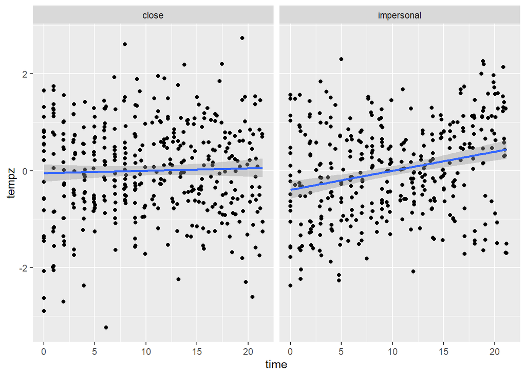

```r
ggplot(dat |> filter(ROI=="Cheeks"), aes(time, tempz))+
  geom_point()+
  geom_smooth(method="lm")+
  facet_wrap(~condition)
```

```r
summary(m0 <- lmer(tempz ~ time + (1+time|speaker), dat |> filter(ROI=="Cheeks")))
```

```
## boundary (singular) fit: see help('isSingular')
```

```
## Linear mixed model fit by REML. t-tests use Satterthwaite's method [
## lmerModLmerTest]
## Formula: tempz ~ time + (1 + time | speaker)
##    Data: filter(dat, ROI == "Cheeks")
##
## REML criterion at convergence: 1945.8
##
## Scaled residuals:
##     Min      1Q  Median      3Q     Max
## -4.1172 -0.6303 -0.0042  0.5944  3.0598
##
## Random effects:
##  Groups   Name        Variance Std.Dev. Corr
##  speaker  (Intercept) 0.805221 0.89734
##           time        0.007509 0.08666  -1.00
##  Residual             0.625651 0.79098
## Number of obs: 779, groups:  speaker, 38
##
## Fixed effects:
##             Estimate Std. Error       df t value Pr(>|t|)
## (Intercept) -0.21715    0.15506 37.38829   -1.40    0.170
## time         0.02053    0.01477 37.41819    1.39    0.173
##
## Correlation of Fixed Effects:
##      (Intr)
## time -0.982
## optimizer (nloptwrap) convergence code: 0 (OK)
## boundary (singular) fit: see help('isSingular')
```

```r
summary(m1 <- lmer(tempz ~ time + roomTemp + (1+time|speaker), dat |> filter(ROI=="Cheeks")))
```

```
## boundary (singular) fit: see help('isSingular')
```

```
## Linear mixed model fit by REML. t-tests use Satterthwaite's method [
## lmerModLmerTest]
## Formula: tempz ~ time + roomTemp + (1 + time | speaker)
##    Data: filter(dat, ROI == "Cheeks")
##
## REML criterion at convergence: 1952.6
##
## Scaled residuals:
##     Min      1Q  Median      3Q     Max
## -4.1133 -0.6318 -0.0028  0.5940  3.0587
##
## Random effects:
##  Groups   Name        Variance Std.Dev. Corr
##  speaker  (Intercept) 0.804767 0.89709
##           time        0.007513 0.08668  -1.00
##  Residual             0.626482 0.79151
## Number of obs: 779, groups:  speaker, 38
##
## Fixed effects:
##               Estimate Std. Error         df t value Pr(>|t|)
## (Intercept) -2.025e-01  3.749e-01  4.719e+02  -0.540    0.589
## time         2.057e-02  1.481e-02  3.765e+01   1.389    0.173
## roomTemp    -5.841e-04  1.363e-02  7.329e+02  -0.043    0.966
##
## Correlation of Fixed Effects:
##          (Intr) time
## time     -0.346
## roomTemp -0.910 -0.065
## optimizer (nloptwrap) convergence code: 0 (OK)
## boundary (singular) fit: see help('isSingular')
```

```r
summary(m2 <- lmer(tempz ~ time : condition + roomTemp + (1+time|speaker), dat |> filter(ROI=="Cheeks")))
```

```
## boundary (singular) fit: see help('isSingular')
```

```
## Linear mixed model fit by REML. t-tests use Satterthwaite's method [
## lmerModLmerTest]
## Formula: tempz ~ time:condition + roomTemp + (1 + time | speaker)
##    Data: filter(dat, ROI == "Cheeks")
##
## REML criterion at convergence: 1961.1
##
## Scaled residuals:
##     Min      1Q  Median      3Q     Max
## -4.1088 -0.6331 -0.0015  0.5942  3.0562
##
## Random effects:
##  Groups   Name        Variance Std.Dev. Corr
##  speaker  (Intercept) 0.80257  0.89586
##           time        0.00751  0.08666  -1.00
##  Residual             0.62735  0.79205
## Number of obs: 779, groups:  speaker, 38
##
## Fixed effects:
##                            Estimate Std. Error         df t value Pr(>|t|)
## (Intercept)              -1.955e-01  3.758e-01  4.746e+02  -0.520    0.603
## roomTemp                 -8.642e-04  1.367e-02  7.323e+02  -0.063    0.950
## time:conditionclose       2.052e-02  1.502e-02  3.967e+01   1.366    0.180
## time:conditionimpersonal  2.065e-02  1.511e-02  4.064e+01   1.366    0.179
##
## Correlation of Fixed Effects:
##             (Intr) romTmp tm:cndtnc
## roomTemp    -0.911
## tm:cndtncls -0.351 -0.051
## tm:cndtnmpr -0.324 -0.079  0.932
## optimizer (nloptwrap) convergence code: 0 (OK)
## boundary (singular) fit: see help('isSingular')
```

```r
anova(m0, m1)
```

```
## refitting model(s) with ML (instead of REML)
```

```
## Data: filter(dat, ROI == "Cheeks")
## Models:
## m0: tempz ~ time + (1 + time | speaker)
## m1: tempz ~ time + roomTemp + (1 + time | speaker)
##    npar  AIC    BIC  logLik deviance  Chisq Df Pr(>Chisq)
## m0    6 1946 1973.9 -966.98     1934
## m1    7 1948 1980.6 -966.98     1934 0.0019  1     0.9655
```

```r
anova(m1, m2)
```

```
## refitting model(s) with ML (instead of REML)
```

```
## Data: filter(dat, ROI == "Cheeks")
## Models:
## m1: tempz ~ time + roomTemp + (1 + time | speaker)
## m2: tempz ~ time:condition + roomTemp + (1 + time | speaker)
##    npar  AIC    BIC  logLik deviance  Chisq Df Pr(>Chisq)
## m1    7 1948 1980.6 -966.98     1934
## m2    8 1950 1987.2 -966.98     1934 0.0012  1     0.9726
```

### Temperature change – exploration of possible predictors

All the effects below are small and with the residuals not normally distributed. This is probably due to the small size of the data set. So these effects aren’t the most reliable.

#### First part of experiment (Lists)

##### Nose

No condition effect.

```r
summary(lmer(tempChangeLists ~ condition + (1|dyad), datChange |> filter(ROI=="Nose")))
```

```
## Linear mixed model fit by REML. t-tests use Satterthwaite's method [
## lmerModLmerTest]
## Formula: tempChangeLists ~ condition + (1 | dyad)
##    Data: filter(datChange, ROI == "Nose")
##
## REML criterion at convergence: 93
##
## Scaled residuals:
##     Min      1Q  Median      3Q     Max
## -3.1409 -0.1605  0.1439  0.4190  1.3672
##
## Random effects:
##  Groups   Name        Variance Std.Dev.
##  dyad     (Intercept) 0.2168   0.4656
##  Residual             0.7197   0.8484
## Number of obs: 34, groups:  dyad, 17
##
## Fixed effects:
##                     Estimate Std. Error       df t value Pr(>|t|)
## (Intercept)         -0.08846    0.25313 15.00000  -0.349    0.732
## conditionimpersonal  0.26953    0.36899 15.00000   0.730    0.476
##
## Correlation of Fixed Effects:
##             (Intr)
## cndtnmprsnl -0.686
```

No effect of perception of partner

```r
summary(lmer(tempChangeLists ~ closeness + (1|dyad), datChange |> filter(ROI=="Nose")))
```

```
## Linear mixed model fit by REML. t-tests use Satterthwaite's method [
## lmerModLmerTest]
## Formula: tempChangeLists ~ closeness + (1 | dyad)
##    Data: filter(datChange, ROI == "Nose")
##
## REML criterion at convergence: 96.3
##
## Scaled residuals:
##     Min      1Q  Median      3Q     Max
## -3.0390 -0.2054  0.2255  0.3763  1.2925
##
## Random effects:
##  Groups   Name        Variance Std.Dev.
##  dyad     (Intercept) 0.2105   0.4588
##  Residual             0.7374   0.8587
## Number of obs: 34, groups:  dyad, 17
##
## Fixed effects:
##             Estimate Std. Error       df t value Pr(>|t|)
## (Intercept)  0.12229    0.39336 30.89503   0.311    0.758
## closeness   -0.02194    0.09085 31.93493  -0.242    0.811
##
## Correlation of Fixed Effects:
##           (Intr)
## closeness -0.883
```

```r
summary(lmer(tempChangeLists ~ similarity + (1|dyad), datChange |> filter(ROI=="Nose")))
```

```
## Linear mixed model fit by REML. t-tests use Satterthwaite's method [
## lmerModLmerTest]
## Formula: tempChangeLists ~ similarity + (1 | dyad)
##    Data: filter(datChange, ROI == "Nose")
##
## REML criterion at convergence: 95.7
##
## Scaled residuals:
##    Min     1Q Median     3Q    Max
## -2.955 -0.104  0.201  0.375  1.261
##
## Random effects:
##  Groups   Name        Variance Std.Dev.
##  dyad     (Intercept) 0.2281   0.4776
##  Residual             0.7075   0.8411
## Number of obs: 34, groups:  dyad, 17
##
## Fixed effects:
##             Estimate Std. Error       df t value Pr(>|t|)
## (Intercept) -0.38262    0.53980 29.97112  -0.709    0.484
## similarity   0.07341    0.08842 27.00308   0.830    0.414
##
## Correlation of Fixed Effects:
##            (Intr)
## similarity -0.939
```

```r
summary(lmer(tempChangeLists ~ likeability + (1|dyad), datChange |> filter(ROI=="Nose")))
```

```
## Linear mixed model fit by REML. t-tests use Satterthwaite's method [
## lmerModLmerTest]
## Formula: tempChangeLists ~ likeability + (1 | dyad)
##    Data: filter(datChange, ROI == "Nose")
##
## REML criterion at convergence: 94.9
##
## Scaled residuals:
##     Min      1Q  Median      3Q     Max
## -3.0245 -0.2589  0.2905  0.4687  1.4309
##
## Random effects:
##  Groups   Name        Variance Std.Dev.
##  dyad     (Intercept) 0.1650   0.4063
##  Residual             0.7452   0.8633
## Number of obs: 34, groups:  dyad, 17
##
## Fixed effects:
##             Estimate Std. Error      df t value Pr(>|t|)
## (Intercept)   0.8494     0.8009 29.8868   1.060    0.297
## likeability  -0.1173     0.1130 28.8142  -1.038    0.308
##
## Correlation of Fixed Effects:
##             (Intr)
## likeability -0.975
```

```r
summary(lmer(tempChangeLists ~ becomeFriends + (1|dyad), datChange |> filter(ROI=="Nose")))
```

```
## Linear mixed model fit by REML. t-tests use Satterthwaite's method [
## lmerModLmerTest]
## Formula: tempChangeLists ~ becomeFriends + (1 | dyad)
##    Data: filter(datChange, ROI == "Nose")
##
## REML criterion at convergence: 95.2
##
## Scaled residuals:
##     Min      1Q  Median      3Q     Max
## -2.9792 -0.1347  0.1545  0.3615  1.4246
##
## Random effects:
##  Groups   Name        Variance Std.Dev.
##  dyad     (Intercept) 0.1251   0.3537
##  Residual             0.7764   0.8812
## Number of obs: 34, groups:  dyad, 17
##
## Fixed effects:
##               Estimate Std. Error      df t value Pr(>|t|)
## (Intercept)    -0.5661     0.5767 28.3439  -0.982    0.335
## becomeFriends   0.1013     0.0921 25.5867   1.099    0.282
##
## Correlation of Fixed Effects:
##             (Intr)
## becomeFrnds -0.954
```

Nose’s temperature change was *less positive* when the person scored higher on extraversion.

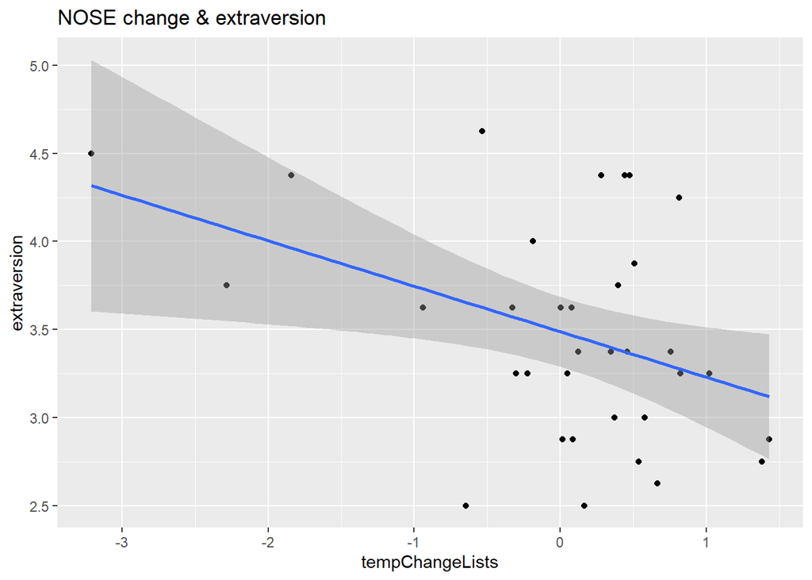

```r
ggplot(datChange |> filter(ROI=="Nose"), aes(tempChangeLists, extraversion))+
  geom_point()+
  geom_smooth(method="lm")+
  ggtitle("NOSE change & extraversion")
```

```r
summary(m <- lmer(tempChangeLists ~ extraversion + (1|dyad), datChange |> filter(ROI=="Nose")))
```

```
## Linear mixed model fit by REML. t-tests use Satterthwaite's method [
## lmerModLmerTest]
## Formula: tempChangeLists ~ extraversion + (1 | dyad)
##    Data: filter(datChange, ROI == "Nose")
##
## REML criterion at convergence: 88.7
##
## Scaled residuals:
##      Min       1Q   Median       3Q      Max
## -2.65218 -0.29847  0.09029  0.64595  1.24216
##
## Random effects:
##  Groups   Name        Variance Std.Dev.
##  dyad     (Intercept) 0.1496   0.3867
##  Residual             0.6442   0.8026
## Number of obs: 34, groups:  dyad, 17
##
## Fixed effects:
##              Estimate Std. Error      df t value Pr(>|t|)
## (Intercept)    2.1829     0.8923 31.9855   2.446   0.0201 *
## extraversion  -0.6166     0.2520 31.9931  -2.446   0.0201 *
## ---
## Signif. codes:  0 '***' 0.001 '**' 0.01 '*' 0.05 '.' 0.1 ' ' 1
##
## Correlation of Fixed Effects:
##             (Intr)
## extraversin -0.982
```

```r
par(mfrow=c(2, 2))
hist(resid(m))
qqnorm(resid(m));qqline(resid(m))
plot(fitted(m), resid(m))

summary(lmer(tempChangeLists ~ openness + (1|dyad), datChange |> filter(ROI=="Nose")))
```

```
## Linear mixed model fit by REML. t-tests use Satterthwaite's method [
## lmerModLmerTest]
## Formula: tempChangeLists ~ openness + (1 | dyad)
##    Data: filter(datChange, ROI == "Nose")
##
## REML criterion at convergence: 94
##
## Scaled residuals:
##     Min      1Q  Median      3Q     Max
## -2.8301 -0.2120  0.1950  0.4426  1.3956
##
## Random effects:
##  Groups   Name        Variance Std.Dev.
##  dyad     (Intercept) 0.2607   0.5106
##  Residual             0.6790   0.8240
## Number of obs: 34, groups:  dyad, 17
##
## Fixed effects:
##             Estimate Std. Error      df t value Pr(>|t|)
## (Intercept)   0.6868     0.6933 26.8030   0.991    0.331
## openness     -0.1811     0.1864 24.4051  -0.972    0.341
##
## Correlation of Fixed Effects:
##          (Intr)
## openness -0.963
```

```r
summary(lmer(tempChangeLists ~ agreeableness + (1|dyad), datChange |> filter(ROI=="Nose")))
```

```
## Linear mixed model fit by REML. t-tests use Satterthwaite's method [
## lmerModLmerTest]
## Formula: tempChangeLists ~ agreeableness + (1 | dyad)
##    Data: filter(datChange, ROI == "Nose")
##
## REML criterion at convergence: 92.8
##
## Scaled residuals:
##     Min      1Q  Median      3Q     Max
## -3.0770 -0.3432  0.2590  0.4626  1.2443
##
## Random effects:
##  Groups   Name        Variance Std.Dev.
##  dyad     (Intercept) 0.09298  0.3049
##  Residual             0.80804  0.8989
## Number of obs: 34, groups:  dyad, 17
##
## Fixed effects:
##               Estimate Std. Error      df t value Pr(>|t|)
## (Intercept)     1.3070     1.1875 24.9806   1.101    0.282
## agreeableness  -0.3675     0.3404 25.2503  -1.080    0.291
##
## Correlation of Fixed Effects:
##             (Intr)
## agreeablnss -0.990
```

```r
summary(lmer(tempChangeLists ~ conscientiousness + (1|dyad), datChange |> filter(ROI=="Nose")))
```

```
## Linear mixed model fit by REML. t-tests use Satterthwaite's method [
## lmerModLmerTest]
## Formula: tempChangeLists ~ conscientiousness + (1 | dyad)
##    Data: filter(datChange, ROI == "Nose")
##
## REML criterion at convergence: 93.9
##
## Scaled residuals:
##     Min      1Q  Median      3Q     Max
## -2.9801 -0.2118  0.1752  0.4401  1.2339
##
## Random effects:
##  Groups   Name        Variance Std.Dev.
##  dyad     (Intercept) 0.1977   0.4447
##  Residual             0.7433   0.8621
## Number of obs: 34, groups:  dyad, 17
##
## Fixed effects:
##                   Estimate Std. Error      df t value Pr(>|t|)
## (Intercept)         0.5294     1.1292 30.6229   0.469    0.643
## conscientiousness  -0.1225     0.2779 30.1882  -0.441    0.663
##
## Correlation of Fixed Effects:
##             (Intr)
## conscntsnss -0.987
```

```r
summary(lmer(tempChangeLists ~ neuroticism + (1|dyad), datChange |> filter(ROI=="Nose")))
```

```
## Linear mixed model fit by REML. t-tests use Satterthwaite's method [
## lmerModLmerTest]
## Formula: tempChangeLists ~ neuroticism + (1 | dyad)
##    Data: filter(datChange, ROI == "Nose")
##
## REML criterion at convergence: 94.4
##
## Scaled residuals:
##     Min      1Q  Median      3Q     Max
## -2.9859 -0.1038  0.1382  0.3688  1.3003
##
## Random effects:
##  Groups   Name        Variance Std.Dev.
##  dyad     (Intercept) 0.2214   0.4706
##  Residual             0.7248   0.8514
## Number of obs: 34, groups:  dyad, 17
##
## Fixed effects:
##             Estimate Std. Error      df t value Pr(>|t|)
## (Intercept)  -0.2820     0.7031 31.5294  -0.401    0.691
## neuroticism   0.1020     0.2160 30.6727   0.472    0.640
##
## Correlation of Fixed Effects:
##             (Intr)
## neuroticism -0.965
```

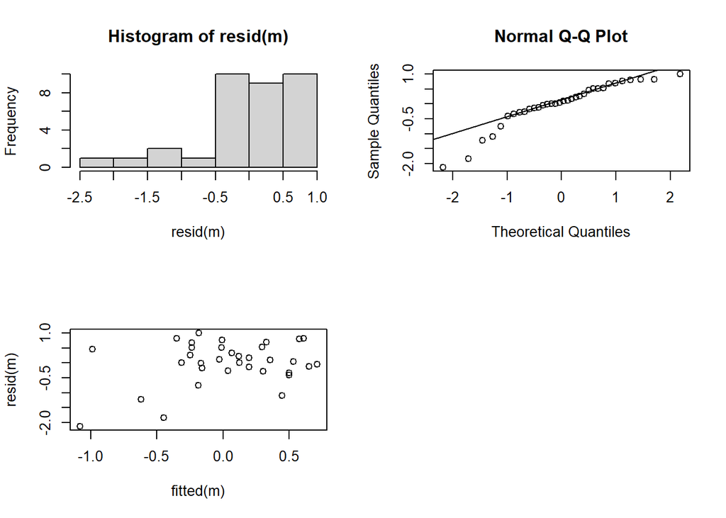

##### Eyes

No condition effect.

```r
summary(lmer(tempChangeLists ~ condition + (1|dyad), datChange |> filter(ROI=="Eyes")))
```

```
## boundary (singular) fit: see help('isSingular')
```

```
## Linear mixed model fit by REML. t-tests use Satterthwaite's method [
## lmerModLmerTest]
## Formula: tempChangeLists ~ condition + (1 | dyad)
##    Data: filter(datChange, ROI == "Eyes")
##
## REML criterion at convergence: -17.6
##
## Scaled residuals:
##      Min       1Q   Median       3Q      Max
## -2.54651 -0.66831 -0.03941  0.85396  1.85979
##
## Random effects:
##  Groups   Name        Variance Std.Dev.
##  dyad     (Intercept) 0.00000  0.0000
##  Residual             0.02503  0.1582
## Number of obs: 29, groups:  dyad, 17
##
## Fixed effects:
##                     Estimate Std. Error       df t value Pr(>|t|)
## (Intercept)          0.13519    0.03837 27.00000   3.523  0.00154 **
## conditionimpersonal  0.08534    0.05965 27.00000   1.431  0.16401
## ---
## Signif. codes:  0 '***' 0.001 '**' 0.01 '*' 0.05 '.' 0.1 ' ' 1
##
## Correlation of Fixed Effects:
##             (Intr)
## cndtnmprsnl -0.643
## optimizer (nloptwrap) convergence code: 0 (OK)
## boundary (singular) fit: see help('isSingular')
```

No effect of perception of partner.

```r
summary(lmer(tempChangeLists ~ closeness + (1|dyad), datChange |> filter(ROI=="Eyes")))
```

```
## boundary (singular) fit: see help('isSingular')
```

```
## Linear mixed model fit by REML. t-tests use Satterthwaite's method [
## lmerModLmerTest]
## Formula: tempChangeLists ~ closeness + (1 | dyad)
##    Data: filter(datChange, ROI == "Eyes")
##
## REML criterion at convergence: -14.2
##
## Scaled residuals:
##     Min      1Q  Median      3Q     Max
## -2.5921 -0.6773 -0.2103  0.6746  1.7722
##
## Random effects:
##  Groups   Name        Variance Std.Dev.
##  dyad     (Intercept) 0.00000  0.0000
##  Residual             0.02573  0.1604
## Number of obs: 29, groups:  dyad, 17
##
## Fixed effects:
##             Estimate Std. Error       df t value Pr(>|t|)
## (Intercept)  0.23844    0.06743 27.00000   3.536  0.00149 **
## closeness   -0.01808    0.01610 27.00000  -1.123  0.27128
## ---
## Signif. codes:  0 '***' 0.001 '**' 0.01 '*' 0.05 '.' 0.1 ' ' 1
##
## Correlation of Fixed Effects:
##           (Intr)
## closeness -0.897
## optimizer (nloptwrap) convergence code: 0 (OK)
## boundary (singular) fit: see help('isSingular')
```

```r
summary(lmer(tempChangeLists ~ similarity + (1|dyad), datChange |> filter(ROI=="Eyes")))
```

```
## boundary (singular) fit: see help('isSingular')
```

```
## Linear mixed model fit by REML. t-tests use Satterthwaite's method [
## lmerModLmerTest]
## Formula: tempChangeLists ~ similarity + (1 | dyad)
##    Data: filter(datChange, ROI == "Eyes")
##
## REML criterion at convergence: -14.1
##
## Scaled residuals:
##     Min      1Q  Median      3Q     Max
## -2.5000 -0.6858 -0.1748  0.8673  1.7563
##
## Random effects:
##  Groups   Name        Variance Std.Dev.
##  dyad     (Intercept) 0.00000  0.000
##  Residual             0.02592  0.161
## Number of obs: 29, groups:  dyad, 17
##
## Fixed effects:
##             Estimate Std. Error       df t value Pr(>|t|)
## (Intercept)  0.27069    0.10203 27.00000   2.653   0.0132 *
## similarity  -0.01699    0.01654 27.00000  -1.027   0.3135
## ---
## Signif. codes:  0 '***' 0.001 '**' 0.01 '*' 0.05 '.' 0.1 ' ' 1
##
## Correlation of Fixed Effects:
##            (Intr)
## similarity -0.956
## optimizer (nloptwrap) convergence code: 0 (OK)
## boundary (singular) fit: see help('isSingular')
```

```r
summary(lmer(tempChangeLists ~ likeability + (1|dyad), datChange |> filter(ROI=="Eyes")))
```

```
## boundary (singular) fit: see help('isSingular')
```

```
## Linear mixed model fit by REML. t-tests use Satterthwaite's method [
## lmerModLmerTest]
## Formula: tempChangeLists ~ likeability + (1 | dyad)
##    Data: filter(datChange, ROI == "Eyes")
##
## REML criterion at convergence: -14.5
##
## Scaled residuals:
##     Min      1Q  Median      3Q     Max
## -2.5804 -0.6121 -0.1807  0.8812  1.9777
##
## Random effects:
##  Groups   Name        Variance Std.Dev.
##  dyad     (Intercept) 0.00000  0.0000
##  Residual             0.02609  0.1615
## Number of obs: 29, groups:  dyad, 17
##
## Fixed effects:
##             Estimate Std. Error       df t value Pr(>|t|)
## (Intercept)  0.31493    0.15746 27.00000   2.000   0.0557 .
## likeability -0.02073    0.02219 27.00000  -0.934   0.3584
## ---
## Signif. codes:  0 '***' 0.001 '**' 0.01 '*' 0.05 '.' 0.1 ' ' 1
##
## Correlation of Fixed Effects:
##             (Intr)
## likeability -0.982
## optimizer (nloptwrap) convergence code: 0 (OK)
## boundary (singular) fit: see help('isSingular')
```

```r
summary(lmer(tempChangeLists ~ becomeFriends + (1|dyad), datChange |> filter(ROI=="Eyes")))
```

```
## boundary (singular) fit: see help('isSingular')
```

```
## Linear mixed model fit by REML. t-tests use Satterthwaite's method [
## lmerModLmerTest]
## Formula: tempChangeLists ~ becomeFriends + (1 | dyad)
##    Data: filter(datChange, ROI == "Eyes")
##
## REML criterion at convergence: -14
##
## Scaled residuals:
##      Min       1Q   Median       3Q      Max
## -2.71364 -0.68486 -0.09687  0.73567  1.65354
##
## Random effects:
##  Groups   Name        Variance Std.Dev.
##  dyad     (Intercept) 0.00000  0.0000
##  Residual             0.02627  0.1621
## Number of obs: 29, groups:  dyad, 17
##
## Fixed effects:
##               Estimate Std. Error       df t value Pr(>|t|)
## (Intercept)    0.26718    0.12145 27.00000   2.200   0.0366 *
## becomeFriends -0.01584    0.01928 27.00000  -0.822   0.4185
## ---
## Signif. codes:  0 '***' 0.001 '**' 0.01 '*' 0.05 '.' 0.1 ' ' 1
##
## Correlation of Fixed Effects:
##             (Intr)
## becomeFrnds -0.969
## optimizer (nloptwrap) convergence code: 0 (OK)
## boundary (singular) fit: see help('isSingular')
```

No effect of BFI scores.

```r
summary(lmer(tempChangeLists ~ extraversion + (1|dyad), datChange |> filter(ROI=="Eyes")))
```

```
## boundary (singular) fit: see help('isSingular')
```

```
## Linear mixed model fit by REML. t-tests use Satterthwaite's method [
## lmerModLmerTest]
## Formula: tempChangeLists ~ extraversion + (1 | dyad)
##    Data: filter(datChange, ROI == "Eyes")
##
## REML criterion at convergence: -16.8
##
## Scaled residuals:
##      Min       1Q   Median       3Q      Max
## -2.85095 -0.62427 -0.01982  0.64797  1.93555
##
## Random effects:
##  Groups   Name        Variance Std.Dev.
##  dyad     (Intercept) 0.00000  0.000
##  Residual             0.02528  0.159
## Number of obs: 29, groups:  dyad, 17
##
## Fixed effects:
##              Estimate Std. Error       df t value Pr(>|t|)
## (Intercept)  -0.04437    0.16446 27.00000  -0.270    0.789
## extraversion  0.06132    0.04617 27.00000   1.328    0.195
##
## Correlation of Fixed Effects:
##             (Intr)
## extraversin -0.984
## optimizer (nloptwrap) convergence code: 0 (OK)
## boundary (singular) fit: see help('isSingular')
```

```r
summary(lmer(tempChangeLists ~ openness + (1|dyad), datChange |> filter(ROI=="Eyes")))
```

```
## boundary (singular) fit: see help('isSingular')
```

```
## Linear mixed model fit by REML. t-tests use Satterthwaite's method [
## lmerModLmerTest]
## Formula: tempChangeLists ~ openness + (1 | dyad)
##    Data: filter(datChange, ROI == "Eyes")
##
## REML criterion at convergence: -15.4
##
## Scaled residuals:
##     Min      1Q  Median      3Q     Max
## -2.7165 -0.7325 -0.0259  0.5793  1.9695
##
## Random effects:
##  Groups   Name        Variance Std.Dev.
##  dyad     (Intercept) 0.00000  0.0000
##  Residual             0.02613  0.1616
## Number of obs: 29, groups:  dyad, 17
##
## Fixed effects:
##             Estimate Std. Error       df t value Pr(>|t|)
## (Intercept)  0.28328    0.12771 27.00000   2.218   0.0351 *
## openness    -0.03196    0.03518 27.00000  -0.909   0.3716
## ---
## Signif. codes:  0 '***' 0.001 '**' 0.01 '*' 0.05 '.' 0.1 ' ' 1
##
## Correlation of Fixed Effects:
##          (Intr)
## openness -0.972
## optimizer (nloptwrap) convergence code: 0 (OK)
## boundary (singular) fit: see help('isSingular')
```

```r
summary(lmer(tempChangeLists ~ agreeableness + (1|dyad), datChange |> filter(ROI=="Eyes")))
```

```
## boundary (singular) fit: see help('isSingular')
```

```
## Linear mixed model fit by REML. t-tests use Satterthwaite's method [
## lmerModLmerTest]
## Formula: tempChangeLists ~ agreeableness + (1 | dyad)
##    Data: filter(datChange, ROI == "Eyes")
##
## REML criterion at convergence: -16.2
##
## Scaled residuals:
##      Min       1Q   Median       3Q      Max
## -2.61245 -0.52764 -0.03984  0.66839  1.80000
##
## Random effects:
##  Groups   Name        Variance Std.Dev.
##  dyad     (Intercept) 0.00000  0.0000
##  Residual             0.02645  0.1626
## Number of obs: 29, groups:  dyad, 17
##
## Fixed effects:
##               Estimate Std. Error       df t value Pr(>|t|)
## (Intercept)    0.01664    0.22125 27.00000   0.075    0.941
## agreeableness  0.04471    0.06368 27.00000   0.702    0.489
##
## Correlation of Fixed Effects:
##             (Intr)
## agreeablnss -0.991
## optimizer (nloptwrap) convergence code: 0 (OK)
## boundary (singular) fit: see help('isSingular')
```

```r
summary(lmer(tempChangeLists ~ conscientiousness + (1|dyad), datChange |> filter(ROI=="Eyes")))
```

```
## boundary (singular) fit: see help('isSingular')
```

```
## Linear mixed model fit by REML. t-tests use Satterthwaite's method [
## lmerModLmerTest]
## Formula: tempChangeLists ~ conscientiousness + (1 | dyad)
##    Data: filter(datChange, ROI == "Eyes")
##
## REML criterion at convergence: -15.4
##
## Scaled residuals:
##      Min       1Q   Median       3Q      Max
## -2.70135 -0.60779 -0.08242  0.69272  1.77290
##
## Random effects:
##  Groups   Name        Variance Std.Dev.
##  dyad     (Intercept) 0.00000  0.0000
##  Residual             0.02688  0.1639
## Number of obs: 29, groups:  dyad, 17
##
## Fixed effects:
##                   Estimate Std. Error       df t value Pr(>|t|)
## (Intercept)        0.12382    0.21095 27.00000   0.587    0.562
## conscientiousness  0.01185    0.05300 27.00000   0.224    0.825
##
## Correlation of Fixed Effects:
##             (Intr)
## conscntsnss -0.990
## optimizer (nloptwrap) convergence code: 0 (OK)
## boundary (singular) fit: see help('isSingular')
```

```r
summary(lmer(tempChangeLists ~ neuroticism + (1|dyad), datChange |> filter(ROI=="Eyes")))
```

```
## boundary (singular) fit: see help('isSingular')
```

```
## Linear mixed model fit by REML. t-tests use Satterthwaite's method [
## lmerModLmerTest]
## Formula: tempChangeLists ~ neuroticism + (1 | dyad)
##    Data: filter(datChange, ROI == "Eyes")
##
## REML criterion at convergence: -15.5
##
## Scaled residuals:
##     Min      1Q  Median      3Q     Max
## -2.5656 -0.6005 -0.0917  0.8251  1.8425
##
## Random effects:
##  Groups   Name        Variance Std.Dev.
##  dyad     (Intercept) 0.00000  0.0000
##  Residual             0.02644  0.1626
## Number of obs: 29, groups:  dyad, 17
##
## Fixed effects:
##             Estimate Std. Error       df t value Pr(>|t|)
## (Intercept)  0.26611    0.13832 27.00000   1.924    0.065 .
## neuroticism -0.03111    0.04392 27.00000  -0.708    0.485
## ---
## Signif. codes:  0 '***' 0.001 '**' 0.01 '*' 0.05 '.' 0.1 ' ' 1
##
## Correlation of Fixed Effects:
##             (Intr)
## neuroticism -0.976
## optimizer (nloptwrap) convergence code: 0 (OK)
## boundary (singular) fit: see help('isSingular')
```

##### Forehead

No effect of condition.

```r
summary(m <- lmer(tempChangeLists ~ condition + (1|dyad), datChange |> filter(ROI=="Forehead")))
```

```
## boundary (singular) fit: see help('isSingular')
```

```
## Linear mixed model fit by REML. t-tests use Satterthwaite's method [
## lmerModLmerTest]
## Formula: tempChangeLists ~ condition + (1 | dyad)
##    Data: filter(datChange, ROI == "Forehead")
##
## REML criterion at convergence: -10.2
##
## Scaled residuals:
##      Min       1Q   Median       3Q      Max
## -2.62538 -0.56733 -0.00747  0.48745  3.09698
##
## Random effects:
##  Groups   Name        Variance Std.Dev.
##  dyad     (Intercept) 0.00000  0.0000
##  Residual             0.03565  0.1888
## Number of obs: 34, groups:  dyad, 17
##
## Fixed effects:
##                     Estimate Std. Error       df t value Pr(>|t|)
## (Intercept)          0.17192    0.04450 32.00000   3.863 0.000514 ***
## conditionimpersonal  0.02631    0.06487 32.00000   0.406 0.687808
## ---
## Signif. codes:  0 '***' 0.001 '**' 0.01 '*' 0.05 '.' 0.1 ' ' 1
##
## Correlation of Fixed Effects:
##             (Intr)
## cndtnmprsnl -0.686
## optimizer (nloptwrap) convergence code: 0 (OK)
## boundary (singular) fit: see help('isSingular')
```

No effect of perception of partner.

```r
summary(lmer(tempChangeLists ~ likeability + (1|dyad), datChange |> filter(ROI=="Forehead")))
```

```
## boundary (singular) fit: see help('isSingular')
```

```
## Linear mixed model fit by REML. t-tests use Satterthwaite's method [
## lmerModLmerTest]
## Formula: tempChangeLists ~ likeability + (1 | dyad)
##    Data: filter(datChange, ROI == "Forehead")
##
## REML criterion at convergence: -11.5
##
## Scaled residuals:
##      Min       1Q   Median       3Q      Max
## -2.57907 -0.54386  0.02468  0.47278  2.50514
##
## Random effects:
##  Groups   Name        Variance Std.Dev.
##  dyad     (Intercept) 0.00000  0.0000
##  Residual             0.03206  0.1791
## Number of obs: 34, groups:  dyad, 17
##
## Fixed effects:
##             Estimate Std. Error       df t value Pr(>|t|)
## (Intercept)  0.47814    0.15458 32.00000   3.093  0.00409 **
## likeability -0.04251    0.02192 32.00000  -1.939  0.06130 .
## ---
## Signif. codes:  0 '***' 0.001 '**' 0.01 '*' 0.05 '.' 0.1 ' ' 1
##
## Correlation of Fixed Effects:
##             (Intr)
## likeability -0.980
## optimizer (nloptwrap) convergence code: 0 (OK)
## boundary (singular) fit: see help('isSingular')
```

```r
summary(lmer(tempChangeLists ~ closeness + (1|dyad), datChange |> filter(ROI=="Forehead")))
```

```
## boundary (singular) fit: see help('isSingular')
```

```
## Linear mixed model fit by REML. t-tests use Satterthwaite's method [
## lmerModLmerTest]
## Formula: tempChangeLists ~ closeness + (1 | dyad)
##    Data: filter(datChange, ROI == "Forehead")
##
## REML criterion at convergence: -7.7
##
## Scaled residuals:
##     Min      1Q  Median      3Q     Max
## -2.7289 -0.4565  0.1106  0.5171  2.9979
##
## Random effects:
##  Groups   Name        Variance Std.Dev.
##  dyad     (Intercept) 0.00000  0.0000
##  Residual             0.03559  0.1887
## Number of obs: 34, groups:  dyad, 17
##
## Fixed effects:
##              Estimate Std. Error        df t value Pr(>|t|)
## (Intercept)  0.215746   0.075195 32.000000   2.869  0.00723 **
## closeness   -0.008223   0.017753 32.000000  -0.463  0.64635
## ---
## Signif. codes:  0 '***' 0.001 '**' 0.01 '*' 0.05 '.' 0.1 ' ' 1
##
## Correlation of Fixed Effects:
##           (Intr)
## closeness -0.903
## optimizer (nloptwrap) convergence code: 0 (OK)
## boundary (singular) fit: see help('isSingular')
```

```r
summary(lmer(tempChangeLists ~ similarity + (1|dyad), datChange |> filter(ROI=="Forehead")))
```

```
## boundary (singular) fit: see help('isSingular')
```

```
## Linear mixed model fit by REML. t-tests use Satterthwaite's method [
## lmerModLmerTest]
## Formula: tempChangeLists ~ similarity + (1 | dyad)
##    Data: filter(datChange, ROI == "Forehead")
##
## REML criterion at convergence: -8.1
##
## Scaled residuals:
##     Min      1Q  Median      3Q     Max
## -2.6135 -0.5029  0.0609  0.5344  2.8443
##
## Random effects:
##  Groups   Name        Variance Std.Dev.
##  dyad     (Intercept) 0.00000  0.0000
##  Residual             0.03515  0.1875
## Number of obs: 34, groups:  dyad, 17
##
## Fixed effects:
##             Estimate Std. Error       df t value Pr(>|t|)
## (Intercept)  0.26625    0.10899 32.00000   2.443   0.0203 *
## similarity  -0.01429    0.01816 32.00000  -0.787   0.4372
## ---
## Signif. codes:  0 '***' 0.001 '**' 0.01 '*' 0.05 '.' 0.1 ' ' 1
##
## Correlation of Fixed Effects:
##            (Intr)
## similarity -0.955
## optimizer (nloptwrap) convergence code: 0 (OK)
## boundary (singular) fit: see help('isSingular')
```

```r
summary(lmer(tempChangeLists ~ becomeFriends + (1|dyad), datChange |> filter(ROI=="Forehead")))
```

```
## boundary (singular) fit: see help('isSingular')
```

```
## Linear mixed model fit by REML. t-tests use Satterthwaite's method [
## lmerModLmerTest]
## Formula: tempChangeLists ~ becomeFriends + (1 | dyad)
##    Data: filter(datChange, ROI == "Forehead")
##
## REML criterion at convergence: -11.1
##
## Scaled residuals:
##      Min       1Q   Median       3Q      Max
## -2.63572 -0.61473  0.05593  0.65674  2.61990
##
## Random effects:
##  Groups   Name        Variance Std.Dev.
##  dyad     (Intercept) 0.00000  0.0000
##  Residual             0.03213  0.1793
## Number of obs: 34, groups:  dyad, 17
##
## Fixed effects:
##               Estimate Std. Error       df t value Pr(>|t|)
## (Intercept)    0.39075    0.11189 32.00000   3.492  0.00142 **
## becomeFriends -0.03458    0.01802 32.00000  -1.919  0.06395 .
## ---
## Signif. codes:  0 '***' 0.001 '**' 0.01 '*' 0.05 '.' 0.1 ' ' 1
##
## Correlation of Fixed Effects:
##             (Intr)
## becomeFrnds -0.962
## optimizer (nloptwrap) convergence code: 0 (OK)
## boundary (singular) fit: see help('isSingular')
```

People changed their forehead temperature *more positively* when they scored *higher* in *agreeableness*.

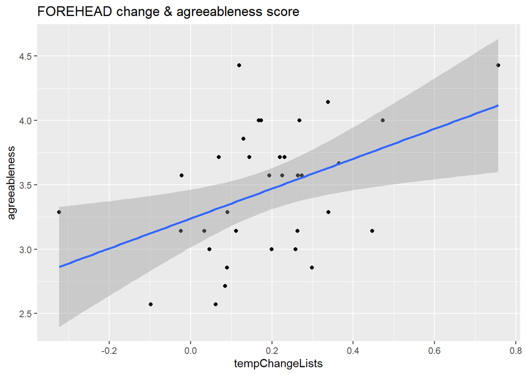

```r
ggplot(datChange |> filter(ROI=="Forehead"), aes(tempChangeLists, agreeableness))+
  geom_point()+
  geom_smooth(method="lm")+
  ggtitle("FOREHEAD change & agreeableness score")
```

```r
summary(m <- lmer(tempChangeLists ~ agreeableness + (1|dyad), datChange |> filter(ROI=="Forehead")))
```

```
## boundary (singular) fit: see help('isSingular')
```

```
## Linear mixed model fit by REML. t-tests use Satterthwaite's method [
## lmerModLmerTest]
## Formula: tempChangeLists ~ agreeableness + (1 | dyad)
##    Data: filter(datChange, ROI == "Forehead")
##
## REML criterion at convergence: -16.8
##
## Scaled residuals:
##      Min       1Q   Median       3Q      Max
## -2.82248 -0.59121 -0.01042  0.49355  2.42066
##
## Random effects:
##  Groups   Name        Variance Std.Dev.
##  dyad     (Intercept) 0.00000  0.0000
##  Residual             0.02901  0.1703
## Number of obs: 34, groups:  dyad, 17
##
## Fixed effects:
##               Estimate Std. Error       df t value Pr(>|t|)
## (Intercept)   -0.38173    0.20843 32.00000  -1.831   0.0764 .
## agreeableness  0.16396    0.05978 32.00000   2.743   0.0099 **
## ---
## Signif. codes:  0 '***' 0.001 '**' 0.01 '*' 0.05 '.' 0.1 ' ' 1
##
## Correlation of Fixed Effects:
##             (Intr)
## agreeablnss -0.990
## optimizer (nloptwrap) convergence code: 0 (OK)
## boundary (singular) fit: see help('isSingular')
```

```r
par(mfrow=c(2, 2))
hist(resid(m))
qqnorm(resid(m));qqline(resid(m))
plot(fitted(m), resid(m))

summary(lmer(tempChangeLists ~ extraversion + (1|dyad), datChange |> filter(ROI=="Forehead")))
```

```
## boundary (singular) fit: see help('isSingular')
```

```
## Linear mixed model fit by REML. t-tests use Satterthwaite's method [
## lmerModLmerTest]
## Formula: tempChangeLists ~ extraversion + (1 | dyad)
##    Data: filter(datChange, ROI == "Forehead")
##
## REML criterion at convergence: -9.7
##
## Scaled residuals:
##     Min      1Q  Median      3Q     Max
## -2.6758 -0.5167  0.0034  0.4374  3.0141
##
## Random effects:
##  Groups   Name        Variance Std.Dev.
##  dyad     (Intercept) 0.00000  0.0000
##  Residual             0.03583  0.1893
## Number of obs: 34, groups:  dyad, 17
##
## Fixed effects:
##               Estimate Std. Error        df t value Pr(>|t|)
## (Intercept)   0.194909   0.189825 32.000000   1.027    0.312
## extraversion -0.003049   0.053776 32.000000  -0.057    0.955
##
## Correlation of Fixed Effects:
##             (Intr)
## extraversin -0.985
## optimizer (nloptwrap) convergence code: 0 (OK)
## boundary (singular) fit: see help('isSingular')
```

```r
summary(lmer(tempChangeLists ~ openness + (1|dyad), datChange |> filter(ROI=="Forehead")))
```

```
## boundary (singular) fit: see help('isSingular')
```

```
## Linear mixed model fit by REML. t-tests use Satterthwaite's method [
## lmerModLmerTest]
## Formula: tempChangeLists ~ openness + (1 | dyad)
##    Data: filter(datChange, ROI == "Forehead")
##
## REML criterion at convergence: -11.1
##
## Scaled residuals:
##      Min       1Q   Median       3Q      Max
## -2.43973 -0.56865  0.03343  0.37087  3.06827
##
## Random effects:
##  Groups   Name        Variance Std.Dev.
##  dyad     (Intercept) 0.00000  0.0000
##  Residual             0.03358  0.1832
## Number of obs: 34, groups:  dyad, 17
##
## Fixed effects:
##             Estimate Std. Error       df t value Pr(>|t|)
## (Intercept)  0.38543    0.14073 32.00000   2.739  0.00999 **
## openness    -0.05618    0.03831 32.00000  -1.466  0.15235
## ---
## Signif. codes:  0 '***' 0.001 '**' 0.01 '*' 0.05 '.' 0.1 ' ' 1
##
## Correlation of Fixed Effects:
##          (Intr)
## openness -0.975
## optimizer (nloptwrap) convergence code: 0 (OK)
## boundary (singular) fit: see help('isSingular')
```

```r
summary(lmer(tempChangeLists ~ conscientiousness + (1|dyad), datChange |> filter(ROI=="Forehead")))
```

```
## boundary (singular) fit: see help('isSingular')
```

```
## Linear mixed model fit by REML. t-tests use Satterthwaite's method [
## lmerModLmerTest]
## Formula: tempChangeLists ~ conscientiousness + (1 | dyad)
##    Data: filter(datChange, ROI == "Forehead")
##
## REML criterion at convergence: -10
##
## Scaled residuals:
##      Min       1Q   Median       3Q      Max
## -2.61572 -0.54172 -0.02407  0.43965  2.98561
##
## Random effects:
##  Groups   Name        Variance Std.Dev.
##  dyad     (Intercept) 0.00000  0.0000
##  Residual             0.03557  0.1886
## Number of obs: 34, groups:  dyad, 17
##
## Fixed effects:
##                   Estimate Std. Error       df t value Pr(>|t|)
## (Intercept)        0.29269    0.22543 32.00000   1.298    0.203
## conscientiousness -0.02703    0.05564 32.00000  -0.486    0.630
##
## Correlation of Fixed Effects:
##             (Intr)
## conscntsnss -0.990
## optimizer (nloptwrap) convergence code: 0 (OK)
## boundary (singular) fit: see help('isSingular')
```

```r
summary(lmer(tempChangeLists ~ neuroticism + (1|dyad), datChange |> filter(ROI=="Forehead")))
```

```
## boundary (singular) fit: see help('isSingular')
```

```
## Linear mixed model fit by REML. t-tests use Satterthwaite's method [
## lmerModLmerTest]
## Formula: tempChangeLists ~ neuroticism + (1 | dyad)
##    Data: filter(datChange, ROI == "Forehead")
##
## REML criterion at convergence: -10.3
##
## Scaled residuals:
##      Min       1Q   Median       3Q      Max
## -2.66610 -0.62736  0.09912  0.56235  2.87038
##
## Random effects:
##  Groups   Name        Variance Std.Dev.
##  dyad     (Intercept) 0.00000  0.0000
##  Residual             0.03467  0.1862
## Number of obs: 34, groups:  dyad, 17
##
## Fixed effects:
##             Estimate Std. Error       df t value Pr(>|t|)
## (Intercept)  0.04593    0.13725 32.00000   0.335    0.740
## neuroticism  0.04407    0.04251 32.00000   1.037    0.308
##
## Correlation of Fixed Effects:
##             (Intr)
## neuroticism -0.973
## optimizer (nloptwrap) convergence code: 0 (OK)
## boundary (singular) fit: see help('isSingular')
```

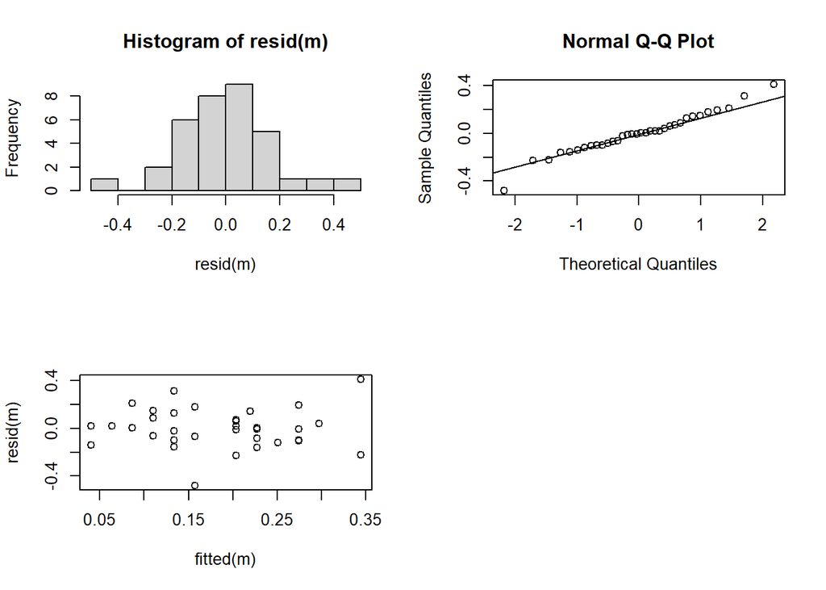

##### Cheeks

No effect of condition.

```r
summary(lmer(tempChangeLists ~ condition + (1|dyad), datChange |> filter(ROI=="Cheeks")))
```

```
## Linear mixed model fit by REML. t-tests use Satterthwaite's method [
## lmerModLmerTest]
## Formula: tempChangeLists ~ condition + (1 | dyad)
##    Data: filter(datChange, ROI == "Cheeks")
##
## REML criterion at convergence: 14.4
##
## Scaled residuals:
##      Min       1Q   Median       3Q      Max
## -1.61742 -0.49307  0.01406  0.47294  2.38451
##
## Random effects:
##  Groups   Name        Variance Std.Dev.
##  dyad     (Intercept) 0.03491  0.1868
##  Residual             0.05138  0.2267
## Number of obs: 34, groups:  dyad, 17
##
## Fixed effects:
##                     Estimate Std. Error       df t value Pr(>|t|)
## (Intercept)          0.03043    0.08206 15.00000   0.371    0.716
## conditionimpersonal -0.02752    0.11962 15.00000  -0.230    0.821
##
## Correlation of Fixed Effects:
##             (Intr)
## cndtnmprsnl -0.686
```

No effect of perception of partner.

```r
summary(lmer(tempChangeLists ~ likeability + (1|dyad), datChange |> filter(ROI=="Cheeks")))
```

```
## Linear mixed model fit by REML. t-tests use Satterthwaite's method [
## lmerModLmerTest]
## Formula: tempChangeLists ~ likeability + (1 | dyad)
##    Data: filter(datChange, ROI == "Cheeks")
##
## REML criterion at convergence: 15.3
##
## Scaled residuals:
##      Min       1Q   Median       3Q      Max
## -1.72369 -0.47712 -0.04392  0.42898  2.28365
##
## Random effects:
##  Groups   Name        Variance Std.Dev.
##  dyad     (Intercept) 0.02787  0.1670
##  Residual             0.05195  0.2279
## Number of obs: 34, groups:  dyad, 17
##
## Fixed effects:
##             Estimate Std. Error       df t value Pr(>|t|)
## (Intercept)  0.30513    0.22431 27.77221   1.360    0.185
## likeability -0.04162    0.03141 25.91618  -1.325    0.197
##
## Correlation of Fixed Effects:
##             (Intr)
## likeability -0.968
```

```r
summary(lmer(tempChangeLists ~ closeness + (1|dyad), datChange |> filter(ROI=="Cheeks")))
```

```
## Linear mixed model fit by REML. t-tests use Satterthwaite's method [
## lmerModLmerTest]
## Formula: tempChangeLists ~ closeness + (1 | dyad)
##    Data: filter(datChange, ROI == "Cheeks")
##
## REML criterion at convergence: 17.4
##
## Scaled residuals:
##      Min       1Q   Median       3Q      Max
## -1.71958 -0.49212  0.02446  0.46784  2.40191
##
## Random effects:
##  Groups   Name        Variance Std.Dev.
##  dyad     (Intercept) 0.03132  0.1770
##  Residual             0.05354  0.2314
## Number of obs: 34, groups:  dyad, 17
##
## Fixed effects:
##              Estimate Std. Error        df t value Pr(>|t|)
## (Intercept)  0.003292   0.116018 31.655153   0.028    0.978
## closeness    0.003711   0.026211 30.684737   0.142    0.888
##
## Correlation of Fixed Effects:
##           (Intr)
## closeness -0.864
```

```r
summary(lmer(tempChangeLists ~ similarity + (1|dyad), datChange |> filter(ROI=="Cheeks")))
```

```
## Linear mixed model fit by REML. t-tests use Satterthwaite's method [
## lmerModLmerTest]
## Formula: tempChangeLists ~ similarity + (1 | dyad)
##    Data: filter(datChange, ROI == "Cheeks")
##
## REML criterion at convergence: 17.2
##
## Scaled residuals:
##      Min       1Q   Median       3Q      Max
## -1.63781 -0.51571  0.06904  0.37357  2.29419
##
## Random effects:
##  Groups   Name        Variance Std.Dev.
##  dyad     (Intercept) 0.03209  0.1791
##  Residual             0.05236  0.2288
## Number of obs: 34, groups:  dyad, 17
##
## Fixed effects:
##             Estimate Std. Error       df t value Pr(>|t|)
## (Intercept)  0.10057    0.15472 29.01618    0.65    0.521
## similarity  -0.01449    0.02497 24.72306   -0.58    0.567
##
## Correlation of Fixed Effects:
##            (Intr)
## similarity -0.926
```

```r
summary(lmer(tempChangeLists ~ becomeFriends + (1|dyad), datChange |> filter(ROI=="Cheeks")))
```

```
## Linear mixed model fit by REML. t-tests use Satterthwaite's method [
## lmerModLmerTest]
## Formula: tempChangeLists ~ becomeFriends + (1 | dyad)
##    Data: filter(datChange, ROI == "Cheeks")
##
## REML criterion at convergence: 17.4
##
## Scaled residuals:
##      Min       1Q   Median       3Q      Max
## -1.70046 -0.43640  0.04304  0.45402  2.34104
##
## Random effects:
##  Groups   Name        Variance Std.Dev.
##  dyad     (Intercept) 0.03094  0.1759
##  Residual             0.05368  0.2317
## Number of obs: 34, groups:  dyad, 17
##
## Fixed effects:
##                Estimate Std. Error        df t value Pr(>|t|)
## (Intercept)    0.054567   0.162944 26.979164   0.335     0.74
## becomeFriends -0.006212   0.025485 22.660510  -0.244     0.81
##
## Correlation of Fixed Effects:
##             (Intr)
## becomeFrnds -0.934
```

No effects of BFI scores.

```r
summary(lmer(tempChangeLists ~ agreeableness + (1|dyad), datChange |> filter(ROI=="Cheeks")))
```

```
## Linear mixed model fit by REML. t-tests use Satterthwaite's method [
## lmerModLmerTest]
## Formula: tempChangeLists ~ agreeableness + (1 | dyad)
##    Data: filter(datChange, ROI == "Cheeks")
##
## REML criterion at convergence: 14.5
##
## Scaled residuals:
##      Min       1Q   Median       3Q      Max
## -1.68878 -0.53931  0.05675  0.45513  2.45335
##
## Random effects:
##  Groups   Name        Variance Std.Dev.
##  dyad     (Intercept) 0.02802  0.1674
##  Residual             0.05525  0.2351
## Number of obs: 34, groups:  dyad, 17
##
## Fixed effects:
##               Estimate Std. Error       df t value Pr(>|t|)
## (Intercept)    0.17985    0.36603 29.43247   0.491    0.627
## agreeableness -0.04703    0.10472 29.77230  -0.449    0.657
##
## Correlation of Fixed Effects:
##             (Intr)
## agreeablnss -0.988
```

```r
summary(lmer(tempChangeLists ~ extraversion + (1|dyad), datChange |> filter(ROI=="Cheeks")))
```

```
## Linear mixed model fit by REML. t-tests use Satterthwaite's method [
## lmerModLmerTest]
## Formula: tempChangeLists ~ extraversion + (1 | dyad)
##    Data: filter(datChange, ROI == "Cheeks")
##
## REML criterion at convergence: 15.2
##
## Scaled residuals:
##      Min       1Q   Median       3Q      Max
## -1.76740 -0.52099  0.04978  0.45938  2.46679
##
## Random effects:
##  Groups   Name        Variance Std.Dev.
##  dyad     (Intercept) 0.03118  0.1766
##  Residual             0.05352  0.2313
## Number of obs: 34, groups:  dyad, 17
##
## Fixed effects:
##              Estimate Std. Error       df t value Pr(>|t|)
## (Intercept)   0.08734    0.28093 31.23001   0.311    0.758
## extraversion -0.02009    0.07901 30.64980  -0.254    0.801
##
## Correlation of Fixed Effects:
##             (Intr)
## extraversin -0.978
```

```r
summary(lmer(tempChangeLists ~ openness + (1|dyad), datChange |> filter(ROI=="Cheeks")))
```

```
## Linear mixed model fit by REML. t-tests use Satterthwaite's method [
## lmerModLmerTest]
## Formula: tempChangeLists ~ openness + (1 | dyad)
##    Data: filter(datChange, ROI == "Cheeks")
##
## REML criterion at convergence: 15.9
##
## Scaled residuals:
##      Min       1Q   Median       3Q      Max
## -1.80495 -0.46358  0.07251  0.46994  2.37551
##
## Random effects:
##  Groups   Name        Variance Std.Dev.
##  dyad     (Intercept) 0.03108  0.1763
##  Residual             0.05356  0.2314
## Number of obs: 34, groups:  dyad, 17
##
## Fixed effects:
##             Estimate Std. Error       df t value Pr(>|t|)
## (Intercept)  0.06868    0.20002 26.24052   0.343    0.734
## openness    -0.01430    0.05344 23.41697  -0.268    0.791
##
## Correlation of Fixed Effects:
##          (Intr)
## openness -0.957
```

```r
summary(lmer(tempChangeLists ~ conscientiousness + (1|dyad), datChange |> filter(ROI=="Cheeks")))
```

```
## Linear mixed model fit by REML. t-tests use Satterthwaite's method [
## lmerModLmerTest]
## Formula: tempChangeLists ~ conscientiousness + (1 | dyad)
##    Data: filter(datChange, ROI == "Cheeks")
##
## REML criterion at convergence: 15.2
##
## Scaled residuals:
##      Min       1Q   Median       3Q      Max
## -1.73079 -0.47036  0.03858  0.47438  2.39227
##
## Random effects:
##  Groups   Name        Variance Std.Dev.
##  dyad     (Intercept) 0.03127  0.1768
##  Residual             0.05361  0.2315
## Number of obs: 34, groups:  dyad, 17
##
## Fixed effects:
##                   Estimate Std. Error       df t value Pr(>|t|)
## (Intercept)        0.03344    0.32198 28.44122   0.104    0.918
## conscientiousness -0.00398    0.07896 27.58530  -0.050    0.960
##
## Correlation of Fixed Effects:
##             (Intr)
## conscntsnss -0.983
```

```r
summary(lmer(tempChangeLists ~ neuroticism + (1|dyad), datChange |> filter(ROI=="Cheeks")))
```

```
## Linear mixed model fit by REML. t-tests use Satterthwaite's method [
## lmerModLmerTest]
## Formula: tempChangeLists ~ neuroticism + (1 | dyad)
##    Data: filter(datChange, ROI == "Cheeks")
##
## REML criterion at convergence: 15.6
##
## Scaled residuals:
##      Min       1Q   Median       3Q      Max
## -1.61798 -0.54436 -0.00781  0.52332  2.33768
##
## Random effects:
##  Groups   Name        Variance Std.Dev.
##  dyad     (Intercept) 0.03143  0.1773
##  Residual             0.05316  0.2306
## Number of obs: 34, groups:  dyad, 17
##
## Fixed effects:
##             Estimate Std. Error       df t value Pr(>|t|)
## (Intercept)  0.09414    0.20230 30.36327   0.465    0.645
## neuroticism -0.02442    0.06169 28.59900  -0.396    0.695
##
## Correlation of Fixed Effects:
##             (Intr)
## neuroticism -0.957
```

#### Second part of experiment (Diapix)

##### Nose

No condition effect.

```r
summary(lmer(tempChangeDiapix ~ condition + (1|dyad), datChange |> filter(ROI=="Nose")))
```

```
## Linear mixed model fit by REML. t-tests use Satterthwaite's method [
## lmerModLmerTest]
## Formula: tempChangeDiapix ~ condition + (1 | dyad)
##    Data: filter(datChange, ROI == "Nose")
##
## REML criterion at convergence: 91.4
##
## Scaled residuals:
##     Min      1Q  Median      3Q     Max
## -1.7062 -0.5460 -0.0147  0.4256  3.5819
##
## Random effects:
##  Groups   Name        Variance Std.Dev.
##  dyad     (Intercept) 0.09064  0.3011
##  Residual             0.55024  0.7418
## Number of obs: 38, groups:  dyad, 19
##
## Fixed effects:
##                     Estimate Std. Error      df t value Pr(>|t|)
## (Intercept)           0.5551     0.1912 17.0000   2.903  0.00991 **
## conditionimpersonal  -0.3020     0.2779 17.0000  -1.087  0.29228
## ---
## Signif. codes:  0 '***' 0.001 '**' 0.01 '*' 0.05 '.' 0.1 ' ' 1
##
## Correlation of Fixed Effects:
##             (Intr)
## cndtnmprsnl -0.688
```

No effect of perception of partner.

```r
summary(lmer(tempChangeDiapix ~ closeness + (1|dyad), datChange |> filter(ROI=="Nose")))
```

```
## Linear mixed model fit by REML. t-tests use Satterthwaite's method [
## lmerModLmerTest]
## Formula: tempChangeDiapix ~ closeness + (1 | dyad)
##    Data: filter(datChange, ROI == "Nose")
##
## REML criterion at convergence: 94.7
##
## Scaled residuals:
##     Min      1Q  Median      3Q     Max
## -1.7814 -0.4973 -0.0260  0.3940  3.5960
##
## Random effects:
##  Groups   Name        Variance Std.Dev.
##  dyad     (Intercept) 0.1003   0.3167
##  Residual             0.5523   0.7431
## Number of obs: 38, groups:  dyad, 19
##
## Fixed effects:
##             Estimate Std. Error       df t value Pr(>|t|)
## (Intercept)  0.20926    0.29780 32.79593   0.703    0.487
## closeness    0.05505    0.07123 35.57050   0.773    0.445
##
## Correlation of Fixed Effects:
##           (Intr)
## closeness -0.881
```

```r
summary(lmer(tempChangeDiapix ~ similarity + (1|dyad), datChange |> filter(ROI=="Nose")))
```

```
## Linear mixed model fit by REML. t-tests use Satterthwaite's method [
## lmerModLmerTest]
## Formula: tempChangeDiapix ~ similarity + (1 | dyad)
##    Data: filter(datChange, ROI == "Nose")
##
## REML criterion at convergence: 94.9
##
## Scaled residuals:
##     Min      1Q  Median      3Q     Max
## -1.9008 -0.4802  0.0033  0.3848  3.6247
##
## Random effects:
##  Groups   Name        Variance Std.Dev.
##  dyad     (Intercept) 0.08344  0.2889
##  Residual             0.57102  0.7557
## Number of obs: 38, groups:  dyad, 19
##
## Fixed effects:
##             Estimate Std. Error       df t value Pr(>|t|)
## (Intercept)  0.17520    0.43374 35.52969   0.404    0.689
## similarity   0.04206    0.07294 33.96202   0.577    0.568
##
## Correlation of Fixed Effects:
##            (Intr)
## similarity -0.947
```

```r
summary(lmer(tempChangeDiapix ~ likeability + (1|dyad), datChange |> filter(ROI=="Nose")))
```

```
## Linear mixed model fit by REML. t-tests use Satterthwaite's method [
## lmerModLmerTest]
## Formula: tempChangeDiapix ~ likeability + (1 | dyad)
##    Data: filter(datChange, ROI == "Nose")
##
## REML criterion at convergence: 94.8
##
## Scaled residuals:
##     Min      1Q  Median      3Q     Max
## -1.8441 -0.4253 -0.0262  0.3169  3.6531
##
## Random effects:
##  Groups   Name        Variance Std.Dev.
##  dyad     (Intercept) 0.09362  0.3060
##  Residual             0.56821  0.7538
## Number of obs: 38, groups:  dyad, 19
##
## Fixed effects:
##              Estimate Std. Error        df t value Pr(>|t|)
## (Intercept)  0.371780   0.638111 35.514392   0.583    0.564
## likeability  0.005867   0.090609 34.933350   0.065    0.949
##
## Correlation of Fixed Effects:
##             (Intr)
## likeability -0.975
```

```r
summary(lmer(tempChangeDiapix ~ becomeFriends + (1|dyad), datChange |> filter(ROI=="Nose")))
```

```
## Linear mixed model fit by REML. t-tests use Satterthwaite's method [
## lmerModLmerTest]
## Formula: tempChangeDiapix ~ becomeFriends + (1 | dyad)
##    Data: filter(datChange, ROI == "Nose")
##
## REML criterion at convergence: 93.8
##
## Scaled residuals:
##     Min      1Q  Median      3Q     Max
## -2.0995 -0.4951 -0.1325  0.3534  3.5777
##
## Random effects:
##  Groups   Name        Variance Std.Dev.
##  dyad     (Intercept) 0.05693  0.2386
##  Residual             0.57552  0.7586
## Number of obs: 38, groups:  dyad, 19
##
## Fixed effects:
##               Estimate Std. Error       df t value Pr(>|t|)
## (Intercept)   -0.11518    0.45687 34.64490  -0.252    0.802
## becomeFriends  0.08865    0.07340 32.75425   1.208    0.236
##
## Correlation of Fixed Effects:
##             (Intr)
## becomeFrnds -0.956
```

No effect of BFI scores.

```r
summary(lmer(tempChangeDiapix ~ extraversion + (1|dyad), datChange |> filter(ROI=="Nose")))
```

```
## Linear mixed model fit by REML. t-tests use Satterthwaite's method [
## lmerModLmerTest]
## Formula: tempChangeDiapix ~ extraversion + (1 | dyad)
##    Data: filter(datChange, ROI == "Nose")
##
## REML criterion at convergence: 91.7
##
## Scaled residuals:
##     Min      1Q  Median      3Q     Max
## -1.9713 -0.4061 -0.0257  0.3354  3.7998
##
## Random effects:
##  Groups   Name        Variance Std.Dev.
##  dyad     (Intercept) 0.07724  0.2779
##  Residual             0.55952  0.7480
## Number of obs: 38, groups:  dyad, 19
##
## Fixed effects:
##              Estimate Std. Error      df t value Pr(>|t|)
## (Intercept)    1.2775     0.7677 35.8323   1.664    0.105
## extraversion  -0.2503     0.2185 35.9505  -1.146    0.259
##
## Correlation of Fixed Effects:
##             (Intr)
## extraversin -0.984
```

```r
summary(lmer(tempChangeDiapix ~ openness + (1|dyad), datChange |> filter(ROI=="Nose")))
```

```
## Linear mixed model fit by REML. t-tests use Satterthwaite's method [
## lmerModLmerTest]
## Formula: tempChangeDiapix ~ openness + (1 | dyad)
##    Data: filter(datChange, ROI == "Nose")
##
## REML criterion at convergence: 93.1
##
## Scaled residuals:
##     Min      1Q  Median      3Q     Max
## -1.9427 -0.3570 -0.0446  0.3528  3.5947
##
## Random effects:
##  Groups   Name        Variance Std.Dev.
##  dyad     (Intercept) 0.1062   0.3259
##  Residual             0.5475   0.7399
## Number of obs: 38, groups:  dyad, 19
##
## Fixed effects:
##             Estimate Std. Error      df t value Pr(>|t|)
## (Intercept)   0.8373     0.5672 32.2478   1.476    0.150
## openness     -0.1205     0.1557 30.3659  -0.774    0.445
##
## Correlation of Fixed Effects:
##          (Intr)
## openness -0.968
```

```r
summary(lmer(tempChangeDiapix ~ agreeableness + (1|dyad), datChange |> filter(ROI=="Nose")))
```

```
## Linear mixed model fit by REML. t-tests use Satterthwaite's method [
## lmerModLmerTest]
## Formula: tempChangeDiapix ~ agreeableness + (1 | dyad)
##    Data: filter(datChange, ROI == "Nose")
##
## REML criterion at convergence: 92
##
## Scaled residuals:
##     Min      1Q  Median      3Q     Max
## -1.7892 -0.3300 -0.0054  0.4188  3.3899
##
## Random effects:
##  Groups   Name        Variance Std.Dev.
##  dyad     (Intercept) 0.1522   0.3902
##  Residual             0.5109   0.7148
## Number of obs: 38, groups:  dyad, 19
##
## Fixed effects:
##               Estimate Std. Error      df t value Pr(>|t|)
## (Intercept)    -0.4095     0.9451 30.7290  -0.433    0.668
## agreeableness   0.2376     0.2701 31.1042   0.880    0.386
##
## Correlation of Fixed Effects:
##             (Intr)
## agreeablnss -0.988
```

```r
summary(lmer(tempChangeDiapix ~ conscientiousness + (1|dyad), datChange |> filter(ROI=="Nose")))
```

```
## Linear mixed model fit by REML. t-tests use Satterthwaite's method [
## lmerModLmerTest]
## Formula: tempChangeDiapix ~ conscientiousness + (1 | dyad)
##    Data: filter(datChange, ROI == "Nose")
##
## REML criterion at convergence: 90.2
##
## Scaled residuals:
##     Min      1Q  Median      3Q     Max
## -2.0744 -0.4251 -0.0100  0.4325  3.9047
##
## Random effects:
##  Groups   Name        Variance Std.Dev.
##  dyad     (Intercept) 0.05827  0.2414
##  Residual             0.55027  0.7418
## Number of obs: 38, groups:  dyad, 19
##
## Fixed effects:
##                   Estimate Std. Error      df t value Pr(>|t|)
## (Intercept)         1.9370     0.8984 35.1896   2.156    0.038 *
## conscientiousness  -0.3793     0.2210 34.8964  -1.716    0.095 .
## ---
## Signif. codes:  0 '***' 0.001 '**' 0.01 '*' 0.05 '.' 0.1 ' ' 1
##
## Correlation of Fixed Effects:
##             (Intr)
## conscntsnss -0.989
```

```r
summary(lmer(tempChangeDiapix ~ neuroticism + (1|dyad), datChange |> filter(ROI=="Nose")))
```

```
## Linear mixed model fit by REML. t-tests use Satterthwaite's method [
## lmerModLmerTest]
## Formula: tempChangeDiapix ~ neuroticism + (1 | dyad)
##    Data: filter(datChange, ROI == "Nose")
##
## REML criterion at convergence: 92.7
##
## Scaled residuals:
##     Min      1Q  Median      3Q     Max
## -1.9271 -0.4454 -0.0057  0.3634  3.6428
##
## Random effects:
##  Groups   Name        Variance Std.Dev.
##  dyad     (Intercept) 0.08339  0.2888
##  Residual             0.56465  0.7514
## Number of obs: 38, groups:  dyad, 19
##
## Fixed effects:
##             Estimate Std. Error      df t value Pr(>|t|)
## (Intercept)   0.8861     0.5837 35.9920   1.518    0.138
## neuroticism  -0.1503     0.1797 35.7898  -0.836    0.409
##
## Correlation of Fixed Effects:
##             (Intr)
## neuroticism -0.971
```

##### Eyes

No condition effect.

```r
summary(lmer(tempChangeDiapix ~ condition + (1|dyad), datChange |> filter(ROI=="Eyes")))
```

```
## Linear mixed model fit by REML. t-tests use Satterthwaite's method [
## lmerModLmerTest]
## Formula: tempChangeDiapix ~ condition + (1 | dyad)
##    Data: filter(datChange, ROI == "Eyes")
##
## REML criterion at convergence: -24.1
##
## Scaled residuals:
##     Min      1Q  Median      3Q     Max
## -1.9151 -0.7405  0.0039  0.4999  2.0884
##
## Random effects:
##  Groups   Name        Variance Std.Dev.
##  dyad     (Intercept) 0.002901 0.05386
##  Residual             0.018542 0.13617
## Number of obs: 31, groups:  dyad, 19
##
## Fixed effects:
##                     Estimate Std. Error       df t value Pr(>|t|)
## (Intercept)          0.10349    0.03567 14.90982   2.902    0.011 *
## conditionimpersonal  0.08684    0.05632 18.98556   1.542    0.140
## ---
## Signif. codes:  0 '***' 0.001 '**' 0.01 '*' 0.05 '.' 0.1 ' ' 1
##
## Correlation of Fixed Effects:
##             (Intr)
## cndtnmprsnl -0.633
```

No effect of perception of partner.

```r
summary(lmer(tempChangeDiapix ~ closeness + (1|dyad), datChange |> filter(ROI=="Eyes")))
```

```
## Linear mixed model fit by REML. t-tests use Satterthwaite's method [
## lmerModLmerTest]
## Formula: tempChangeDiapix ~ closeness + (1 | dyad)
##    Data: filter(datChange, ROI == "Eyes")
##
## REML criterion at convergence: -19.5
##
## Scaled residuals:
##     Min      1Q  Median      3Q     Max
## -2.0149 -0.5709  0.1217  0.5738  1.9796
##
## Random effects:
##  Groups   Name        Variance Std.Dev.
##  dyad     (Intercept) 0.003949 0.06284
##  Residual             0.019052 0.13803
## Number of obs: 31, groups:  dyad, 19
##
## Fixed effects:
##              Estimate Std. Error        df t value Pr(>|t|)
## (Intercept)  0.169834   0.059192 26.161778   2.869  0.00804 **
## closeness   -0.008772   0.014532 27.004956  -0.604  0.55111
## ---
## Signif. codes:  0 '***' 0.001 '**' 0.01 '*' 0.05 '.' 0.1 ' ' 1
##
## Correlation of Fixed Effects:
##           (Intr)
## closeness -0.872
```

```r
summary(lmer(tempChangeDiapix ~ similarity + (1|dyad), datChange |> filter(ROI=="Eyes")))
```

```
## Linear mixed model fit by REML. t-tests use Satterthwaite's method [
## lmerModLmerTest]
## Formula: tempChangeDiapix ~ similarity + (1 | dyad)
##    Data: filter(datChange, ROI == "Eyes")
##
## REML criterion at convergence: -19.5
##
## Scaled residuals:
##      Min       1Q   Median       3Q      Max
## -1.88483 -0.66472 -0.05229  0.57436  1.73770
##
## Random effects:
##  Groups   Name        Variance Std.Dev.
##  dyad     (Intercept) 0.006017 0.07757
##  Residual             0.017315 0.13159
## Number of obs: 31, groups:  dyad, 19
##
## Fixed effects:
##             Estimate Std. Error       df t value Pr(>|t|)
## (Intercept)  0.08022    0.08755 28.44822   0.916    0.367
## similarity   0.01025    0.01424 27.02662   0.720    0.478
##
## Correlation of Fixed Effects:
##            (Intr)
## similarity -0.940
```

```r
summary(lmer(tempChangeDiapix ~ likeability + (1|dyad), datChange |> filter(ROI=="Eyes")))
```

```
## Linear mixed model fit by REML. t-tests use Satterthwaite's method [
## lmerModLmerTest]
## Formula: tempChangeDiapix ~ likeability + (1 | dyad)
##    Data: filter(datChange, ROI == "Eyes")
##
## REML criterion at convergence: -19.7
##
## Scaled residuals:
##      Min       1Q   Median       3Q      Max
## -1.99474 -0.62351  0.01711  0.65017  1.84874
##
## Random effects:
##  Groups   Name        Variance Std.Dev.
##  dyad     (Intercept) 0.004438 0.06662
##  Residual             0.018914 0.13753
## Number of obs: 31, groups:  dyad, 19
##
## Fixed effects:
##              Estimate Std. Error        df t value Pr(>|t|)
## (Intercept)  0.149824   0.135367 28.666390   1.107    0.278
## likeability -0.001606   0.019301 28.658819  -0.083    0.934
##
## Correlation of Fixed Effects:
##             (Intr)
## likeability -0.976
```

```r
summary(lmer(tempChangeDiapix ~ becomeFriends + (1|dyad), datChange |> filter(ROI=="Eyes")))
```

```
## Linear mixed model fit by REML. t-tests use Satterthwaite's method [
## lmerModLmerTest]
## Formula: tempChangeDiapix ~ becomeFriends + (1 | dyad)
##    Data: filter(datChange, ROI == "Eyes")
##
## REML criterion at convergence: -19.5
##
## Scaled residuals:
##     Min      1Q  Median      3Q     Max
## -1.9533 -0.6721  0.0033  0.6589  1.7862
##
## Random effects:
##  Groups   Name        Variance Std.Dev.
##  dyad     (Intercept) 0.005113 0.07151
##  Residual             0.018289 0.13524
## Number of obs: 31, groups:  dyad, 19
##
## Fixed effects:
##                Estimate Std. Error        df t value Pr(>|t|)
## (Intercept)    0.104698   0.106370 28.863568   0.984    0.333
## becomeFriends  0.005645   0.016770 28.479465   0.337    0.739
##
## Correlation of Fixed Effects:
##             (Intr)
## becomeFrnds -0.960
```

No effect of BFI scores.

```r
summary(lmer(tempChangeDiapix ~ extraversion + (1|dyad), datChange |> filter(ROI=="Eyes")))
```

```
## Linear mixed model fit by REML. t-tests use Satterthwaite's method [
## lmerModLmerTest]
## Formula: tempChangeDiapix ~ extraversion + (1 | dyad)
##    Data: filter(datChange, ROI == "Eyes")
##
## REML criterion at convergence: -23.2
##
## Scaled residuals:
##     Min      1Q  Median      3Q     Max
## -1.7120 -0.7150  0.1285  0.6796  1.8065
##
## Random effects:
##  Groups   Name        Variance Std.Dev.
##  dyad     (Intercept) 0.002623 0.05121
##  Residual             0.019077 0.13812
## Number of obs: 31, groups:  dyad, 19
##
## Fixed effects:
##              Estimate Std. Error       df t value Pr(>|t|)
## (Intercept)   0.34906    0.15239 28.91624   2.291   0.0295 *
## extraversion -0.06098    0.04334 28.96128  -1.407   0.1700
## ---
## Signif. codes:  0 '***' 0.001 '**' 0.01 '*' 0.05 '.' 0.1 ' ' 1
##
## Correlation of Fixed Effects:
##             (Intr)
## extraversin -0.983
```

```r
summary(lmer(tempChangeDiapix ~ openness + (1|dyad), datChange |> filter(ROI=="Eyes")))
```

```
## Linear mixed model fit by REML. t-tests use Satterthwaite's method [
## lmerModLmerTest]
## Formula: tempChangeDiapix ~ openness + (1 | dyad)
##    Data: filter(datChange, ROI == "Eyes")
##
## REML criterion at convergence: -22
##
## Scaled residuals:
##      Min       1Q   Median       3Q      Max
## -1.87679 -0.85181  0.09824  0.63922  1.78763
##
## Random effects:
##  Groups   Name        Variance  Std.Dev.
##  dyad     (Intercept) 0.0004201 0.0205
##  Residual             0.0214610 0.1465
## Number of obs: 31, groups:  dyad, 19
##
## Fixed effects:
##             Estimate Std. Error       df t value Pr(>|t|)
## (Intercept)  0.28558    0.11176 28.99681   2.555   0.0161 *
## openness    -0.04335    0.03170 28.97368  -1.367   0.1820
## ---
## Signif. codes:  0 '***' 0.001 '**' 0.01 '*' 0.05 '.' 0.1 ' ' 1
##
## Correlation of Fixed Effects:
##          (Intr)
## openness -0.971
```

```r
summary(lmer(tempChangeDiapix ~ agreeableness + (1|dyad), datChange |> filter(ROI=="Eyes")))
```

```
## Linear mixed model fit by REML. t-tests use Satterthwaite's method [
## lmerModLmerTest]
## Formula: tempChangeDiapix ~ agreeableness + (1 | dyad)
##    Data: filter(datChange, ROI == "Eyes")
##
## REML criterion at convergence: -24.4
##
## Scaled residuals:
##     Min      1Q  Median      3Q     Max
## -1.9033 -0.6364 -0.0141  0.5785  1.6953
##
## Random effects:
##  Groups   Name        Variance Std.Dev.
##  dyad     (Intercept) 0.005885 0.07672
##  Residual             0.015841 0.12586
## Number of obs: 31, groups:  dyad, 19
##
## Fixed effects:
##               Estimate Std. Error       df t value Pr(>|t|)
## (Intercept)    0.45093    0.18710 27.61933   2.410   0.0229 *
## agreeableness -0.09042    0.05368 27.84042  -1.684   0.1033
## ---
## Signif. codes:  0 '***' 0.001 '**' 0.01 '*' 0.05 '.' 0.1 ' ' 1
##
## Correlation of Fixed Effects:
##             (Intr)
## agreeablnss -0.988
```

```r
summary(lmer(tempChangeDiapix ~ conscientiousness + (1|dyad), datChange |> filter(ROI=="Eyes")))
```

```
## Linear mixed model fit by REML. t-tests use Satterthwaite's method [
## lmerModLmerTest]
## Formula: tempChangeDiapix ~ conscientiousness + (1 | dyad)
##    Data: filter(datChange, ROI == "Eyes")
##
## REML criterion at convergence: -23
##
## Scaled residuals:
##     Min      1Q  Median      3Q     Max
## -2.1890 -0.7770  0.2224  0.5703  1.8029
##
## Random effects:
##  Groups   Name        Variance Std.Dev.
##  dyad     (Intercept) 0.00160  0.0400
##  Residual             0.02041  0.1429
## Number of obs: 31, groups:  dyad, 19
##
## Fixed effects:
##                   Estimate Std. Error       df t value Pr(>|t|)
## (Intercept)        0.39573    0.20968 28.77638   1.887   0.0692 .
## conscientiousness -0.06479    0.05221 28.82328  -1.241   0.2246
## ---
## Signif. codes:  0 '***' 0.001 '**' 0.01 '*' 0.05 '.' 0.1 ' ' 1
##
## Correlation of Fixed Effects:
##             (Intr)
## conscntsnss -0.991
```

```r
summary(lmer(tempChangeDiapix ~ neuroticism + (1|dyad), datChange |> filter(ROI=="Eyes")))
```

```
## Linear mixed model fit by REML. t-tests use Satterthwaite's method [
## lmerModLmerTest]
## Formula: tempChangeDiapix ~ neuroticism + (1 | dyad)
##    Data: filter(datChange, ROI == "Eyes")
##
## REML criterion at convergence: -21.5
##
## Scaled residuals:
##      Min       1Q   Median       3Q      Max
## -1.94833 -0.64667  0.05496  0.62268  1.98789
##
## Random effects:
##  Groups   Name        Variance Std.Dev.
##  dyad     (Intercept) 0.004143 0.06437
##  Residual             0.018972 0.13774
## Number of obs: 31, groups:  dyad, 19
##
## Fixed effects:
##             Estimate Std. Error       df t value Pr(>|t|)
## (Intercept)  0.07242    0.13531 28.88107   0.535    0.597
## neuroticism  0.02170    0.04324 28.51491   0.502    0.620
##
## Correlation of Fixed Effects:
##             (Intr)
## neuroticism -0.977
```

##### Forehead

No effect of condition.

```r
summary(m <- lmer(tempChangeDiapix ~ condition + (1|dyad), datChange |> filter(ROI=="Forehead")))
```

```
## boundary (singular) fit: see help('isSingular')
```

```
## Linear mixed model fit by REML. t-tests use Satterthwaite's method [
## lmerModLmerTest]
## Formula: tempChangeDiapix ~ condition + (1 | dyad)
##    Data: filter(datChange, ROI == "Forehead")
##
## REML criterion at convergence: -9.6
##
## Scaled residuals:
##     Min      1Q  Median      3Q     Max
## -1.6157 -0.5920 -0.1330  0.2065  3.2873
##
## Random effects:
##  Groups   Name        Variance Std.Dev.
##  dyad     (Intercept) 0.0000   0.0000
##  Residual             0.0381   0.1952
## Number of obs: 38, groups:  dyad, 19
##
## Fixed effects:
##                     Estimate Std. Error       df t value Pr(>|t|)
## (Intercept)          0.11416    0.04365 36.00000   2.616   0.0129 *
## conditionimpersonal  0.07959    0.06342 36.00000   1.255   0.2175
## ---
## Signif. codes:  0 '***' 0.001 '**' 0.01 '*' 0.05 '.' 0.1 ' ' 1
##
## Correlation of Fixed Effects:
##             (Intr)
## cndtnmprsnl -0.688
## optimizer (nloptwrap) convergence code: 0 (OK)
## boundary (singular) fit: see help('isSingular')
```

Forehead temperature change was *less positive* when the speaker scored higher on *likeability*.

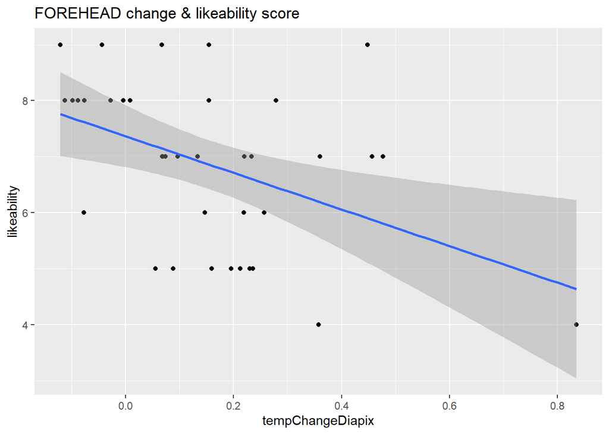

```r
ggplot(datChange |> filter(ROI=="Forehead"), aes(tempChangeDiapix, likeability))+
  geom_point()+
  geom_smooth(method="lm")+
  ggtitle("FOREHEAD change & likeability score")
```

```r
summary(m <- lmer(tempChangeDiapix ~ likeability + (1|dyad), datChange |> filter(ROI=="Forehead")))
```

```
## boundary (singular) fit: see help('isSingular')
```

```
## Linear mixed model fit by REML. t-tests use Satterthwaite's method [
## lmerModLmerTest]
## Formula: tempChangeDiapix ~ likeability + (1 | dyad)
##    Data: filter(datChange, ROI == "Forehead")
##
## REML criterion at convergence: -13.7
##
## Scaled residuals:
##     Min      1Q  Median      3Q     Max
## -1.5705 -0.5596 -0.2756  0.3683  2.8633
##
## Random effects:
##  Groups   Name        Variance Std.Dev.
##  dyad     (Intercept) 0.00000  0.0000
##  Residual             0.03201  0.1789
## Number of obs: 38, groups:  dyad, 19
##
## Fixed effects:
##             Estimate Std. Error       df t value Pr(>|t|)
## (Intercept)  0.56207    0.14183 36.00000   3.963 0.000336 ***
## likeability -0.05972    0.02021 36.00000  -2.955 0.005488 **
## ---
## Signif. codes:  0 '***' 0.001 '**' 0.01 '*' 0.05 '.' 0.1 ' ' 1
##
## Correlation of Fixed Effects:
##             (Intr)
## likeability -0.979
## optimizer (nloptwrap) convergence code: 0 (OK)
## boundary (singular) fit: see help('isSingular')
```

```r
par(mfrow=c(2, 2))
hist(resid(m))
qqnorm(resid(m));qqline(resid(m))
plot(fitted(m), resid(m))

summary(lmer(tempChangeDiapix ~ closeness + (1|dyad), datChange |> filter(ROI=="Forehead")))
```

```
## boundary (singular) fit: see help('isSingular')
```

```
## Linear mixed model fit by REML. t-tests use Satterthwaite's method [
## lmerModLmerTest]
## Formula: tempChangeDiapix ~ closeness + (1 | dyad)
##    Data: filter(datChange, ROI == "Forehead")
##
## REML criterion at convergence: -8.6
##
## Scaled residuals:
##     Min      1Q  Median      3Q     Max
## -1.4999 -0.5632 -0.2144  0.4293  3.3137
##
## Random effects:
##  Groups   Name        Variance Std.Dev.
##  dyad     (Intercept) 0.00000  0.0000
##  Residual             0.03636  0.1907
## Number of obs: 38, groups:  dyad, 19
##
## Fixed effects:
##             Estimate Std. Error       df t value Pr(>|t|)
## (Intercept)  0.26503    0.06890 36.00000   3.847  0.00047 ***
## closeness   -0.03071    0.01671 36.00000  -1.838  0.07430 .
## ---
## Signif. codes:  0 '***' 0.001 '**' 0.01 '*' 0.05 '.' 0.1 ' ' 1
##
## Correlation of Fixed Effects:
##           (Intr)
## closeness -0.894
## optimizer (nloptwrap) convergence code: 0 (OK)
## boundary (singular) fit: see help('isSingular')
```

```r
summary(lmer(tempChangeDiapix ~ similarity + (1|dyad), datChange |> filter(ROI=="Forehead")))
```

```
## boundary (singular) fit: see help('isSingular')
```

```
## Linear mixed model fit by REML. t-tests use Satterthwaite's method [
## lmerModLmerTest]
## Formula: tempChangeDiapix ~ similarity + (1 | dyad)
##    Data: filter(datChange, ROI == "Forehead")
##
## REML criterion at convergence: -9.1
##
## Scaled residuals:
##     Min      1Q  Median      3Q     Max
## -1.5101 -0.6130 -0.1502  0.4336  3.1335
##
## Random effects:
##  Groups   Name        Variance Std.Dev.
##  dyad     (Intercept) 0.00000  0.0000
##  Residual             0.03597  0.1897
## Number of obs: 38, groups:  dyad, 19
##
## Fixed effects:
##             Estimate Std. Error       df t value Pr(>|t|)
## (Intercept)  0.34292    0.10269 36.00000   3.339  0.00196 **
## similarity  -0.03393    0.01740 36.00000  -1.950  0.05899 .
## ---
## Signif. codes:  0 '***' 0.001 '**' 0.01 '*' 0.05 '.' 0.1 ' ' 1
##
## Correlation of Fixed Effects:
##            (Intr)
## similarity -0.954
## optimizer (nloptwrap) convergence code: 0 (OK)
## boundary (singular) fit: see help('isSingular')
```

```r
summary(lmer(tempChangeDiapix ~ becomeFriends + (1|dyad), datChange |> filter(ROI=="Forehead")))
```

```
## boundary (singular) fit: see help('isSingular')
```

```
## Linear mixed model fit by REML. t-tests use Satterthwaite's method [
## lmerModLmerTest]
## Formula: tempChangeDiapix ~ becomeFriends + (1 | dyad)
##    Data: filter(datChange, ROI == "Forehead")
##
## REML criterion at convergence: -7.1
##
## Scaled residuals:
##      Min       1Q   Median       3Q      Max
## -1.58843 -0.67774 -0.05903  0.34210  3.15394
##
## Random effects:
##  Groups   Name        Variance Std.Dev.
##  dyad     (Intercept) 0.00000  0.0000
##  Residual             0.03808  0.1951
## Number of obs: 38, groups:  dyad, 19
##
## Fixed effects:
##               Estimate Std. Error       df t value Pr(>|t|)
## (Intercept)    0.28928    0.11326 36.00000   2.554    0.015 *
## becomeFriends -0.02310    0.01828 36.00000  -1.264    0.214
## ---
## Signif. codes:  0 '***' 0.001 '**' 0.01 '*' 0.05 '.' 0.1 ' ' 1
##
## Correlation of Fixed Effects:
##             (Intr)
## becomeFrnds -0.960
## optimizer (nloptwrap) convergence code: 0 (OK)
## boundary (singular) fit: see help('isSingular')
```

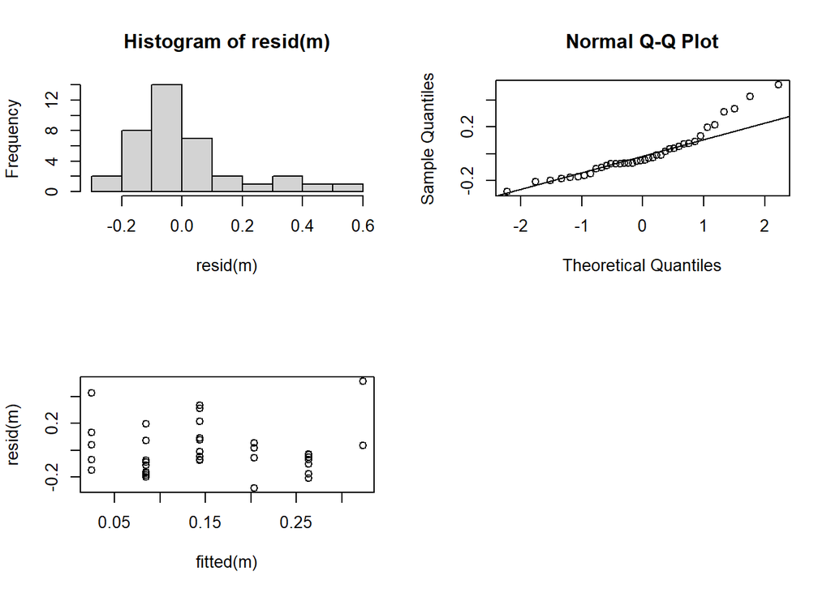

Forehead temperature change was *less positive* when the speaker scored higher on *extraversion*.

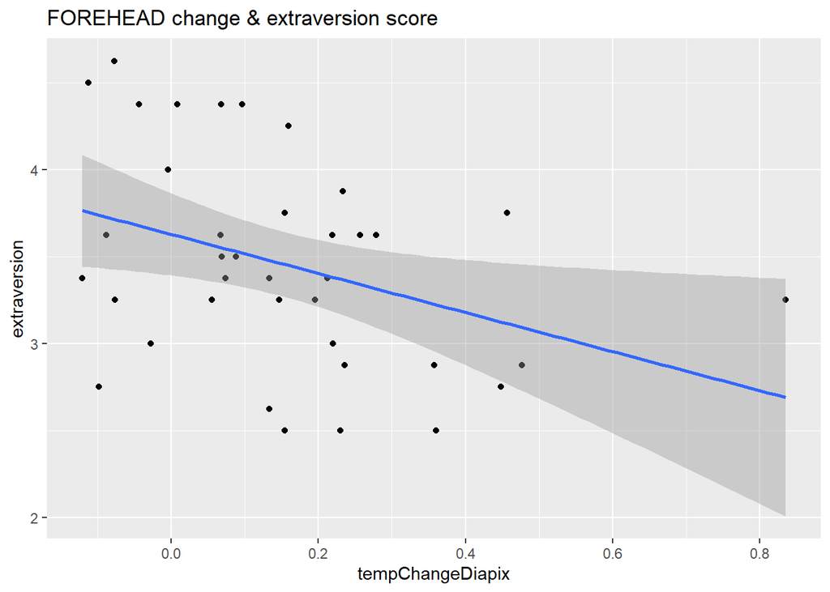

```r
ggplot(datChange |> filter(ROI=="Forehead"), aes(tempChangeDiapix, extraversion))+
  geom_point()+
  geom_smooth(method="lm")+
  ggtitle("FOREHEAD change & extraversion score")
```

```r
summary(m <- lmer(tempChangeDiapix ~ extraversion + (1|dyad), datChange |> filter(ROI=="Forehead")))
```

```
## boundary (singular) fit: see help('isSingular')
```

```
## Linear mixed model fit by REML. t-tests use Satterthwaite's method [
## lmerModLmerTest]
## Formula: tempChangeDiapix ~ extraversion + (1 | dyad)
##    Data: filter(datChange, ROI == "Forehead")
##
## REML criterion at convergence: -12.9
##
## Scaled residuals:
##     Min      1Q  Median      3Q     Max
## -1.8070 -0.4873 -0.1567  0.4932  3.5512
##
## Random effects:
##  Groups   Name        Variance Std.Dev.
##  dyad     (Intercept) 0.0000   0.0000
##  Residual             0.0344   0.1855
## Number of obs: 38, groups:  dyad, 19
##
## Fixed effects:
##              Estimate Std. Error       df t value Pr(>|t|)
## (Intercept)   0.56798    0.17803 36.00000   3.190  0.00294 **
## extraversion -0.12036    0.05075 36.00000  -2.371  0.02319 *
## ---
## Signif. codes:  0 '***' 0.001 '**' 0.01 '*' 0.05 '.' 0.1 ' ' 1
##
## Correlation of Fixed Effects:
##             (Intr)
## extraversin -0.986
## optimizer (nloptwrap) convergence code: 0 (OK)
## boundary (singular) fit: see help('isSingular')
```

```r
par(mfrow=c(2, 2))
hist(resid(m))
qqnorm(resid(m));qqline(resid(m))
plot(fitted(m), resid(m))

summary(lmer(tempChangeDiapix ~ agreeableness + (1|dyad), datChange |> filter(ROI=="Forehead")))
```

```
## boundary (singular) fit: see help('isSingular')
```

```
## Linear mixed model fit by REML. t-tests use Satterthwaite's method [
## lmerModLmerTest]
## Formula: tempChangeDiapix ~ agreeableness + (1 | dyad)
##    Data: filter(datChange, ROI == "Forehead")
##
## REML criterion at convergence: -9.5
##
## Scaled residuals:
##     Min      1Q  Median      3Q     Max
## -1.6381 -0.6755 -0.0821  0.3098  3.2622
##
## Random effects:
##  Groups   Name        Variance Std.Dev.
##  dyad     (Intercept) 0.00000  0.0000
##  Residual             0.03814  0.1953
## Number of obs: 38, groups:  dyad, 19
##
## Fixed effects:
##               Estimate Std. Error       df t value Pr(>|t|)
## (Intercept)    0.41934    0.21822 36.00000   1.922   0.0626 .
## agreeableness -0.07736    0.06245 36.00000  -1.239   0.2234
## ---
## Signif. codes:  0 '***' 0.001 '**' 0.01 '*' 0.05 '.' 0.1 ' ' 1
##
## Correlation of Fixed Effects:
##             (Intr)
## agreeablnss -0.989
## optimizer (nloptwrap) convergence code: 0 (OK)
## boundary (singular) fit: see help('isSingular')
```

```r
summary(lmer(tempChangeDiapix ~ openness + (1|dyad), datChange |> filter(ROI=="Forehead")))
```

```
## boundary (singular) fit: see help('isSingular')
```

```
## Linear mixed model fit by REML. t-tests use Satterthwaite's method [
## lmerModLmerTest]
## Formula: tempChangeDiapix ~ openness + (1 | dyad)
##    Data: filter(datChange, ROI == "Forehead")
##
## REML criterion at convergence: -10.9
##
## Scaled residuals:
##      Min       1Q   Median       3Q      Max
## -1.75600 -0.65647  0.00142  0.26359  3.00076
##
## Random effects:
##  Groups   Name        Variance Std.Dev.
##  dyad     (Intercept) 0.00000  0.0000
##  Residual             0.03576  0.1891
## Number of obs: 38, groups:  dyad, 19
##
## Fixed effects:
##             Estimate Std. Error       df t value Pr(>|t|)
## (Intercept)  0.42001    0.13689 36.00000   3.068  0.00407 **
## openness    -0.07600    0.03781 36.00000  -2.010  0.05197 .
## ---
## Signif. codes:  0 '***' 0.001 '**' 0.01 '*' 0.05 '.' 0.1 ' ' 1
##
## Correlation of Fixed Effects:
##          (Intr)
## openness -0.975
## optimizer (nloptwrap) convergence code: 0 (OK)
## boundary (singular) fit: see help('isSingular')
```

```r
summary(lmer(tempChangeDiapix ~ conscientiousness + (1|dyad), datChange |> filter(ROI=="Forehead")))
```

```
## boundary (singular) fit: see help('isSingular')
```

```
## Linear mixed model fit by REML. t-tests use Satterthwaite's method [
## lmerModLmerTest]
## Formula: tempChangeDiapix ~ conscientiousness + (1 | dyad)
##    Data: filter(datChange, ROI == "Forehead")
##
## REML criterion at convergence: -9.8
##
## Scaled residuals:
##     Min      1Q  Median      3Q     Max
## -1.6144 -0.5675 -0.0181  0.4322  3.0161
##
## Random effects:
##  Groups   Name        Variance Std.Dev.
##  dyad     (Intercept) 0.00000  0.000
##  Residual             0.03764  0.194
## Number of obs: 38, groups:  dyad, 19
##
## Fixed effects:
##                   Estimate Std. Error       df t value Pr(>|t|)
## (Intercept)        0.47025    0.22535 36.00000   2.087   0.0441 *
## conscientiousness -0.07919    0.05550 36.00000  -1.427   0.1623
## ---
## Signif. codes:  0 '***' 0.001 '**' 0.01 '*' 0.05 '.' 0.1 ' ' 1
##
## Correlation of Fixed Effects:
##             (Intr)
## conscntsnss -0.990
## optimizer (nloptwrap) convergence code: 0 (OK)
## boundary (singular) fit: see help('isSingular')
```

```r
summary(lmer(tempChangeDiapix ~ neuroticism + (1|dyad), datChange |> filter(ROI=="Forehead")))
```

```
## boundary (singular) fit: see help('isSingular')
```

```
## Linear mixed model fit by REML. t-tests use Satterthwaite's method [
## lmerModLmerTest]
## Formula: tempChangeDiapix ~ neuroticism + (1 | dyad)
##    Data: filter(datChange, ROI == "Forehead")
##
## REML criterion at convergence: -7.8
##
## Scaled residuals:
##     Min      1Q  Median      3Q     Max
## -1.3431 -0.6722  0.0415  0.4172  3.4274
##
## Random effects:
##  Groups   Name        Variance Std.Dev.
##  dyad     (Intercept) 0.0000   0.000
##  Residual             0.0392   0.198
## Number of obs: 38, groups:  dyad, 19
##
## Fixed effects:
##             Estimate Std. Error       df t value Pr(>|t|)
## (Intercept)  0.25341    0.14401 36.00000   1.760    0.087 .
## neuroticism -0.03219    0.04450 36.00000  -0.723    0.474
## ---
## Signif. codes:  0 '***' 0.001 '**' 0.01 '*' 0.05 '.' 0.1 ' ' 1
##
## Correlation of Fixed Effects:
##             (Intr)
## neuroticism -0.975
## optimizer (nloptwrap) convergence code: 0 (OK)
## boundary (singular) fit: see help('isSingular')
```

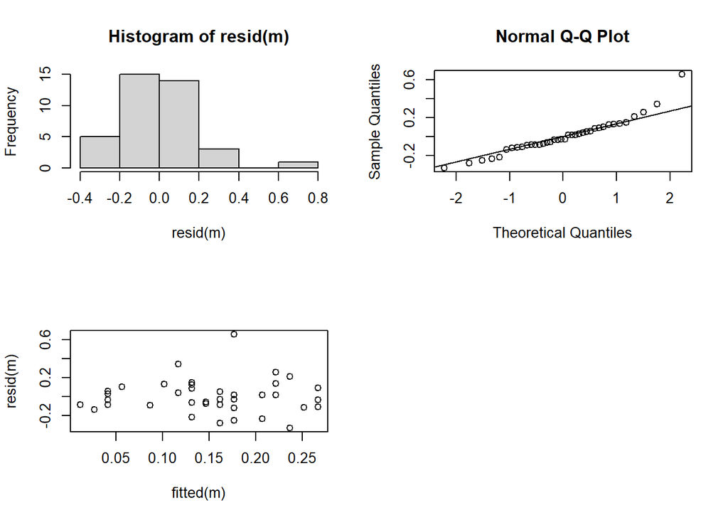

##### Cheeks

No effect of condition.

```r
summary(m <- lmer(tempChangeDiapix ~ condition + (1|dyad), datChange |> filter(ROI=="Cheeks")))
```

```
## Linear mixed model fit by REML. t-tests use Satterthwaite's method [
## lmerModLmerTest]
## Formula: tempChangeDiapix ~ condition + (1 | dyad)
##    Data: filter(datChange, ROI == "Cheeks")
##
## REML criterion at convergence: 12.4
##
## Scaled residuals:
##     Min      1Q  Median      3Q     Max
## -2.0252 -0.5657  0.1516  0.4830  1.8876
##
## Random effects:
##  Groups   Name        Variance Std.Dev.
##  dyad     (Intercept) 0.01838  0.1356
##  Residual             0.05510  0.2347
## Number of obs: 38, groups:  dyad, 19
##
## Fixed effects:
##                     Estimate Std. Error       df t value Pr(>|t|)
## (Intercept)         -0.06361    0.06777 17.00000  -0.939    0.361
## conditionimpersonal  0.07040    0.09847 17.00000   0.715    0.484
##
## Correlation of Fixed Effects:
##             (Intr)
## cndtnmprsnl -0.688
```

No effect of perception of partner.

```r
summary(lmer(tempChangeDiapix ~ likeability + (1|dyad), datChange |> filter(ROI=="Cheeks")))
```

```
## Linear mixed model fit by REML. t-tests use Satterthwaite's method [
## lmerModLmerTest]
## Formula: tempChangeDiapix ~ likeability + (1 | dyad)
##    Data: filter(datChange, ROI == "Cheeks")
##
## REML criterion at convergence: 13.8
##
## Scaled residuals:
##     Min      1Q  Median      3Q     Max
## -1.8631 -0.5622  0.1964  0.3965  2.0438
##
## Random effects:
##  Groups   Name        Variance Std.Dev.
##  dyad     (Intercept) 0.01926  0.1388
##  Residual             0.05252  0.2292
## Number of obs: 38, groups:  dyad, 19
##
## Fixed effects:
##             Estimate Std. Error       df t value Pr(>|t|)
## (Intercept)  0.22136    0.20464 34.24337   1.082    0.287
## likeability -0.03663    0.02893 32.99820  -1.266    0.214
##
## Correlation of Fixed Effects:
##             (Intr)
## likeability -0.971
```

```r
summary(lmer(tempChangeDiapix ~ closeness + (1|dyad), datChange |> filter(ROI=="Cheeks")))
```

```
## Linear mixed model fit by REML. t-tests use Satterthwaite's method [
## lmerModLmerTest]
## Formula: tempChangeDiapix ~ closeness + (1 | dyad)
##    Data: filter(datChange, ROI == "Cheeks")
##
## REML criterion at convergence: 15.7
##
## Scaled residuals:
##     Min      1Q  Median      3Q     Max
## -1.9343 -0.5830  0.1752  0.5051  1.7845
##
## Random effects:
##  Groups   Name        Variance Std.Dev.
##  dyad     (Intercept) 0.01833  0.1354
##  Residual             0.05599  0.2366
## Number of obs: 38, groups:  dyad, 19
##
## Fixed effects:
##              Estimate Std. Error        df t value Pr(>|t|)
## (Intercept) -0.008482   0.100773 33.790260  -0.084    0.933
## closeness   -0.005913   0.023844 35.994944  -0.248    0.806
##
## Correlation of Fixed Effects:
##           (Intr)
## closeness -0.872
```

```r
summary(lmer(tempChangeDiapix ~ similarity + (1|dyad), datChange |> filter(ROI=="Cheeks")))
```

```
## Linear mixed model fit by REML. t-tests use Satterthwaite's method [
## lmerModLmerTest]
## Formula: tempChangeDiapix ~ similarity + (1 | dyad)
##    Data: filter(datChange, ROI == "Cheeks")
##
## REML criterion at convergence: 15.7
##
## Scaled residuals:
##     Min      1Q  Median      3Q     Max
## -1.9791 -0.5578  0.1882  0.5502  1.7806
##
## Random effects:
##  Groups   Name        Variance Std.Dev.
##  dyad     (Intercept) 0.01645  0.1283
##  Residual             0.05745  0.2397
## Number of obs: 38, groups:  dyad, 19
##
## Fixed effects:
##              Estimate Std. Error        df t value Pr(>|t|)
## (Intercept) -0.051650   0.143312 34.854496  -0.360    0.721
## similarity   0.003797   0.023930 32.295247   0.159    0.875
##
## Correlation of Fixed Effects:
##            (Intr)
## similarity -0.940
```

```r
summary(lmer(tempChangeDiapix ~ becomeFriends + (1|dyad), datChange |> filter(ROI=="Cheeks")))
```

```
## Linear mixed model fit by REML. t-tests use Satterthwaite's method [
## lmerModLmerTest]
## Formula: tempChangeDiapix ~ becomeFriends + (1 | dyad)
##    Data: filter(datChange, ROI == "Cheeks")
##
## REML criterion at convergence: 14.7
##
## Scaled residuals:
##     Min      1Q  Median      3Q     Max
## -2.2212 -0.5036  0.1820  0.5310  1.8171
##
## Random effects:
##  Groups   Name        Variance Std.Dev.
##  dyad     (Intercept) 0.01104  0.1051
##  Residual             0.05984  0.2446
## Number of obs: 38, groups:  dyad, 19
##
## Fixed effects:
##               Estimate Std. Error       df t value Pr(>|t|)
## (Intercept)   -0.18329    0.15112 33.83679  -1.213    0.234
## becomeFriends  0.02573    0.02418 31.22529   1.064    0.295
##
## Correlation of Fixed Effects:
##             (Intr)
## becomeFrnds -0.952
```

Cheek temperature change was *less positive* when the speaker scored higher on *agreeableness*.

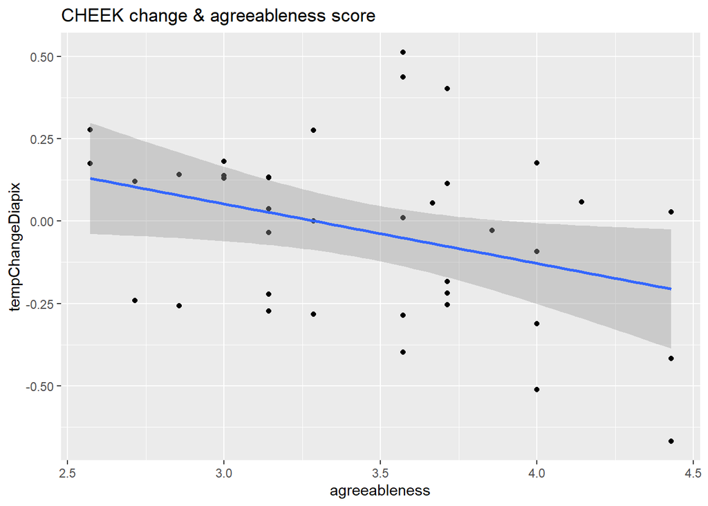

```r
ggplot(datChange |> filter(ROI=="Cheeks"), aes(agreeableness, tempChangeDiapix))+
  geom_point()+
  geom_smooth(method="lm")+
  ggtitle("CHEEK change & agreeableness score")
```

```r
summary(m <- lmer(tempChangeDiapix ~ agreeableness + (1|dyad), datChange |> filter(ROI=="Cheeks")))
```

```
## Linear mixed model fit by REML. t-tests use Satterthwaite's method [
## lmerModLmerTest]
## Formula: tempChangeDiapix ~ agreeableness + (1 | dyad)
##    Data: filter(datChange, ROI == "Cheeks")
##
## REML criterion at convergence: 8.3
##
## Scaled residuals:
##      Min       1Q   Median       3Q      Max
## -1.45118 -0.58086  0.09581  0.50272  1.92523
##
## Random effects:
##  Groups   Name        Variance Std.Dev.
##  dyad     (Intercept) 0.01740  0.1319
##  Residual             0.04816  0.2195
## Number of obs: 38, groups:  dyad, 19
##
## Fixed effects:
##               Estimate Std. Error       df t value Pr(>|t|)
## (Intercept)    0.63526    0.29764 32.12267   2.134   0.0405 *
## agreeableness -0.19249    0.08502 32.46250  -2.264   0.0304 *
## ---
## Signif. codes:  0 '***' 0.001 '**' 0.01 '*' 0.05 '.' 0.1 ' ' 1
##
## Correlation of Fixed Effects:
##             (Intr)
## agreeablnss -0.988
```

```r
par(mfrow=c(2, 2))
hist(resid(m))
qqnorm(resid(m));qqline(resid(m))
plot(fitted(m), resid(m))

summary(lmer(tempChangeDiapix ~ extraversion + (1|dyad), datChange |> filter(ROI=="Cheeks")))
```

```
## Linear mixed model fit by REML. t-tests use Satterthwaite's method [
## lmerModLmerTest]
## Formula: tempChangeDiapix ~ extraversion + (1 | dyad)
##    Data: filter(datChange, ROI == "Cheeks")
##
## REML criterion at convergence: 10.3
##
## Scaled residuals:
##     Min      1Q  Median      3Q     Max
## -2.3063 -0.5476  0.1029  0.5594  1.9331
##
## Random effects:
##  Groups   Name        Variance Std.Dev.
##  dyad     (Intercept) 0.01194  0.1093
##  Residual             0.05508  0.2347
## Number of obs: 38, groups:  dyad, 19
##
## Fixed effects:
##              Estimate Std. Error       df t value Pr(>|t|)
## (Intercept)   0.41782    0.24810 35.99389   1.684   0.1008
## extraversion -0.12961    0.07054 35.98203  -1.837   0.0744 .
## ---
## Signif. codes:  0 '***' 0.001 '**' 0.01 '*' 0.05 '.' 0.1 ' ' 1
##
## Correlation of Fixed Effects:
##             (Intr)
## extraversin -0.983
```

```r
summary(lmer(tempChangeDiapix ~ openness + (1|dyad), datChange |> filter(ROI=="Cheeks")))
```

```
## Linear mixed model fit by REML. t-tests use Satterthwaite's method [
## lmerModLmerTest]
## Formula: tempChangeDiapix ~ openness + (1 | dyad)
##    Data: filter(datChange, ROI == "Cheeks")
##
## REML criterion at convergence: 13.8
##
## Scaled residuals:
##     Min      1Q  Median      3Q     Max
## -2.1208 -0.6016  0.1437  0.4712  1.8137
##
## Random effects:
##  Groups   Name        Variance Std.Dev.
##  dyad     (Intercept) 0.01750  0.1323
##  Residual             0.05587  0.2364
## Number of obs: 38, groups:  dyad, 19
##
## Fixed effects:
##             Estimate Std. Error       df t value Pr(>|t|)
## (Intercept)  0.08869    0.18568 31.30417   0.478    0.636
## openness    -0.03372    0.05077 29.00526  -0.664    0.512
##
## Correlation of Fixed Effects:
##          (Intr)
## openness -0.965
```

```r
summary(lmer(tempChangeDiapix ~ conscientiousness + (1|dyad), datChange |> filter(ROI=="Cheeks")))
```

```
## Linear mixed model fit by REML. t-tests use Satterthwaite's method [
## lmerModLmerTest]
## Formula: tempChangeDiapix ~ conscientiousness + (1 | dyad)
##    Data: filter(datChange, ROI == "Cheeks")
##
## REML criterion at convergence: 13.4
##
## Scaled residuals:
##     Min      1Q  Median      3Q     Max
## -1.9705 -0.5932  0.1923  0.5558  1.7803
##
## Random effects:
##  Groups   Name        Variance Std.Dev.
##  dyad     (Intercept) 0.01676  0.1295
##  Residual             0.05714  0.2390
## Number of obs: 38, groups:  dyad, 19
##
## Fixed effects:
##                   Estimate Std. Error       df t value Pr(>|t|)
## (Intercept)        0.04523    0.30486 33.55941   0.148    0.883
## conscientiousness -0.01878    0.07485 32.96661  -0.251    0.803
##
## Correlation of Fixed Effects:
##             (Intr)
## conscntsnss -0.987
```

```r
summary(lmer(tempChangeDiapix ~ neuroticism + (1|dyad), datChange |> filter(ROI=="Cheeks")))
```

```
## Linear mixed model fit by REML. t-tests use Satterthwaite's method [
## lmerModLmerTest]
## Formula: tempChangeDiapix ~ neuroticism + (1 | dyad)
##    Data: filter(datChange, ROI == "Cheeks")
##
## REML criterion at convergence: 11.5
##
## Scaled residuals:
##     Min      1Q  Median      3Q     Max
## -1.8617 -0.6025  0.2701  0.5353  1.8756
##
## Random effects:
##  Groups   Name        Variance Std.Dev.
##  dyad     (Intercept) 0.01756  0.1325
##  Residual             0.05215  0.2284
## Number of obs: 38, groups:  dyad, 19
##
## Fixed effects:
##             Estimate Std. Error       df t value Pr(>|t|)
## (Intercept)  0.25773    0.18798 35.45563   1.371    0.179
## neuroticism -0.09129    0.05762 34.58022  -1.584    0.122
##
## Correlation of Fixed Effects:
##             (Intr)
## neuroticism -0.967
```

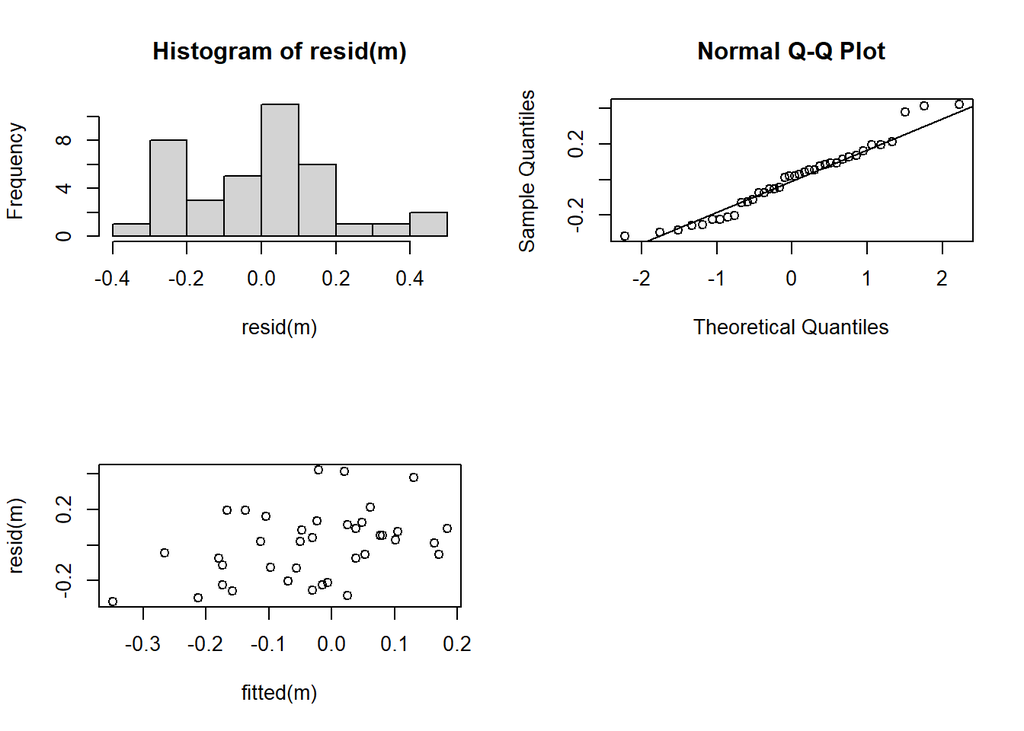

#### Entire Experiment

##### Nose

No condition effect.

```r
summary(lmer(tempChangeEntireExp ~ condition + (1|dyad), datChange |> filter(ROI=="Nose")))
```

```
## Linear mixed model fit by REML. t-tests use Satterthwaite's method [
## lmerModLmerTest]
## Formula: tempChangeEntireExp ~ condition + (1 | dyad)
##    Data: filter(datChange, ROI == "Nose")
##
## REML criterion at convergence: 136.7
##
## Scaled residuals:
##     Min      1Q  Median      3Q     Max
## -3.2703 -0.2067  0.1809  0.4496  1.9349
##
## Random effects:
##  Groups   Name        Variance Std.Dev.
##  dyad     (Intercept) 0.2801   0.5292
##  Residual             1.9676   1.4027
## Number of obs: 38, groups:  dyad, 19
##
## Fixed effects:
##                     Estimate Std. Error      df t value Pr(>|t|)
## (Intercept)           0.5214     0.3555 17.0000   1.467    0.161
## conditionimpersonal  -0.1538     0.5165 17.0000  -0.298    0.769
##
## Correlation of Fixed Effects:
##             (Intr)
## cndtnmprsnl -0.688
```

No effect of perception of partner

```r
summary(lmer(tempChangeEntireExp ~ closeness + (1|dyad), datChange |> filter(ROI=="Nose")))
```

```
## Linear mixed model fit by REML. t-tests use Satterthwaite's method [
## lmerModLmerTest]
## Formula: tempChangeEntireExp ~ closeness + (1 | dyad)
##    Data: filter(datChange, ROI == "Nose")
##
## REML criterion at convergence: 139.5
##
## Scaled residuals:
##     Min      1Q  Median      3Q     Max
## -3.3600 -0.2090  0.1635  0.4258  1.9695
##
## Random effects:
##  Groups   Name        Variance Std.Dev.
##  dyad     (Intercept) 0.2295   0.479
##  Residual             2.0148   1.419
## Number of obs: 38, groups:  dyad, 19
##
## Fixed effects:
##             Estimate Std. Error       df t value Pr(>|t|)
## (Intercept)  0.38596    0.54975 32.13471   0.702    0.488
## closeness    0.01698    0.13217 35.07544   0.128    0.899
##
## Correlation of Fixed Effects:
##           (Intr)
## closeness -0.886
```

```r
summary(lmer(tempChangeEntireExp ~ similarity + (1|dyad), datChange |> filter(ROI=="Nose")))
```

```
## Linear mixed model fit by REML. t-tests use Satterthwaite's method [
## lmerModLmerTest]
## Formula: tempChangeEntireExp ~ similarity + (1 | dyad)
##    Data: filter(datChange, ROI == "Nose")
##
## REML criterion at convergence: 138.9
##
## Scaled residuals:
##     Min      1Q  Median      3Q     Max
## -3.3587 -0.2874  0.1411  0.4876  1.9097
##
## Random effects:
##  Groups   Name        Variance Std.Dev.
##  dyad     (Intercept) 0.2114   0.4598
##  Residual             1.9975   1.4133
## Number of obs: 38, groups:  dyad, 19
##
## Fixed effects:
##             Estimate Std. Error      df t value Pr(>|t|)
## (Intercept)  -0.1206     0.7999 35.7023  -0.151    0.881
## similarity    0.1011     0.1348 34.4392   0.750    0.458
##
## Correlation of Fixed Effects:
##            (Intr)
## similarity -0.949
```

```r
summary(lmer(tempChangeEntireExp ~ likeability + (1|dyad), datChange |> filter(ROI=="Nose")))
```

```
## Linear mixed model fit by REML. t-tests use Satterthwaite's method [
## lmerModLmerTest]
## Formula: tempChangeEntireExp ~ likeability + (1 | dyad)
##    Data: filter(datChange, ROI == "Nose")
##
## REML criterion at convergence: 138.4
##
## Scaled residuals:
##     Min      1Q  Median      3Q     Max
## -3.3245 -0.1216  0.1265  0.3924  2.1754
##
## Random effects:
##  Groups   Name        Variance Std.Dev.
##  dyad     (Intercept) 0.2124   0.4609
##  Residual             1.9960   1.4128
## Number of obs: 38, groups:  dyad, 19
##
## Fixed effects:
##             Estimate Std. Error      df t value Pr(>|t|)
## (Intercept)   1.3142     1.1721 35.7894   1.121    0.270
## likeability  -0.1260     0.1666 35.4057  -0.756    0.454
##
## Correlation of Fixed Effects:
##             (Intr)
## likeability -0.977
```

```r
summary(lmer(tempChangeEntireExp ~ becomeFriends + (1|dyad), datChange |> filter(ROI=="Nose")))
```

```
## Linear mixed model fit by REML. t-tests use Satterthwaite's method [
## lmerModLmerTest]
## Formula: tempChangeEntireExp ~ becomeFriends + (1 | dyad)
##    Data: filter(datChange, ROI == "Nose")
##
## REML criterion at convergence: 137.8
##
## Scaled residuals:
##     Min      1Q  Median      3Q     Max
## -3.4430 -0.3629  0.1388  0.5363  1.8341
##
## Random effects:
##  Groups   Name        Variance Std.Dev.
##  dyad     (Intercept) 0.03011  0.1735
##  Residual             2.10615  1.4513
## Number of obs: 38, groups:  dyad, 19
##
## Fixed effects:
##               Estimate Std. Error      df t value Pr(>|t|)
## (Intercept)    -0.6080     0.8474 35.2653  -0.718    0.478
## becomeFriends   0.1777     0.1367 33.9149   1.300    0.203
##
## Correlation of Fixed Effects:
##             (Intr)
## becomeFrnds -0.959
```

Nose temperature change was *less positive* when the person scored higher on extraversion.

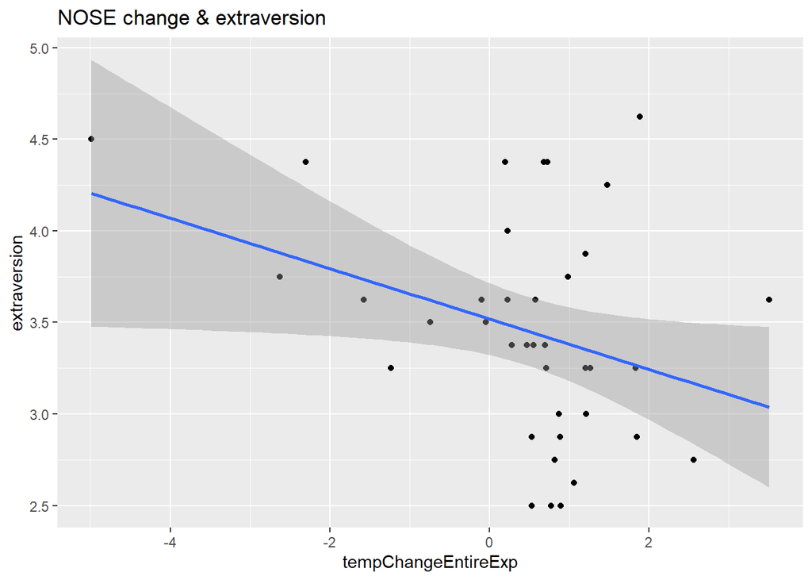

```r
ggplot(datChange |> filter(ROI=="Nose"), aes(tempChangeEntireExp, extraversion))+
  geom_point()+
  geom_smooth(method="lm")+
  ggtitle("NOSE change & extraversion")
```

```r
summary(m <- lmer(tempChangeEntireExp ~ extraversion + (1|dyad), datChange |> filter(ROI=="Nose")))
```

```
## Linear mixed model fit by REML. t-tests use Satterthwaite's method [
## lmerModLmerTest]
## Formula: tempChangeEntireExp ~ extraversion + (1 | dyad)
##    Data: filter(datChange, ROI == "Nose")
##
## REML criterion at convergence: 133
##
## Scaled residuals:
##      Min       1Q   Median       3Q      Max
## -3.09471 -0.32219  0.02637  0.48491  2.22548
##
## Random effects:
##  Groups   Name        Variance Std.Dev.
##  dyad     (Intercept) 0.1125   0.3354
##  Residual             1.8733   1.3687
## Number of obs: 38, groups:  dyad, 19
##
## Fixed effects:
##              Estimate Std. Error      df t value Pr(>|t|)
## (Intercept)    3.2958     1.3566 35.3953   2.429   0.0203 *
## extraversion  -0.8236     0.3865 35.6205  -2.131   0.0401 *
## ---
## Signif. codes:  0 '***' 0.001 '**' 0.01 '*' 0.05 '.' 0.1 ' ' 1
##
## Correlation of Fixed Effects:
##             (Intr)
## extraversin -0.985
```

```r
par(mfrow=c(2, 2))
hist(resid(m))
qqnorm(resid(m));qqline(resid(m))
plot(fitted(m), resid(m))

summary(lmer(tempChangeEntireExp ~ openness + (1|dyad), datChange |> filter(ROI=="Nose")))
```

```
## Linear mixed model fit by REML. t-tests use Satterthwaite's method [
## lmerModLmerTest]
## Formula: tempChangeEntireExp ~ openness + (1 | dyad)
##    Data: filter(datChange, ROI == "Nose")
##
## REML criterion at convergence: 136.3
##
## Scaled residuals:
##     Min      1Q  Median      3Q     Max
## -3.0482 -0.2217  0.2078  0.4385  1.8515
##
## Random effects:
##  Groups   Name        Variance Std.Dev.
##  dyad     (Intercept) 0.3921   0.6262
##  Residual             1.7855   1.3362
## Number of obs: 38, groups:  dyad, 19
##
## Fixed effects:
##             Estimate Std. Error      df t value Pr(>|t|)
## (Intercept)   1.7657     1.0302 31.8409   1.714   0.0963 .
## openness     -0.3733     0.2825 29.7914  -1.321   0.1964
## ---
## Signif. codes:  0 '***' 0.001 '**' 0.01 '*' 0.05 '.' 0.1 ' ' 1
##
## Correlation of Fixed Effects:
##          (Intr)
## openness -0.968
```

```r
summary(lmer(tempChangeEntireExp ~ agreeableness + (1|dyad), datChange |> filter(ROI=="Nose")))
```

```
## Linear mixed model fit by REML. t-tests use Satterthwaite's method [
## lmerModLmerTest]
## Formula: tempChangeEntireExp ~ agreeableness + (1 | dyad)
##    Data: filter(datChange, ROI == "Nose")
##
## REML criterion at convergence: 136.8
##
## Scaled residuals:
##     Min      1Q  Median      3Q     Max
## -3.3702 -0.1831  0.1460  0.4132  2.0504
##
## Random effects:
##  Groups   Name        Variance Std.Dev.
##  dyad     (Intercept) 0.2014   0.4488
##  Residual             2.0381   1.4276
## Number of obs: 38, groups:  dyad, 19
##
## Fixed effects:
##               Estimate Std. Error       df t value Pr(>|t|)
## (Intercept)    0.78255    1.70657 27.34955   0.459    0.650
## agreeableness -0.09661    0.48813 27.66553  -0.198    0.845
##
## Correlation of Fixed Effects:
##             (Intr)
## agreeablnss -0.989
```

```r
summary(lmer(tempChangeEntireExp ~ conscientiousness + (1|dyad), datChange |> filter(ROI=="Nose")))
```

```
## Linear mixed model fit by REML. t-tests use Satterthwaite's method [
## lmerModLmerTest]
## Formula: tempChangeEntireExp ~ conscientiousness + (1 | dyad)
##    Data: filter(datChange, ROI == "Nose")
##
## REML criterion at convergence: 135.5
##
## Scaled residuals:
##     Min      1Q  Median      3Q     Max
## -3.2625 -0.2976  0.1604  0.4851  2.0678
##
## Random effects:
##  Groups   Name        Variance Std.Dev.
##  dyad     (Intercept) 0.2096   0.4578
##  Residual             1.9357   1.3913
## Number of obs: 38, groups:  dyad, 19
##
## Fixed effects:
##                   Estimate Std. Error      df t value Pr(>|t|)
## (Intercept)         2.5952     1.6864 35.1905   1.539    0.133
## conscientiousness  -0.5339     0.4149 34.9002  -1.287    0.207
##
## Correlation of Fixed Effects:
##             (Intr)
## conscntsnss -0.989
```

```r
summary(lmer(tempChangeEntireExp ~ neuroticism + (1|dyad), datChange |> filter(ROI=="Nose")))
```

```
## Linear mixed model fit by REML. t-tests use Satterthwaite's method [
## lmerModLmerTest]
## Formula: tempChangeEntireExp ~ neuroticism + (1 | dyad)
##    Data: filter(datChange, ROI == "Nose")
##
## REML criterion at convergence: 137.5
##
## Scaled residuals:
##     Min      1Q  Median      3Q     Max
## -3.4208 -0.2273  0.1788  0.4239  1.9613
##
## Random effects:
##  Groups   Name        Variance Std.Dev.
##  dyad     (Intercept) 0.1971   0.4439
##  Residual             2.0348   1.4264
## Number of obs: 38, groups:  dyad, 19
##
## Fixed effects:
##             Estimate Std. Error      df t value Pr(>|t|)
## (Intercept)   0.8663     1.0862 35.9831   0.798    0.430
## neuroticism  -0.1324     0.3349 35.9550  -0.395    0.695
##
## Correlation of Fixed Effects:
##             (Intr)
## neuroticism -0.973
```

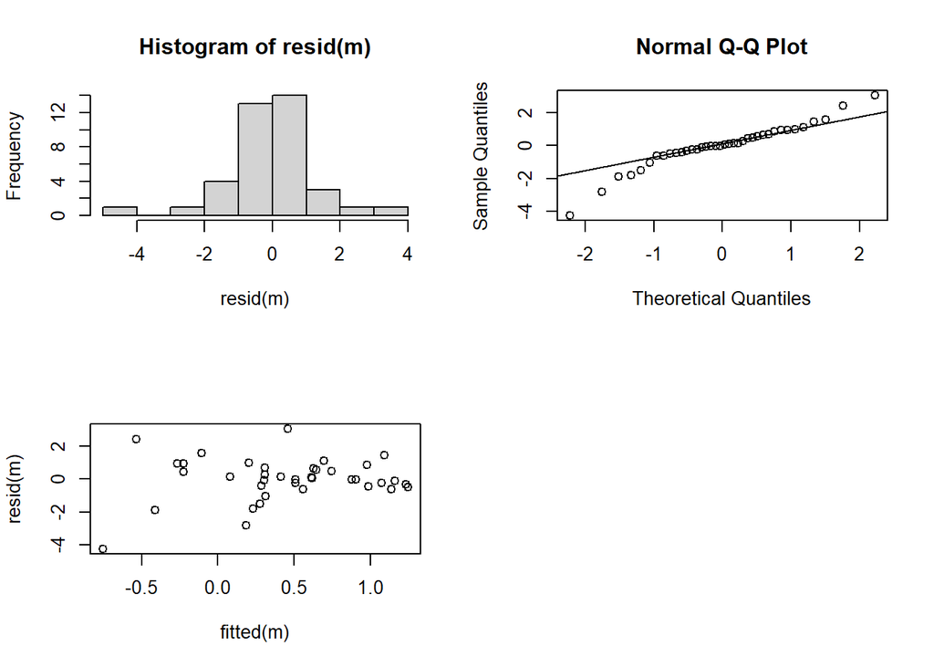

##### Eyes

No condition effect.

```r
summary(lmer(tempChangeEntireExp ~ condition + (1|dyad), datChange |> filter(ROI=="Eyes")))
```

```
## boundary (singular) fit: see help('isSingular')
```

```
## Linear mixed model fit by REML. t-tests use Satterthwaite's method [
## lmerModLmerTest]
## Formula: tempChangeEntireExp ~ condition + (1 | dyad)
##    Data: filter(datChange, ROI == "Eyes")
##
## REML criterion at convergence: -6.3
##
## Scaled residuals:
##     Min      1Q  Median      3Q     Max
## -2.0216 -0.6932 -0.1961  0.5775  1.8021
##
## Random effects:
##  Groups   Name        Variance Std.Dev.
##  dyad     (Intercept) 0.00000  0.0000
##  Residual             0.03986  0.1996
## Number of obs: 33, groups:  dyad, 19
##
## Fixed effects:
##                     Estimate Std. Error       df t value Pr(>|t|)
## (Intercept)          0.23531    0.04580 31.00000   5.138 1.45e-05 ***
## conditionimpersonal  0.11788    0.07032 31.00000   1.676    0.104
## ---
## Signif. codes:  0 '***' 0.001 '**' 0.01 '*' 0.05 '.' 0.1 ' ' 1
##
## Correlation of Fixed Effects:
##             (Intr)
## cndtnmprsnl -0.651
## optimizer (nloptwrap) convergence code: 0 (OK)
## boundary (singular) fit: see help('isSingular')
```

No effect of perception of partner.

```r
summary(lmer(tempChangeEntireExp ~ closeness + (1|dyad), datChange |> filter(ROI=="Eyes")))
```

```
## boundary (singular) fit: see help('isSingular')
```

```
## Linear mixed model fit by REML. t-tests use Satterthwaite's method [
## lmerModLmerTest]
## Formula: tempChangeEntireExp ~ closeness + (1 | dyad)
##    Data: filter(datChange, ROI == "Eyes")
##
## REML criterion at convergence: -2.8
##
## Scaled residuals:
##     Min      1Q  Median      3Q     Max
## -2.0631 -0.5373 -0.1019  0.7337  1.9079
##
## Random effects:
##  Groups   Name        Variance Std.Dev.
##  dyad     (Intercept) 0.00000  0.0000
##  Residual             0.04098  0.2024
## Number of obs: 33, groups:  dyad, 19
##
## Fixed effects:
##             Estimate Std. Error       df t value Pr(>|t|)
## (Intercept)  0.37831    0.07643 31.00000   4.950 2.48e-05 ***
## closeness   -0.02579    0.01881 31.00000  -1.371     0.18
## ---
## Signif. codes:  0 '***' 0.001 '**' 0.01 '*' 0.05 '.' 0.1 ' ' 1
##
## Correlation of Fixed Effects:
##           (Intr)
## closeness -0.887
## optimizer (nloptwrap) convergence code: 0 (OK)
## boundary (singular) fit: see help('isSingular')
```

```r
summary(lmer(tempChangeEntireExp ~ similarity + (1|dyad), datChange |> filter(ROI=="Eyes")))
```

```
## boundary (singular) fit: see help('isSingular')
```

```
## Linear mixed model fit by REML. t-tests use Satterthwaite's method [
## lmerModLmerTest]
## Formula: tempChangeEntireExp ~ similarity + (1 | dyad)
##    Data: filter(datChange, ROI == "Eyes")
##
## REML criterion at convergence: -1.2
##
## Scaled residuals:
##     Min      1Q  Median      3Q     Max
## -2.1045 -0.7141 -0.1127  0.7250  1.9961
##
## Random effects:
##  Groups   Name        Variance Std.Dev.
##  dyad     (Intercept) 0.0000   0.0000
##  Residual             0.0433   0.2081
## Number of obs: 33, groups:  dyad, 19
##
## Fixed effects:
##              Estimate Std. Error        df t value Pr(>|t|)
## (Intercept)  0.325604   0.120808 31.000000   2.695   0.0113 *
## similarity  -0.006997   0.020017 31.000000  -0.350   0.7290
## ---
## Signif. codes:  0 '***' 0.001 '**' 0.01 '*' 0.05 '.' 0.1 ' ' 1
##
## Correlation of Fixed Effects:
##            (Intr)
## similarity -0.954
## optimizer (nloptwrap) convergence code: 0 (OK)
## boundary (singular) fit: see help('isSingular')
```

```r
summary(lmer(tempChangeEntireExp ~ likeability + (1|dyad), datChange |> filter(ROI=="Eyes")))
```

```
## boundary (singular) fit: see help('isSingular')
```

```
## Linear mixed model fit by REML. t-tests use Satterthwaite's method [
## lmerModLmerTest]
## Formula: tempChangeEntireExp ~ likeability + (1 | dyad)
##    Data: filter(datChange, ROI == "Eyes")
##
## REML criterion at convergence: -2.3
##
## Scaled residuals:
##      Min       1Q   Median       3Q      Max
## -2.08357 -0.69607 -0.06864  0.77518  2.08635
##
## Random effects:
##  Groups   Name        Variance Std.Dev.
##  dyad     (Intercept) 0.00000  0.000
##  Residual             0.04242  0.206
## Number of obs: 33, groups:  dyad, 19
##
## Fixed effects:
##             Estimate Std. Error       df t value Pr(>|t|)
## (Intercept)  0.44043    0.18046 31.00000   2.441   0.0206 *
## likeability -0.02245    0.02560 31.00000  -0.877   0.3872
## ---
## Signif. codes:  0 '***' 0.001 '**' 0.01 '*' 0.05 '.' 0.1 ' ' 1
##
## Correlation of Fixed Effects:
##             (Intr)
## likeability -0.980
## optimizer (nloptwrap) convergence code: 0 (OK)
## boundary (singular) fit: see help('isSingular')
```

```r
summary(lmer(tempChangeEntireExp ~ becomeFriends + (1|dyad), datChange |> filter(ROI=="Eyes")))
```

```
## boundary (singular) fit: see help('isSingular')
```

```
## Linear mixed model fit by REML. t-tests use Satterthwaite's method [
## lmerModLmerTest]
## Formula: tempChangeEntireExp ~ becomeFriends + (1 | dyad)
##    Data: filter(datChange, ROI == "Eyes")
##
## REML criterion at convergence: -1.5
##
## Scaled residuals:
##      Min       1Q   Median       3Q      Max
## -2.18767 -0.68660 -0.02671  0.71359  2.11005
##
## Random effects:
##  Groups   Name        Variance Std.Dev.
##  dyad     (Intercept) 0.00000  0.0000
##  Residual             0.04312  0.2077
## Number of obs: 33, groups:  dyad, 19
##
## Fixed effects:
##               Estimate Std. Error       df t value Pr(>|t|)
## (Intercept)    0.35317    0.14053 31.00000   2.513   0.0174 *
## becomeFriends -0.01120    0.02241 31.00000  -0.500   0.6208
## ---
## Signif. codes:  0 '***' 0.001 '**' 0.01 '*' 0.05 '.' 0.1 ' ' 1
##
## Correlation of Fixed Effects:
##             (Intr)
## becomeFrnds -0.966
## optimizer (nloptwrap) convergence code: 0 (OK)
## boundary (singular) fit: see help('isSingular')
```

No effect of BFI scores.

```r
summary(lmer(tempChangeEntireExp ~ extraversion + (1|dyad), datChange |> filter(ROI=="Eyes")))
```

```
## boundary (singular) fit: see help('isSingular')
```

```
## Linear mixed model fit by REML. t-tests use Satterthwaite's method [
## lmerModLmerTest]
## Formula: tempChangeEntireExp ~ extraversion + (1 | dyad)
##    Data: filter(datChange, ROI == "Eyes")
##
## REML criterion at convergence: -3.2
##
## Scaled residuals:
##      Min       1Q   Median       3Q      Max
## -2.16534 -0.72514 -0.07794  0.71385  2.01726
##
## Random effects:
##  Groups   Name        Variance Std.Dev.
##  dyad     (Intercept) 0.00000  0.0000
##  Residual             0.04344  0.2084
## Number of obs: 33, groups:  dyad, 19
##
## Fixed effects:
##              Estimate Std. Error       df t value Pr(>|t|)
## (Intercept)   0.31473    0.20534 31.00000   1.533    0.135
## extraversion -0.00846    0.05812 31.00000  -0.146    0.885
##
## Correlation of Fixed Effects:
##             (Intr)
## extraversin -0.984
## optimizer (nloptwrap) convergence code: 0 (OK)
## boundary (singular) fit: see help('isSingular')
```

```r
summary(lmer(tempChangeEntireExp ~ openness + (1|dyad), datChange |> filter(ROI=="Eyes")))
```

```
## boundary (singular) fit: see help('isSingular')
```

```
## Linear mixed model fit by REML. t-tests use Satterthwaite's method [
## lmerModLmerTest]
## Formula: tempChangeEntireExp ~ openness + (1 | dyad)
##    Data: filter(datChange, ROI == "Eyes")
##
## REML criterion at convergence: -4.7
##
## Scaled residuals:
##      Min       1Q   Median       3Q      Max
## -2.24190 -0.65468 -0.09615  0.87226  2.02695
##
## Random effects:
##  Groups   Name        Variance Std.Dev.
##  dyad     (Intercept) 0.00000  0.0000
##  Residual             0.04066  0.2016
## Number of obs: 33, groups:  dyad, 19
##
## Fixed effects:
##             Estimate Std. Error       df t value Pr(>|t|)
## (Intercept)  0.49888    0.15006 31.00000   3.325  0.00228 **
## openness    -0.06146    0.04199 31.00000  -1.464  0.15332
## ---
## Signif. codes:  0 '***' 0.001 '**' 0.01 '*' 0.05 '.' 0.1 ' ' 1
##
## Correlation of Fixed Effects:
##          (Intr)
## openness -0.972
## optimizer (nloptwrap) convergence code: 0 (OK)
## boundary (singular) fit: see help('isSingular')
```

```r
summary(lmer(tempChangeEntireExp ~ agreeableness + (1|dyad), datChange |> filter(ROI=="Eyes")))
```

```
## boundary (singular) fit: see help('isSingular')
```

```
## Linear mixed model fit by REML. t-tests use Satterthwaite's method [
## lmerModLmerTest]
## Formula: tempChangeEntireExp ~ agreeableness + (1 | dyad)
##    Data: filter(datChange, ROI == "Eyes")
##
## REML criterion at convergence: -4
##
## Scaled residuals:
##     Min      1Q  Median      3Q     Max
## -2.2549 -0.7517 -0.2318  0.7259  1.8745
##
## Random effects:
##  Groups   Name        Variance Std.Dev.
##  dyad     (Intercept) 0.00000  0.0000
##  Residual             0.04294  0.2072
## Number of obs: 33, groups:  dyad, 19
##
## Fixed effects:
##               Estimate Std. Error       df t value Pr(>|t|)
## (Intercept)    0.43941    0.25238 31.00000   1.741   0.0916 .
## agreeableness -0.04468    0.07243 31.00000  -0.617   0.5418
## ---
## Signif. codes:  0 '***' 0.001 '**' 0.01 '*' 0.05 '.' 0.1 ' ' 1
##
## Correlation of Fixed Effects:
##             (Intr)
## agreeablnss -0.990
## optimizer (nloptwrap) convergence code: 0 (OK)
## boundary (singular) fit: see help('isSingular')
```

```r
summary(lmer(tempChangeEntireExp ~ conscientiousness + (1|dyad), datChange |> filter(ROI=="Eyes")))
```

```
## boundary (singular) fit: see help('isSingular')
```

```
## Linear mixed model fit by REML. t-tests use Satterthwaite's method [
## lmerModLmerTest]
## Formula: tempChangeEntireExp ~ conscientiousness + (1 | dyad)
##    Data: filter(datChange, ROI == "Eyes")
##
## REML criterion at convergence: -3.7
##
## Scaled residuals:
##     Min      1Q  Median      3Q     Max
## -2.1196 -0.8061 -0.0464  0.6511  2.1508
##
## Random effects:
##  Groups   Name        Variance Std.Dev.
##  dyad     (Intercept) 0.00000  0.0000
##  Residual             0.04299  0.2073
## Number of obs: 33, groups:  dyad, 19
##
## Fixed effects:
##                   Estimate Std. Error       df t value Pr(>|t|)
## (Intercept)        0.43489    0.25754 31.00000   1.689    0.101
## conscientiousness -0.03777    0.06440 31.00000  -0.587    0.562
##
## Correlation of Fixed Effects:
##             (Intr)
## conscntsnss -0.990
## optimizer (nloptwrap) convergence code: 0 (OK)
## boundary (singular) fit: see help('isSingular')
```

```r
summary(lmer(tempChangeEntireExp ~ neuroticism + (1|dyad), datChange |> filter(ROI=="Eyes")))
```

```
## boundary (singular) fit: see help('isSingular')
```

```
## Linear mixed model fit by REML. t-tests use Satterthwaite's method [
## lmerModLmerTest]
## Formula: tempChangeEntireExp ~ neuroticism + (1 | dyad)
##    Data: filter(datChange, ROI == "Eyes")
##
## REML criterion at convergence: -3.1
##
## Scaled residuals:
##      Min       1Q   Median       3Q      Max
## -2.17359 -0.71559 -0.05698  0.71545  2.05444
##
## Random effects:
##  Groups   Name        Variance Std.Dev.
##  dyad     (Intercept) 0.00000  0.0000
##  Residual             0.04347  0.2085
## Number of obs: 33, groups:  dyad, 19
##
## Fixed effects:
##               Estimate Std. Error         df t value Pr(>|t|)
## (Intercept)  0.2873769  0.1740710 31.0000000   1.651    0.109
## neuroticism -0.0006653  0.0549447 31.0000000  -0.012    0.990
##
## Correlation of Fixed Effects:
##             (Intr)
## neuroticism -0.978
## optimizer (nloptwrap) convergence code: 0 (OK)
## boundary (singular) fit: see help('isSingular')
```

##### Forehead

No effect of condition.

```r
summary(m <- lmer(tempChangeEntireExp ~ condition + (1|dyad), datChange |> filter(ROI=="Forehead")))
```

```
## boundary (singular) fit: see help('isSingular')
```

```
## Linear mixed model fit by REML. t-tests use Satterthwaite's method [
## lmerModLmerTest]
## Formula: tempChangeEntireExp ~ condition + (1 | dyad)
##    Data: filter(datChange, ROI == "Forehead")
##
## REML criterion at convergence: 12.1
##
## Scaled residuals:
##     Min      1Q  Median      3Q     Max
## -1.8629 -0.6359 -0.1973  0.4207  2.8010
##
## Random effects:
##  Groups   Name        Variance Std.Dev.
##  dyad     (Intercept) 0.00000  0.0000
##  Residual             0.06954  0.2637
## Number of obs: 38, groups:  dyad, 19
##
## Fixed effects:
##                     Estimate Std. Error       df t value Pr(>|t|)
## (Intercept)          0.23476    0.05897 36.00000   3.981 0.000319 ***
## conditionimpersonal  0.15471    0.08568 36.00000   1.806 0.079323 .
## ---
## Signif. codes:  0 '***' 0.001 '**' 0.01 '*' 0.05 '.' 0.1 ' ' 1
##
## Correlation of Fixed Effects:
##             (Intr)
## cndtnmprsnl -0.688
## optimizer (nloptwrap) convergence code: 0 (OK)
## boundary (singular) fit: see help('isSingular')
```

It seems that people that *liked* their partner more changed forehead temperature *less positively*.

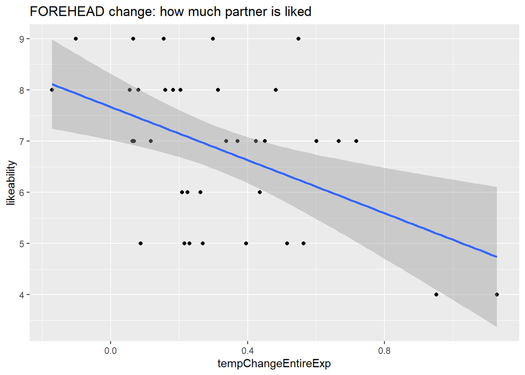

```r
ggplot(datChange |> filter(ROI=="Forehead"), aes(tempChangeEntireExp, likeability))+
  geom_point()+
  geom_smooth(method="lm")+
  ggtitle("FOREHEAD change: how much partner is liked")
```

```r
summary(m <- lmer(tempChangeEntireExp ~ likeability + (1|dyad), datChange |> filter(ROI=="Forehead")))
```

```
## boundary (singular) fit: see help('isSingular')
```

```
## Linear mixed model fit by REML. t-tests use Satterthwaite's method [
## lmerModLmerTest]
## Formula: tempChangeEntireExp ~ likeability + (1 | dyad)
##    Data: filter(datChange, ROI == "Forehead")
##
## REML criterion at convergence: 7.7
##
## Scaled residuals:
##     Min      1Q  Median      3Q     Max
## -1.6160 -0.7413 -0.1434  0.5124  2.3273
##
## Random effects:
##  Groups   Name        Variance Std.Dev.
##  dyad     (Intercept) 0.00000  0.0000
##  Residual             0.05805  0.2409
## Number of obs: 38, groups:  dyad, 19
##
## Fixed effects:
##             Estimate Std. Error       df t value Pr(>|t|)
## (Intercept)  0.92909    0.19101 36.00000   4.864 2.27e-05 ***
## likeability -0.09042    0.02722 36.00000  -3.322  0.00206 **
## ---
## Signif. codes:  0 '***' 0.001 '**' 0.01 '*' 0.05 '.' 0.1 ' ' 1
##
## Correlation of Fixed Effects:
##             (Intr)
## likeability -0.979
## optimizer (nloptwrap) convergence code: 0 (OK)
## boundary (singular) fit: see help('isSingular')
```

```r
par(mfrow=c(2, 2))
hist(resid(m))
qqnorm(resid(m));qqline(resid(m))
plot(fitted(m), resid(m))

summary(lmer(tempChangeEntireExp ~ closeness + (1|dyad), datChange |> filter(ROI=="Forehead")))
```

```
## boundary (singular) fit: see help('isSingular')
```

```
## Linear mixed model fit by REML. t-tests use Satterthwaite's method [
## lmerModLmerTest]
## Formula: tempChangeEntireExp ~ closeness + (1 | dyad)
##    Data: filter(datChange, ROI == "Forehead")
##
## REML criterion at convergence: 15.1
##
## Scaled residuals:
##     Min      1Q  Median      3Q     Max
## -1.9084 -0.6799 -0.1107  0.3892  2.8446
##
## Random effects:
##  Groups   Name        Variance Std.Dev.
##  dyad     (Intercept) 0.0000   0.0000
##  Residual             0.0704   0.2653
## Number of obs: 38, groups:  dyad, 19
##
## Fixed effects:
##             Estimate Std. Error       df t value Pr(>|t|)
## (Intercept)  0.45095    0.09587 36.00000   4.704  3.7e-05 ***
## closeness   -0.03879    0.02325 36.00000  -1.668    0.104
## ---
## Signif. codes:  0 '***' 0.001 '**' 0.01 '*' 0.05 '.' 0.1 ' ' 1
##
## Correlation of Fixed Effects:
##           (Intr)
## closeness -0.894
## optimizer (nloptwrap) convergence code: 0 (OK)
## boundary (singular) fit: see help('isSingular')
```

```r
summary(lmer(tempChangeEntireExp ~ similarity + (1|dyad), datChange |> filter(ROI=="Forehead")))
```

```
## boundary (singular) fit: see help('isSingular')
```

```
## Linear mixed model fit by REML. t-tests use Satterthwaite's method [
## lmerModLmerTest]
## Formula: tempChangeEntireExp ~ similarity + (1 | dyad)
##    Data: filter(datChange, ROI == "Forehead")
##
## REML criterion at convergence: 14.2
##
## Scaled residuals:
##     Min      1Q  Median      3Q     Max
## -1.5880 -0.6677 -0.1632  0.6235  2.6624
##
## Random effects:
##  Groups   Name        Variance Std.Dev.
##  dyad     (Intercept) 0.00000  0.0000
##  Residual             0.06874  0.2622
## Number of obs: 38, groups:  dyad, 19
##
## Fixed effects:
##             Estimate Std. Error       df t value Pr(>|t|)
## (Intercept)  0.56923    0.14196 36.00000   4.010 0.000293 ***
## similarity  -0.04638    0.02405 36.00000  -1.928 0.061723 .
## ---
## Signif. codes:  0 '***' 0.001 '**' 0.01 '*' 0.05 '.' 0.1 ' ' 1
##
## Correlation of Fixed Effects:
##            (Intr)
## similarity -0.954
## optimizer (nloptwrap) convergence code: 0 (OK)
## boundary (singular) fit: see help('isSingular')
```

```r
summary(lmer(tempChangeEntireExp ~ becomeFriends + (1|dyad), datChange |> filter(ROI=="Forehead")))
```

```
## boundary (singular) fit: see help('isSingular')
```

```
## Linear mixed model fit by REML. t-tests use Satterthwaite's method [
## lmerModLmerTest]
## Formula: tempChangeEntireExp ~ becomeFriends + (1 | dyad)
##    Data: filter(datChange, ROI == "Forehead")
##
## REML criterion at convergence: 14.1
##
## Scaled residuals:
##     Min      1Q  Median      3Q     Max
## -1.6397 -0.7369 -0.2967  0.5858  2.5937
##
## Random effects:
##  Groups   Name        Variance Std.Dev.
##  dyad     (Intercept) 0.00000  0.000
##  Residual             0.06865  0.262
## Number of obs: 38, groups:  dyad, 19
##
## Fixed effects:
##               Estimate Std. Error       df t value Pr(>|t|)
## (Intercept)    0.59153    0.15208 36.00000   3.890 0.000415 ***
## becomeFriends -0.04767    0.02455 36.00000  -1.941 0.060058 .
## ---
## Signif. codes:  0 '***' 0.001 '**' 0.01 '*' 0.05 '.' 0.1 ' ' 1
##
## Correlation of Fixed Effects:
##             (Intr)
## becomeFrnds -0.960
## optimizer (nloptwrap) convergence code: 0 (OK)
## boundary (singular) fit: see help('isSingular')
```

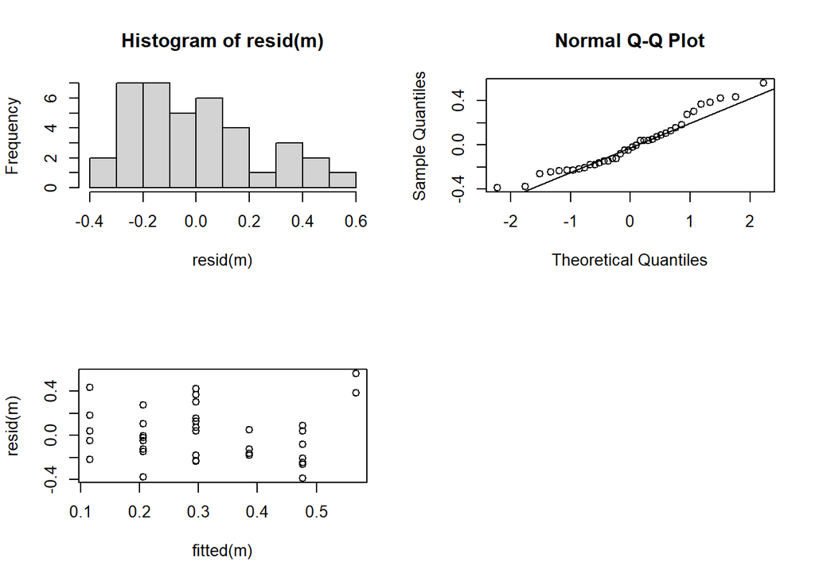

People changed their forehead temperature *less positively* when they scored *higher* in *openness*.

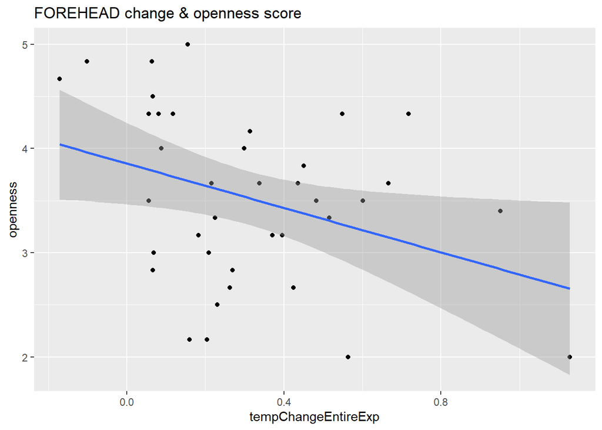

```r
ggplot(datChange |> filter(ROI=="Forehead"), aes(tempChangeEntireExp, openness))+
  geom_point()+
  geom_smooth(method="lm")+
  ggtitle("FOREHEAD change & openness score")
```

```r
summary(m <- lmer(tempChangeEntireExp ~ openness + (1|dyad), datChange |> filter(ROI=="Forehead")))
```

```
## boundary (singular) fit: see help('isSingular')
```

```
## Linear mixed model fit by REML. t-tests use Satterthwaite's method [
## lmerModLmerTest]
## Formula: tempChangeEntireExp ~ openness + (1 | dyad)
##    Data: filter(datChange, ROI == "Forehead")
##
## REML criterion at convergence: 11.4
##
## Scaled residuals:
##     Min      1Q  Median      3Q     Max
## -1.3478 -0.6381 -0.3281  0.4972  2.4922
##
## Random effects:
##  Groups   Name        Variance Std.Dev.
##  dyad     (Intercept) 0.00000  0.0000
##  Residual             0.06646  0.2578
## Number of obs: 38, groups:  dyad, 19
##
## Fixed effects:
##             Estimate Std. Error       df t value Pr(>|t|)
## (Intercept)  0.71814    0.18662 36.00000   3.848 0.000468 ***
## openness    -0.11624    0.05155 36.00000  -2.255 0.030320 *
## ---
## Signif. codes:  0 '***' 0.001 '**' 0.01 '*' 0.05 '.' 0.1 ' ' 1
##
## Correlation of Fixed Effects:
##          (Intr)
## openness -0.975
## optimizer (nloptwrap) convergence code: 0 (OK)
## boundary (singular) fit: see help('isSingular')
```

```r
par(mfrow=c(2, 2))
hist(resid(m))
qqnorm(resid(m));qqline(resid(m))
plot(fitted(m), resid(m))

summary(lmer(tempChangeEntireExp ~ extraversion + (1|dyad), datChange |> filter(ROI=="Forehead")))
```

```
## boundary (singular) fit: see help('isSingular')
```

```
## Linear mixed model fit by REML. t-tests use Satterthwaite's method [
## lmerModLmerTest]
## Formula: tempChangeEntireExp ~ extraversion + (1 | dyad)
##    Data: filter(datChange, ROI == "Forehead")
##
## REML criterion at convergence: 12.5
##
## Scaled residuals:
##     Min      1Q  Median      3Q     Max
## -1.5917 -0.7437 -0.1991  0.5584  3.0047
##
## Random effects:
##  Groups   Name        Variance Std.Dev.
##  dyad     (Intercept) 0.00000  0.0000
##  Residual             0.06975  0.2641
## Number of obs: 38, groups:  dyad, 19
##
## Fixed effects:
##              Estimate Std. Error       df t value Pr(>|t|)
## (Intercept)   0.75125    0.25352 36.00000   2.963  0.00537 **
## extraversion -0.12820    0.07227 36.00000  -1.774  0.08456 .
## ---
## Signif. codes:  0 '***' 0.001 '**' 0.01 '*' 0.05 '.' 0.1 ' ' 1
##
## Correlation of Fixed Effects:
##             (Intr)
## extraversin -0.986
## optimizer (nloptwrap) convergence code: 0 (OK)
## boundary (singular) fit: see help('isSingular')
```

```r
summary(lmer(tempChangeEntireExp ~ agreeableness + (1|dyad), datChange |> filter(ROI=="Forehead")))
```

```
## boundary (singular) fit: see help('isSingular')
```

```
## Linear mixed model fit by REML. t-tests use Satterthwaite's method [
## lmerModLmerTest]
## Formula: tempChangeEntireExp ~ agreeableness + (1 | dyad)
##    Data: filter(datChange, ROI == "Forehead")
##
## REML criterion at convergence: 15.2
##
## Scaled residuals:
##     Min      1Q  Median      3Q     Max
## -1.7334 -0.7441 -0.2285  0.5013  3.0126
##
## Random effects:
##  Groups   Name        Variance Std.Dev.
##  dyad     (Intercept) 0.00000  0.0000
##  Residual             0.07578  0.2753
## Number of obs: 38, groups:  dyad, 19
##
## Fixed effects:
##               Estimate Std. Error       df t value Pr(>|t|)
## (Intercept)    0.25502    0.30759 36.00000   0.829    0.413
## agreeableness  0.01534    0.08802 36.00000   0.174    0.863
##
## Correlation of Fixed Effects:
##             (Intr)
## agreeablnss -0.989
## optimizer (nloptwrap) convergence code: 0 (OK)
## boundary (singular) fit: see help('isSingular')
```

```r
summary(lmer(tempChangeEntireExp ~ conscientiousness + (1|dyad), datChange |> filter(ROI=="Forehead")))
```

```
## boundary (singular) fit: see help('isSingular')
```

```
## Linear mixed model fit by REML. t-tests use Satterthwaite's method [
## lmerModLmerTest]
## Formula: tempChangeEntireExp ~ conscientiousness + (1 | dyad)
##    Data: filter(datChange, ROI == "Forehead")
##
## REML criterion at convergence: 12.7
##
## Scaled residuals:
##     Min      1Q  Median      3Q     Max
## -1.5502 -0.6102 -0.2364  0.6997  2.4896
##
## Random effects:
##  Groups   Name        Variance Std.Dev.
##  dyad     (Intercept) 0.00000  0.0000
##  Residual             0.07018  0.2649
## Number of obs: 38, groups:  dyad, 19
##
## Fixed effects:
##                   Estimate Std. Error       df t value Pr(>|t|)
## (Intercept)        0.82752    0.30771 36.00000   2.689   0.0108 *
## conscientiousness -0.12921    0.07579 36.00000  -1.705   0.0968 .
## ---
## Signif. codes:  0 '***' 0.001 '**' 0.01 '*' 0.05 '.' 0.1 ' ' 1
##
## Correlation of Fixed Effects:
##             (Intr)
## conscntsnss -0.990
## optimizer (nloptwrap) convergence code: 0 (OK)
## boundary (singular) fit: see help('isSingular')
```

```r
summary(lmer(tempChangeEntireExp ~ neuroticism + (1|dyad), datChange |> filter(ROI=="Forehead")))
```

```
## boundary (singular) fit: see help('isSingular')
```

```
## Linear mixed model fit by REML. t-tests use Satterthwaite's method [
## lmerModLmerTest]
## Formula: tempChangeEntireExp ~ neuroticism + (1 | dyad)
##    Data: filter(datChange, ROI == "Forehead")
##
## REML criterion at convergence: 15.9
##
## Scaled residuals:
##     Min      1Q  Median      3Q     Max
## -1.7317 -0.7888 -0.2228  0.4725  2.9854
##
## Random effects:
##  Groups   Name        Variance Std.Dev.
##  dyad     (Intercept) 0.00000  0.0000
##  Residual             0.07577  0.2753
## Number of obs: 38, groups:  dyad, 19
##
## Fixed effects:
##             Estimate Std. Error       df t value Pr(>|t|)
## (Intercept)  0.27298    0.20022 36.00000   1.363    0.181
## neuroticism  0.01112    0.06187 36.00000   0.180    0.858
##
## Correlation of Fixed Effects:
##             (Intr)
## neuroticism -0.975
## optimizer (nloptwrap) convergence code: 0 (OK)
## boundary (singular) fit: see help('isSingular')
```

[figure not shown]

##### Cheeks

No effect of condition.

```r
summary(m <- lmer(tempChangeEntireExp ~ condition + (1|dyad), datChange |> filter(ROI=="Cheeks")))
```

```
## Linear mixed model fit by REML. t-tests use Satterthwaite's method [
## lmerModLmerTest]
## Formula: tempChangeEntireExp ~ condition + (1 | dyad)
##    Data: filter(datChange, ROI == "Cheeks")
##
## REML criterion at convergence: 46.8
##
## Scaled residuals:
##      Min       1Q   Median       3Q      Max
## -1.88716 -0.59000 -0.00181  0.46965  1.75975
##
## Random effects:
##  Groups   Name        Variance Std.Dev.
##  dyad     (Intercept) 0.07941  0.2818
##  Residual             0.12364  0.3516
## Number of obs: 38, groups:  dyad, 19
##
## Fixed effects:
##                      Estimate Std. Error        df t value Pr(>|t|)
## (Intercept)         -0.002208   0.118841 17.000000  -0.019    0.985
## conditionimpersonal  0.044086   0.172672 17.000000   0.255    0.802
##
## Correlation of Fixed Effects:
##             (Intr)
## cndtnmprsnl -0.688
```

Cheeks changed temperature *less positively* when the speaker liked their partner *more*.

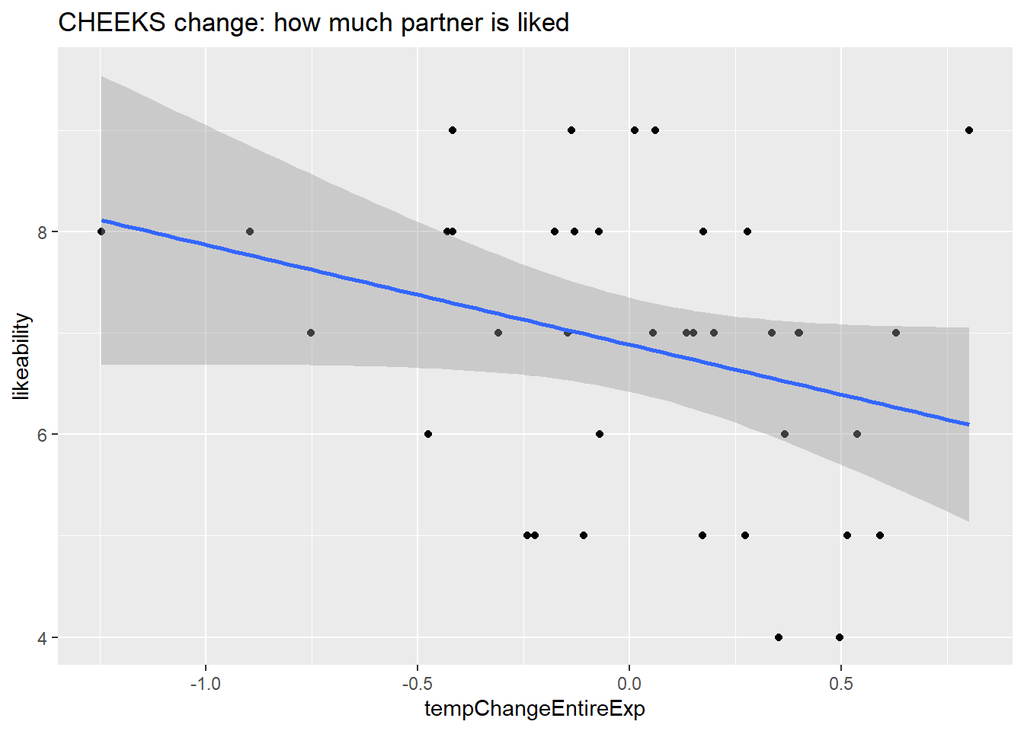

```r
ggplot(datChange |> filter(ROI=="Cheeks"), aes(tempChangeEntireExp, likeability))+
  geom_point()+
  geom_smooth(method="lm")+
  ggtitle("CHEEKS change: how much partner is liked")
```

```r
summary(m <- lmer(tempChangeEntireExp ~ likeability + (1|dyad), datChange |> filter(ROI=="Cheeks")))
```

```
## Linear mixed model fit by REML. t-tests use Satterthwaite's method [
## lmerModLmerTest]
## Formula: tempChangeEntireExp ~ likeability + (1 | dyad)
##    Data: filter(datChange, ROI == "Cheeks")
##
## REML criterion at convergence: 44.8
##
## Scaled residuals:
##      Min       1Q   Median       3Q      Max
## -1.74418 -0.62269  0.06541  0.40747  2.29654
##
## Random effects:
##  Groups   Name        Variance Std.Dev.
##  dyad     (Intercept) 0.08006  0.2830
##  Residual             0.10274  0.3205
## Number of obs: 38, groups:  dyad, 19
##
## Fixed effects:
##             Estimate Std. Error       df t value Pr(>|t|)
## (Intercept)  0.69029    0.30598 31.90827   2.256   0.0311 *
## likeability -0.09778    0.04287 29.55473  -2.281   0.0299 *
## ---
## Signif. codes:  0 '***' 0.001 '**' 0.01 '*' 0.05 '.' 0.1 ' ' 1
##
## Correlation of Fixed Effects:
##             (Intr)
## likeability -0.962
```

```r
par(mfrow=c(2, 2))
hist(resid(m))
qqnorm(resid(m));qqline(resid(m))
plot(fitted(m), resid(m))

summary(lmer(tempChangeEntireExp ~ closeness + (1|dyad), datChange |> filter(ROI=="Cheeks")))
```

```
## Linear mixed model fit by REML. t-tests use Satterthwaite's method [
## lmerModLmerTest]
## Formula: tempChangeEntireExp ~ closeness + (1 | dyad)
##    Data: filter(datChange, ROI == "Cheeks")
##
## REML criterion at convergence: 49
##
## Scaled residuals:
##      Min       1Q   Median       3Q      Max
## -1.85369 -0.44096  0.04468  0.43514  1.92573
##
## Random effects:
##  Groups   Name        Variance Std.Dev.
##  dyad     (Intercept) 0.08407  0.2899
##  Residual             0.11697  0.3420
## Number of obs: 38, groups:  dyad, 19
##
## Fixed effects:
##             Estimate Std. Error       df t value Pr(>|t|)
## (Intercept)  0.15630    0.16326 35.11582   0.957    0.345
## closeness   -0.03735    0.03756 34.77191  -0.994    0.327
##
## Correlation of Fixed Effects:
##           (Intr)
## closeness -0.848
```

```r
summary(lmer(tempChangeEntireExp ~ similarity + (1|dyad), datChange |> filter(ROI=="Cheeks")))
```

```
## Linear mixed model fit by REML. t-tests use Satterthwaite's method [
## lmerModLmerTest]
## Formula: tempChangeEntireExp ~ similarity + (1 | dyad)
##    Data: filter(datChange, ROI == "Cheeks")
##
## REML criterion at convergence: 49.3
##
## Scaled residuals:
##     Min      1Q  Median      3Q     Max
## -1.7583 -0.4802  0.1124  0.4275  1.9117
##
## Random effects:
##  Groups   Name        Variance Std.Dev.
##  dyad     (Intercept) 0.07975  0.2824
##  Residual             0.12064  0.3473
## Number of obs: 38, groups:  dyad, 19
##
## Fixed effects:
##             Estimate Std. Error       df t value Pr(>|t|)
## (Intercept)  0.18869    0.22346 33.39990   0.844    0.404
## similarity  -0.03019    0.03663 28.68894  -0.824    0.417
##
## Correlation of Fixed Effects:
##            (Intr)
## similarity -0.923
```

```r
summary(lmer(tempChangeEntireExp ~ becomeFriends + (1|dyad), datChange |> filter(ROI=="Cheeks")))
```

```
## Linear mixed model fit by REML. t-tests use Satterthwaite's method [
## lmerModLmerTest]
## Formula: tempChangeEntireExp ~ becomeFriends + (1 | dyad)
##    Data: filter(datChange, ROI == "Cheeks")
##
## REML criterion at convergence: 49.8
##
## Scaled residuals:
##      Min       1Q   Median       3Q      Max
## -1.83455 -0.50115 -0.00297  0.53386  1.83034
##
## Random effects:
##  Groups   Name        Variance Std.Dev.
##  dyad     (Intercept) 0.07592  0.2755
##  Residual             0.12517  0.3538
## Number of obs: 38, groups:  dyad, 19
##
## Fixed effects:
##               Estimate Std. Error       df t value Pr(>|t|)
## (Intercept)    0.10932    0.23723 31.80828   0.461    0.648
## becomeFriends -0.01524    0.03721 27.15462  -0.410    0.685
##
## Correlation of Fixed Effects:
##             (Intr)
## becomeFrnds -0.933
```

[figure not shown]

No effects of BFI scores.

```r
summary(lmer(tempChangeEntireExp ~ agreeableness + (1|dyad), datChange |> filter(ROI=="Cheeks")))
```

```
## Linear mixed model fit by REML. t-tests use Satterthwaite's method [
## lmerModLmerTest]
## Formula: tempChangeEntireExp ~ agreeableness + (1 | dyad)
##    Data: filter(datChange, ROI == "Cheeks")
##
## REML criterion at convergence: 46.6
##
## Scaled residuals:
##      Min       1Q   Median       3Q      Max
## -1.83805 -0.64398 -0.01361  0.41760  1.75511
##
## Random effects:
##  Groups   Name        Variance Std.Dev.
##  dyad     (Intercept) 0.06095  0.2469
##  Residual             0.13231  0.3637
## Number of obs: 38, groups:  dyad, 19
##
## Fixed effects:
##               Estimate Std. Error      df t value Pr(>|t|)
## (Intercept)     0.4455     0.5110 32.8351   0.872    0.390
## agreeableness  -0.1235     0.1459 33.2014  -0.846    0.403
##
## Correlation of Fixed Effects:
##             (Intr)
## agreeablnss -0.987
```

```r
summary(lmer(tempChangeEntireExp ~ extraversion + (1|dyad), datChange |> filter(ROI=="Cheeks")))
```

```
## Linear mixed model fit by REML. t-tests use Satterthwaite's method [
## lmerModLmerTest]
## Formula: tempChangeEntireExp ~ extraversion + (1 | dyad)
##    Data: filter(datChange, ROI == "Cheeks")
##
## REML criterion at convergence: 45.6
##
## Scaled residuals:
##     Min      1Q  Median      3Q     Max
## -2.2058 -0.5086 -0.1246  0.5040  1.7943
##
## Random effects:
##  Groups   Name        Variance Std.Dev.
##  dyad     (Intercept) 0.06568  0.2563
##  Residual             0.12276  0.3504
## Number of obs: 38, groups:  dyad, 19
##
## Fixed effects:
##              Estimate Std. Error      df t value Pr(>|t|)
## (Intercept)    0.5902     0.4024 35.1572   1.467    0.151
## extraversion  -0.1653     0.1140 34.5468  -1.451    0.156
##
## Correlation of Fixed Effects:
##             (Intr)
## extraversin -0.979
```

```r
summary(lmer(tempChangeEntireExp ~ openness + (1|dyad), datChange |> filter(ROI=="Cheeks")))
```

```
## Linear mixed model fit by REML. t-tests use Satterthwaite's method [
## lmerModLmerTest]
## Formula: tempChangeEntireExp ~ openness + (1 | dyad)
##    Data: filter(datChange, ROI == "Cheeks")
##
## REML criterion at convergence: 48
##
## Scaled residuals:
##      Min       1Q   Median       3Q      Max
## -2.08157 -0.50900 -0.02929  0.46236  1.79367
##
## Random effects:
##  Groups   Name        Variance Std.Dev.
##  dyad     (Intercept) 0.07534  0.2745
##  Residual             0.12395  0.3521
## Number of obs: 38, groups:  dyad, 19
##
## Fixed effects:
##             Estimate Std. Error       df t value Pr(>|t|)
## (Intercept)  0.21453    0.28876 29.64768   0.743    0.463
## openness    -0.05551    0.07822 26.41098  -0.710    0.484
##
## Correlation of Fixed Effects:
##          (Intr)
## openness -0.956
```

```r
summary(lmer(tempChangeEntireExp ~ conscientiousness + (1|dyad), datChange |> filter(ROI=="Cheeks")))
```

```
## Linear mixed model fit by REML. t-tests use Satterthwaite's method [
## lmerModLmerTest]
## Formula: tempChangeEntireExp ~ conscientiousness + (1 | dyad)
##    Data: filter(datChange, ROI == "Cheeks")
##
## REML criterion at convergence: 47.5
##
## Scaled residuals:
##      Min       1Q   Median       3Q      Max
## -1.96617 -0.50404 -0.05365  0.54231  1.81178
##
## Random effects:
##  Groups   Name        Variance Std.Dev.
##  dyad     (Intercept) 0.07168  0.2677
##  Residual             0.12756  0.3572
## Number of obs: 38, groups:  dyad, 19
##
## Fixed effects:
##                   Estimate Std. Error       df t value Pr(>|t|)
## (Intercept)        0.23294    0.47763 31.36949   0.488    0.629
## conscientiousness -0.05329    0.11693 30.40439  -0.456    0.652
##
## Correlation of Fixed Effects:
##             (Intr)
## conscntsnss -0.984
```

```r
summary(lmer(tempChangeEntireExp ~ neuroticism + (1|dyad), datChange |> filter(ROI=="Cheeks")))
```

```
## Linear mixed model fit by REML. t-tests use Satterthwaite's method [
## lmerModLmerTest]
## Formula: tempChangeEntireExp ~ neuroticism + (1 | dyad)
##    Data: filter(datChange, ROI == "Cheeks")
##
## REML criterion at convergence: 47.3
##
## Scaled residuals:
##      Min       1Q   Median       3Q      Max
## -1.67410 -0.51726 -0.02107  0.60681  1.78126
##
## Random effects:
##  Groups   Name        Variance Std.Dev.
##  dyad     (Intercept) 0.07394  0.2719
##  Residual             0.12324  0.3511
## Number of obs: 38, groups:  dyad, 19
##
## Fixed effects:
##             Estimate Std. Error       df t value Pr(>|t|)
## (Intercept)  0.28748    0.30527 34.22424   0.942    0.353
## neuroticism -0.08521    0.09299 32.46153  -0.916    0.366
##
## Correlation of Fixed Effects:
##             (Intr)
## neuroticism -0.961
```

# Temperature convergence

## Per dyad

```r
all <- data.frame(matrix(nrow=0, ncol=7))
names(all) <- c("dyad", "condition", "ROI", "direction", "t", "p", "section")
```

```r
for(d in unique(dat$dyad)){
  for(r in unique(dat$ROI)){
    dd <- dat |>
      filter(speaker==paste0(d, "-A"), ROI==r)
    if(nrow(dd)<=1){next}
    if(all(is.na(dd$tempDiff))){next}
    c <- tidy(lm(tempDiff ~ time, dd))
    all[nrow(all)+1,] <- c(d, unique(dd$condition[dd$dyad==d]), r,
                           ifelse(c$estimate[2] < 0, "convergence", "divergence"),
                           c$statistic[2],
                           c$p.value[2],
                           "entireExp")
    for(section in c("Lists", "Diapix")){
      dd <- dat |>
        filter(speaker==paste0(d, "-A"), ROI==r, task==section)
      if(nrow(dd)<=1){next}
      if(all(is.na(dd$tempDiff))){next}
      c <- tidy(lm(tempDiff ~ time, dd))
      all[nrow(all)+1,] <- c(d, unique(dd$condition[dd$dyad==d]), r,
                             ifelse(c$estimate[2] < 0, "convergence", "divergence"),
                             c$statistic[2],
                             c$p.value[2],
                             section)
    }
  }
}

all <- all |>
  mutate_at(c("t", "p"), as.numeric) |>
  mutate(sign = ifelse(p<0.05, "yes", "ns"),
         effect = case_when(
           sign == "yes" & direction == "convergence" ~ "convergence",
           sign == "yes" & direction == "divergence" ~ "divergence",
           sign == "ns" ~ "ns"
         )) |>
  mutate_at(c("direction", "dyad", "condition", "section", "ROI", "sign", "effect"), as.factor)

all$section <- factor(all$section, levels=c("Lists", "Diapix", "entireExp"))
all$effect <- factor(all$effect, levels=c("ns", "divergence", "convergence"))
all$ROI <- factor(all$ROI, levels=c("Forehead", "Eyes", "Nose", "Cheeks"))

# data set for poisson regression

dt <- all |>
  group_by(effect, condition, ROI) |>
  summarize(count = n()) |>
  right_join(crossing(effect = unique(all$effect), condition = unique(all$condition), ROI = unique(all$ROI))) |>
  mutate(count = replace_na(count, 0))
conditionCount <- all |>
  group_by(condition, ROI) |>
  summarize(condCount = n())
dt <- merge(dt, conditionCount, by=c("condition", "ROI"))

dt$effect <- relevel(dt$effect, ref="ns")
# contrasts(dt$condition) <- c(-.5,+.5)
dt$condition <- relevel(dt$condition, ref="close")
```

Some dyads converged (or diverged) on some ROIs. (Note: some people wore glasses during all or part of the experiment, hence fewer data points for the Eyes ROI.)

```r
table(all$sign)
```

```
##
##  ns yes
## 119  84
```

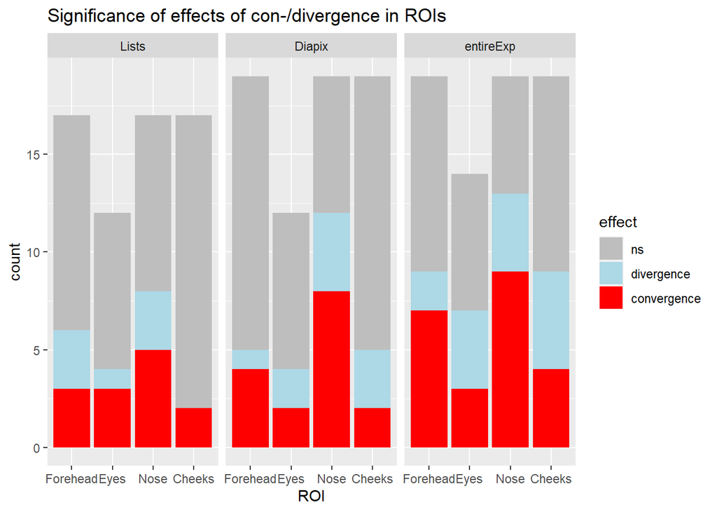

```r
ggplot(all, aes(ROI, fill=effect))+
  geom_bar()+
  facet_wrap(~section)+
  ggtitle("Significance of effects of con-/divergence in ROIs")+
  scale_fill_manual(values = c("divergence" = "lightblue", "convergence" = "red", "ns" = "gray"))
```

Dyads that show an effect in one ROI are likely to show an effect in other ROIs.

```r
sort(table(all$dyad[all$sign!="ns" & all$section=="entireExp"]))
```

```
##
## SGB HBR OAL ZNV AML FWR FXO HUJ KDA MJG NLO OXQ SUK TTN TTY KPB QRT VDE HAG
##   0   1   1   1   2   2   2   2   2   2   2   2   2   2   2   3   3   3   4
```

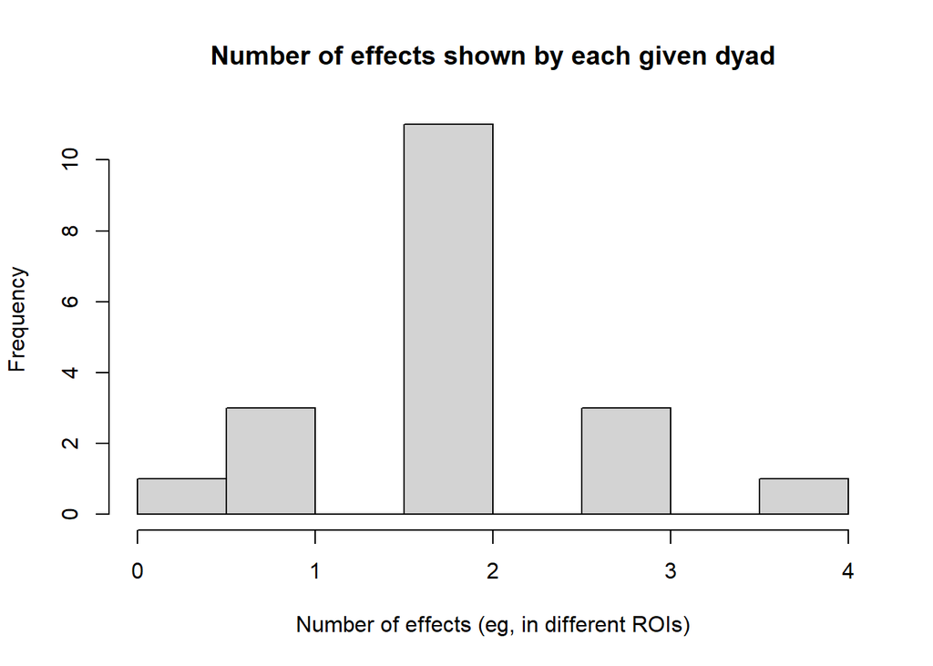

```r
hist(table(all$dyad[all$sign!="ns" & all$section=="entireExp"]), main="Number of effects shown by each given dyad", xlab="Number of effects (eg, in different ROIs)")
```

(I’d like to explore whether dyads converge more/less using questionnaire scores as predictors, but I’m not sure how to do that, since the questionnaires were 1 per speaker, and the convergence measure is 1 per dyad.)

### First part of experiment (Lists)

#### All ROIs

No difference between conditions

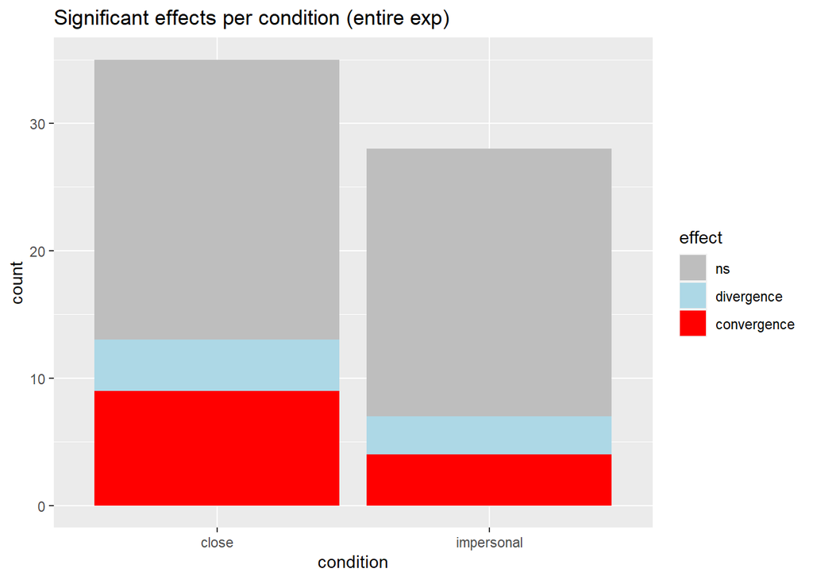

```r
ggplot(all |> filter(section=="Lists"), aes(condition, fill=effect))+
  geom_bar()+
  ggtitle("Significant effects per condition (entire exp)")+
  scale_fill_manual(values = c("divergence" = "lightblue", "convergence" = "red", "ns" = "gray"))
```

```r
summary(glmer(sign ~ condition + (1|dyad), all |> filter(section=="Lists"), family=binomial))
```

```
## boundary (singular) fit: see help('isSingular')
```

```
## Generalized linear mixed model fit by maximum likelihood (Laplace
##   Approximation) [glmerMod]
##  Family: binomial  ( logit )
## Formula: sign ~ condition + (1 | dyad)
##    Data: filter(all, section == "Lists")
##
##      AIC      BIC   logLik deviance df.resid
##     83.7     90.1    -38.8     77.7       60
##
## Scaled residuals:
##     Min      1Q  Median      3Q     Max
## -0.7687 -0.7687 -0.5774  1.3009  1.7321
##
## Random effects:
##  Groups Name        Variance  Std.Dev.
##  dyad   (Intercept) 6.808e-18 2.609e-09
## Number of obs: 63, groups:  dyad, 17
##
## Fixed effects:
##                     Estimate Std. Error z value Pr(>|z|)
## (Intercept)          -0.5261     0.3498  -1.504    0.133
## conditionimpersonal  -0.5725     0.5593  -1.024    0.306
##
## Correlation of Fixed Effects:
##             (Intr)
## cndtnmprsnl -0.625
## optimizer (Nelder_Mead) convergence code: 0 (OK)
## boundary (singular) fit: see help('isSingular')
```

```r
tidy(m <- nnet::multinom(effect ~ condition, data= all |> filter(section=="Lists"))) |>
  as_tibble() |>
  mutate(estimate = plogis(estimate)) # plogis transforms log odds (the output of the model) into probabilities
```

```
## # A tibble: 4 × 6
##   y.level     term                estimate std.error statistic p.value
##   <chr>       <chr>                  <dbl>     <dbl>     <dbl>   <dbl>
## 1 divergence  (Intercept)            0.154     0.544    -3.14  0.00171
## 2 divergence  conditionimpersonal    0.440     0.822    -0.293 0.769
## 3 convergence (Intercept)            0.290     0.396    -2.26  0.0239
## 4 convergence conditionimpersonal    0.318     0.674    -1.13  0.257
```

```r
emmeans(m, pairwise~condition, by="effect")
```

```
## $emmeans
## effect = ns:
##  condition   prob     SE df lower.CL upper.CL
##  close      0.629 0.0817  4   0.4018    0.855
##  impersonal 0.750 0.0818  4   0.5228    0.977
##
## effect = divergence:
##  condition   prob     SE df lower.CL upper.CL
##  close      0.114 0.0538  4  -0.0350    0.264
##  impersonal 0.107 0.0585  4  -0.0551    0.269
##
## effect = convergence:
##  condition   prob     SE df lower.CL upper.CL
##  close      0.257 0.0739  4   0.0520    0.462
##  impersonal 0.143 0.0661  4  -0.0407    0.326
##
## Confidence level used: 0.95
##
## $contrasts
## effect = ns:
##  contrast           estimate     SE df t.ratio p.value
##  close - impersonal -0.12141 0.1156  4  -1.050  0.3529
##
## effect = divergence:
##  contrast           estimate     SE df t.ratio p.value
##  close - impersonal  0.00715 0.0794  4   0.090  0.9326
##
## effect = convergence:
##  contrast           estimate     SE df t.ratio p.value
##  close - impersonal  0.11426 0.0992  4   1.152  0.3133
```

#### Nose

No difference in nose convergence between conditions.

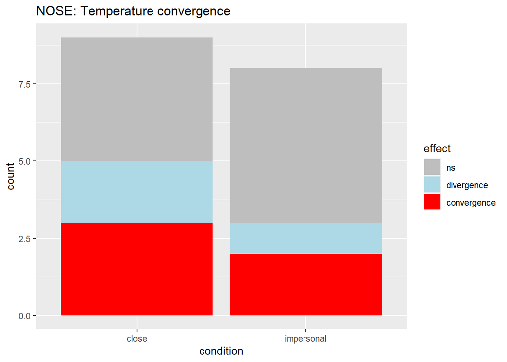

```r
ggplot(all |> filter(ROI=="Nose", section=="Lists"), aes(condition, fill=effect))+
  geom_bar()+
  ggtitle("NOSE: Temperature convergence")+
  scale_fill_manual(values = c("divergence" = "lightblue", "convergence" = "red", "ns" = "gray"))
```

```r
tidy(m <- nnet::multinom(effect ~ condition, data= all |> filter(section=="Lists", ROI=="Nose"))) |>
  as_tibble() |>
  mutate(estimate = plogis(estimate)) # plogis transforms log odds (the output of the model) into probabilities
```

```
## # A tibble: 4 × 6
##   y.level     term                estimate std.error statistic p.value
##   <chr>       <chr>                  <dbl>     <dbl>     <dbl>   <dbl>
## 1 divergence  (Intercept)            0.333     0.866    -0.800   0.423
## 2 divergence  conditionimpersonal    0.286     1.40     -0.656   0.512
## 3 convergence (Intercept)            0.429     0.764    -0.377   0.706
## 4 convergence conditionimpersonal    0.348     1.13     -0.555   0.579
```

```r
emmeans(m, pairwise~condition, by="effect")
```

```
## $emmeans
## effect = ns:
##  condition   prob    SE df lower.CL upper.CL
##  close      0.444 0.166  4  -0.0154    0.904
##  impersonal 0.625 0.171  4   0.1498    1.100
##
## effect = divergence:
##  condition   prob    SE df lower.CL upper.CL
##  close      0.222 0.139  4  -0.1625    0.607
##  impersonal 0.125 0.117  4  -0.1996    0.450
##
## effect = convergence:
##  condition   prob    SE df lower.CL upper.CL
##  close      0.333 0.157  4  -0.1029    0.770
##  impersonal 0.250 0.153  4  -0.1751    0.675
##
## Confidence level used: 0.95
##
## $contrasts
## effect = ns:
##  contrast           estimate    SE df t.ratio p.value
##  close - impersonal  -0.1806 0.238  4  -0.758  0.4906
##
## effect = divergence:
##  contrast           estimate    SE df t.ratio p.value
##  close - impersonal   0.0972 0.181  4   0.536  0.6203
##
## effect = convergence:
##  contrast           estimate    SE df t.ratio p.value
##  close - impersonal   0.0833 0.219  4   0.380  0.7234
```

#### Forehead

No difference in forehead convergence between conditions.

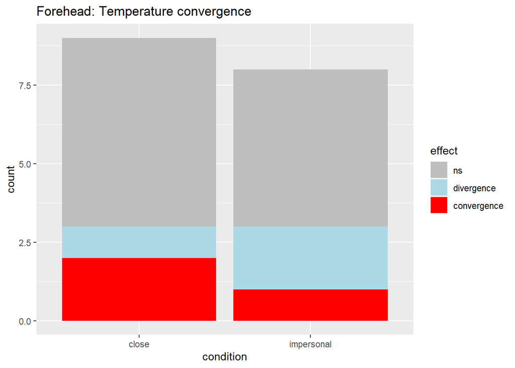

```r
ggplot(all |> filter(ROI=="Forehead", section=="Lists"), aes(condition, fill=effect))+
  geom_bar()+
  ggtitle("Forehead: Temperature convergence")+
  scale_fill_manual(values = c("divergence" = "lightblue", "convergence" = "red", "ns" = "gray"))
```

```r
tidy(m <- nnet::multinom(effect ~ condition, data= all |> filter(section=="Lists", ROI=="Forehead"))) |>
  as_tibble() |>
  mutate(estimate = plogis(estimate)) # plogis transforms log odds (the output of the model) into probabilities
```

```
## # A tibble: 4 × 6
##   y.level     term                estimate std.error statistic p.value
##   <chr>       <chr>                  <dbl>     <dbl>     <dbl>   <dbl>
## 1 divergence  (Intercept)            0.143     1.08     -1.66   0.0971
## 2 divergence  conditionimpersonal    0.706     1.37      0.641  0.522
## 3 convergence (Intercept)            0.250     0.816    -1.35   0.178
## 4 convergence conditionimpersonal    0.375     1.37     -0.374  0.709
```

```r
emmeans(m, pairwise~condition, by="effect")
```

```
## $emmeans
## effect = ns:
##  condition   prob    SE df lower.CL upper.CL
##  close      0.667 0.157  4    0.230    1.103
##  impersonal 0.625 0.171  4    0.150    1.100
##
## effect = divergence:
##  condition   prob    SE df lower.CL upper.CL
##  close      0.111 0.105  4   -0.180    0.402
##  impersonal 0.250 0.153  4   -0.175    0.675
##
## effect = convergence:
##  condition   prob    SE df lower.CL upper.CL
##  close      0.222 0.139  4   -0.163    0.607
##  impersonal 0.125 0.117  4   -0.200    0.450
##
## Confidence level used: 0.95
##
## $contrasts
## effect = ns:
##  contrast           estimate    SE df t.ratio p.value
##  close - impersonal   0.0417 0.232  4   0.179  0.8663
##
## effect = divergence:
##  contrast           estimate    SE df t.ratio p.value
##  close - impersonal  -0.1389 0.186  4  -0.749  0.4956
##
## effect = convergence:
##  contrast           estimate    SE df t.ratio p.value
##  close - impersonal   0.0972 0.181  4   0.536  0.6203
```

#### Eyes

There are no convergence or divergence effects in the impersonal condition, but also much fewer data points overall, so this isn’t necessarily informative.

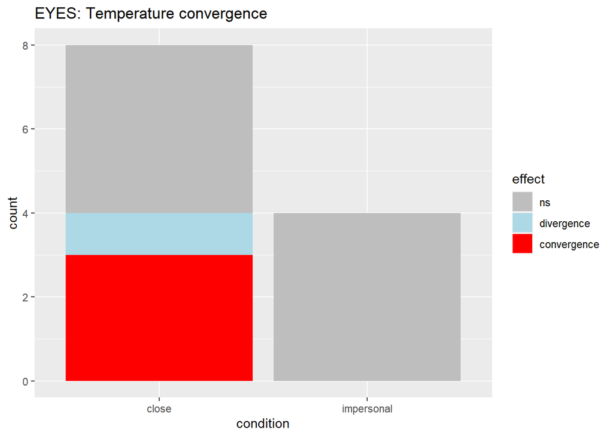

```r
ggplot(all |> filter(ROI=="Eyes", section=="Lists"), aes(condition, fill=effect))+
  geom_bar()+
  ggtitle("EYES: Temperature convergence")+
  scale_fill_manual(values = c("divergence" = "lightblue", "convergence" = "red", "ns" = "gray"))
```

```r
tidy(m <- nnet::multinom(effect ~ condition, data= all |> filter(section=="Lists", ROI=="Eyes"))) |>
  as_tibble() |>
  mutate(estimate = plogis(estimate)) # plogis transforms log odds (the output of the model) into probabilities
```

```
## # A tibble: 4 × 6
##   y.level     term                 estimate std.error statistic p.value
##   <chr>       <chr>                   <dbl>     <dbl>     <dbl>   <dbl>
## 1 divergence  (Intercept)         0.200         1.12    -1.24     0.215
## 2 divergence  conditionimpersonal 0.000119     91.8     -0.0984   0.922
## 3 convergence (Intercept)         0.429         0.764   -0.377    0.706
## 4 convergence conditionimpersonal 0.0000309   104.      -0.100    0.920
```

```r
emmeans(m, pairwise~condition, by="effect")
```

```
## $emmeans
## effect = ns:
##  condition      prob      SE df lower.CL upper.CL
##  close      5.00e-01 0.17678  4  0.00920  0.99082
##  impersonal 1.00e+00 0.00363  4  0.98986  1.01004
##
## effect = divergence:
##  condition      prob      SE df lower.CL upper.CL
##  close      1.25e-01 0.11693  4 -0.19964  0.44963
##  impersonal 2.97e-05 0.00272  4 -0.00753  0.00759
##
## effect = convergence:
##  condition      prob      SE df lower.CL upper.CL
##  close      3.75e-01 0.17116  4 -0.10023  0.85022
##  impersonal 2.32e-05 0.00241  4 -0.00666  0.00671
##
## Confidence level used: 0.95
##
## $contrasts
## effect = ns:
##  contrast           estimate    SE df t.ratio p.value
##  close - impersonal   -0.500 0.177  4  -2.827  0.0475
##
## effect = divergence:
##  contrast           estimate    SE df t.ratio p.value
##  close - impersonal    0.125 0.117  4   1.068  0.3455
##
## effect = convergence:
##  contrast           estimate    SE df t.ratio p.value
##  close - impersonal    0.375 0.171  4   2.190  0.0936
```

#### Cheeks

No difference in cheek convergence between conditions.

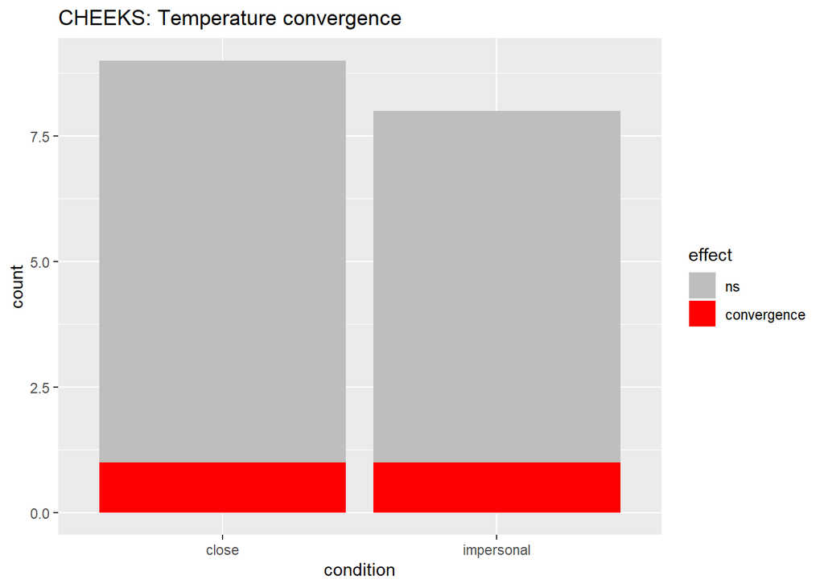

```r
ggplot(all |> filter(ROI=="Cheeks", section=="Lists"), aes(condition, fill=effect))+
  geom_bar()+
  ggtitle("CHEEKS: Temperature convergence")+
  scale_fill_manual(values = c("divergence" = "lightblue", "convergence" = "red", "ns" = "gray"))
```

```r
tidy(m <- nnet::multinom(effect ~ condition, data= all |> filter(section=="Lists", ROI=="Cheeks"))) |>
  as_tibble() |>
  mutate(estimate = plogis(estimate)) # plogis transforms log odds (the output of the model) into probabilities
```

```
## # A tibble: 2 × 6
##   y.level term                estimate std.error statistic p.value
##   <chr>   <chr>                  <dbl>     <dbl>     <dbl>   <dbl>
## 1 1       (Intercept)            0.111      1.06   -1.96    0.0499
## 2 1       conditionimpersonal    0.533      1.51    0.0887  0.929
```

```r
emmeans(m, pairwise~condition, by="effect")
```

```
## $emmeans
## effect = ns:
##  condition   prob    SE df lower.CL upper.CL
##  close      0.889 0.105  2    0.438    1.340
##  impersonal 0.875 0.117  2    0.372    1.378
##
## effect = convergence:
##  condition   prob    SE df lower.CL upper.CL
##  close      0.111 0.105  2   -0.340    0.562
##  impersonal 0.125 0.117  2   -0.378    0.628
##
## Confidence level used: 0.95
##
## $contrasts
## effect = ns:
##  contrast           estimate    SE df t.ratio p.value
##  close - impersonal   0.0139 0.157  2   0.088  0.9376
##
## effect = convergence:
##  contrast           estimate    SE df t.ratio p.value
##  close - impersonal  -0.0139 0.157  2  -0.088  0.9376
```

### Second part of experiment (Diapix)

#### All ROIs

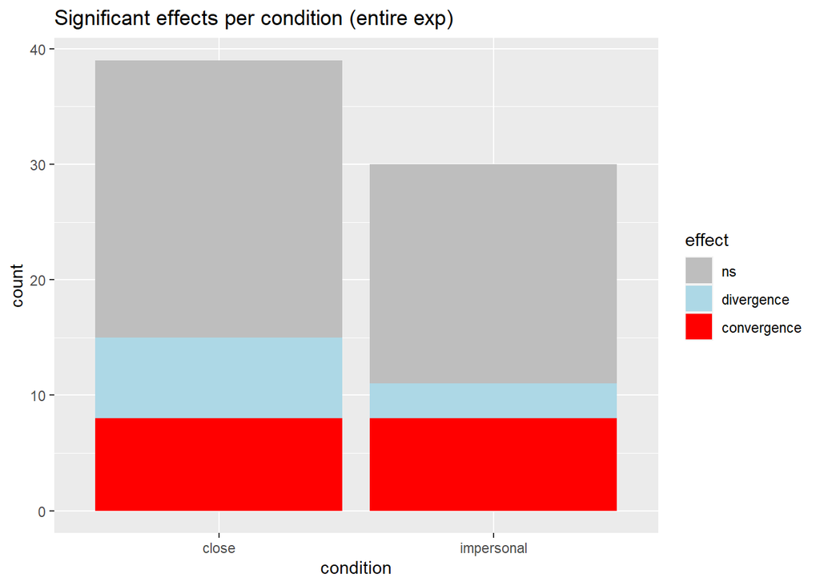

```r
ggplot(all |> filter(section=="Diapix"), aes(condition, fill=effect))+
  geom_bar()+
  ggtitle("Significant effects per condition (entire exp)")+
  scale_fill_manual(values = c("divergence" = "lightblue", "convergence" = "red", "ns" = "gray"))
```

```r
summary(glmer(sign ~ condition + (1|dyad), all |> filter(section=="Diapix"), family=binomial))
```

```
## Generalized linear mixed model fit by maximum likelihood (Laplace
##   Approximation) [glmerMod]
##  Family: binomial  ( logit )
## Formula: sign ~ condition + (1 | dyad)
##    Data: filter(all, section == "Diapix")
##
##      AIC      BIC   logLik deviance df.resid
##     96.6    103.3    -45.3     90.6       66
##
## Scaled residuals:
##     Min      1Q  Median      3Q     Max
## -0.9771 -0.7113 -0.6116  1.0234  1.4496
##
## Random effects:
##  Groups Name        Variance Std.Dev.
##  dyad   (Intercept) 0.4568   0.6759
## Number of obs: 69, groups:  dyad, 19
##
## Fixed effects:
##                     Estimate Std. Error z value Pr(>|z|)
## (Intercept)         -0.52433    0.41367  -1.268    0.205
## conditionimpersonal -0.08584    0.61336  -0.140    0.889
##
## Correlation of Fixed Effects:
##             (Intr)
## cndtnmprsnl -0.653
```

```r
tidy(m <- nnet::multinom(effect ~ condition, data= all |> filter(section=="Diapix"))) |>
  as_tibble() |>
  mutate(estimate = plogis(estimate)) # plogis transforms log odds (the output of the model) into probabilities
```

```
## # A tibble: 4 × 6
##   y.level     term                estimate std.error statistic p.value
##   <chr>       <chr>                  <dbl>     <dbl>     <dbl>   <dbl>
## 1 divergence  (Intercept)            0.226     0.430    -2.87  0.00412
## 2 divergence  conditionimpersonal    0.351     0.755    -0.813 0.416
## 3 convergence (Intercept)            0.250     0.408    -2.69  0.00712
## 4 convergence conditionimpersonal    0.558     0.587     0.398 0.691
```

```r
emmeans(m, pairwise~condition, by="effect")
```

```
## $emmeans
## effect = ns:
##  condition   prob     SE df lower.CL upper.CL
##  close      0.615 0.0779  4  0.39910    0.832
##  impersonal 0.633 0.0880  4  0.38914    0.878
##
## effect = divergence:
##  condition   prob     SE df lower.CL upper.CL
##  close      0.179 0.0614  4  0.00886    0.350
##  impersonal 0.100 0.0548  4 -0.05208    0.252
##
## effect = convergence:
##  condition   prob     SE df lower.CL upper.CL
##  close      0.205 0.0647  4  0.02561    0.385
##  impersonal 0.267 0.0807  4  0.04248    0.491
##
## Confidence level used: 0.95
##
## $contrasts
## effect = ns:
##  contrast           estimate     SE df t.ratio p.value
##  close - impersonal  -0.0180 0.1175  4  -0.153  0.8856
##
## effect = divergence:
##  contrast           estimate     SE df t.ratio p.value
##  close - impersonal   0.0795 0.0823  4   0.966  0.3888
##
## effect = convergence:
##  contrast           estimate     SE df t.ratio p.value
##  close - impersonal  -0.0615 0.1034  4  -0.595  0.5842
```

#### Nose

No difference in nose convergence between conditions.

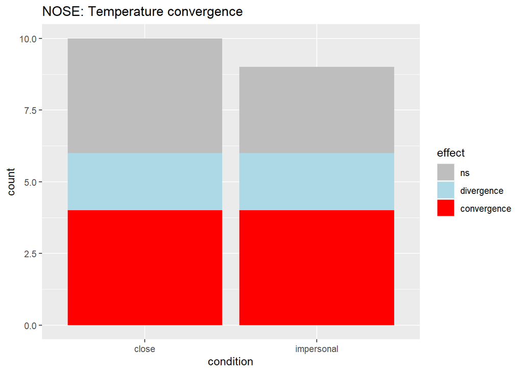

```r
ggplot(all |> filter(ROI=="Nose", section=="Diapix"), aes(condition, fill=effect))+
  geom_bar()+
  ggtitle("NOSE: Temperature convergence")+
  scale_fill_manual(values = c("divergence" = "lightblue", "convergence" = "red", "ns" = "gray"))
```

```r
tidy(m <- nnet::multinom(effect ~ condition, data= all |> filter(section=="Diapix", ROI=="Nose"))) |>
  as_tibble() |>
  mutate(estimate = plogis(estimate)) # plogis transforms log odds (the output of the model) into probabilities
```

```
## # A tibble: 4 × 6
##   y.level     term                estimate std.error   statistic p.value
##   <chr>       <chr>                  <dbl>     <dbl>       <dbl>   <dbl>
## 1 divergence  (Intercept)            0.333     0.866 -0.800        0.423
## 2 divergence  conditionimpersonal    0.571     1.26   0.229        0.819
## 3 convergence (Intercept)            0.500     0.707 -0.00000140   1.00
## 4 convergence conditionimpersonal    0.571     1.04   0.276        0.782
```

```r
emmeans(m, pairwise~condition, by="effect")
```

```
## $emmeans
## effect = ns:
##  condition   prob    SE df lower.CL upper.CL
##  close      0.400 0.155  4  -0.0301    0.830
##  impersonal 0.333 0.157  4  -0.1029    0.770
##
## effect = divergence:
##  condition   prob    SE df lower.CL upper.CL
##  close      0.200 0.126  4  -0.1512    0.551
##  impersonal 0.222 0.139  4  -0.1625    0.607
##
## effect = convergence:
##  condition   prob    SE df lower.CL upper.CL
##  close      0.400 0.155  4  -0.0301    0.830
##  impersonal 0.444 0.166  4  -0.0154    0.904
##
## Confidence level used: 0.95
##
## $contrasts
## effect = ns:
##  contrast           estimate    SE df t.ratio p.value
##  close - impersonal   0.0667 0.221  4   0.302  0.7776
##
## effect = divergence:
##  contrast           estimate    SE df t.ratio p.value
##  close - impersonal  -0.0222 0.188  4  -0.118  0.9114
##
## effect = convergence:
##  contrast           estimate    SE df t.ratio p.value
##  close - impersonal  -0.0444 0.227  4  -0.196  0.8542
```

#### Forehead

No difference in forehead convergence between conditions.

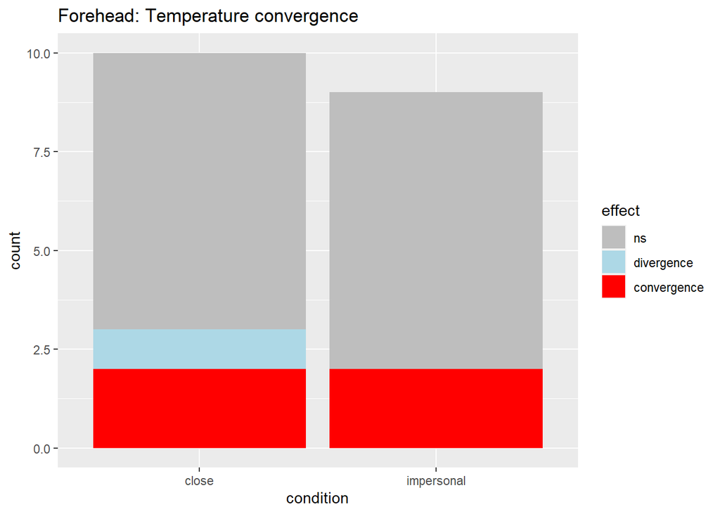

```r
ggplot(all |> filter(ROI=="Forehead", section=="Diapix"), aes(condition, fill=effect))+
  geom_bar()+
  ggtitle("Forehead: Temperature convergence")+
  scale_fill_manual(values = c("divergence" = "lightblue", "convergence" = "red", "ns" = "gray"))
```

```r
tidy(m <- nnet::multinom(effect ~ condition, data= all |> filter(section=="Diapix", ROI=="Forehead"))) |>
  as_tibble() |>
  mutate(estimate = plogis(estimate)) # plogis transforms log odds (the output of the model) into probabilities
```

```
## # A tibble: 4 × 6
##   y.level     term                estimate std.error statistic p.value
##   <chr>       <chr>                  <dbl>     <dbl>     <dbl>   <dbl>
## 1 divergence  (Intercept)         0.125        1.07  -1.82      0.0687
## 2 divergence  conditionimpersonal 0.000267    61.2   -0.134     0.893
## 3 convergence (Intercept)         0.222        0.802 -1.56      0.118
## 4 convergence conditionimpersonal 0.500        1.13  -0.000101  1.00
```

```r
emmeans(m, pairwise~condition, by="effect")
```

```
## $emmeans
## effect = ns:
##  condition      prob      SE df lower.CL upper.CL
##  close      7.00e-01 0.14491  4  0.29767  1.10235
##  impersonal 7.78e-01 0.13858  4  0.39302  1.16254
##
## effect = divergence:
##  condition      prob      SE df lower.CL upper.CL
##  close      1.00e-01 0.09486  4 -0.16339  0.36337
##  impersonal 2.96e-05 0.00181  4 -0.00501  0.00507
##
## effect = convergence:
##  condition      prob      SE df lower.CL upper.CL
##  close      2.00e-01 0.12649  4 -0.15120  0.55120
##  impersonal 2.22e-01 0.13857  4 -0.16255  0.60694
##
## Confidence level used: 0.95
##
## $contrasts
## effect = ns:
##  contrast           estimate     SE df t.ratio p.value
##  close - impersonal  -0.0778 0.2005  4  -0.388  0.7179
##
## effect = divergence:
##  contrast           estimate     SE df t.ratio p.value
##  close - impersonal   0.1000 0.0949  4   1.054  0.3515
##
## effect = convergence:
##  contrast           estimate     SE df t.ratio p.value
##  close - impersonal  -0.0222 0.1876  4  -0.118  0.9115
```

#### Eyes

No difference in eye convergence between conditions.

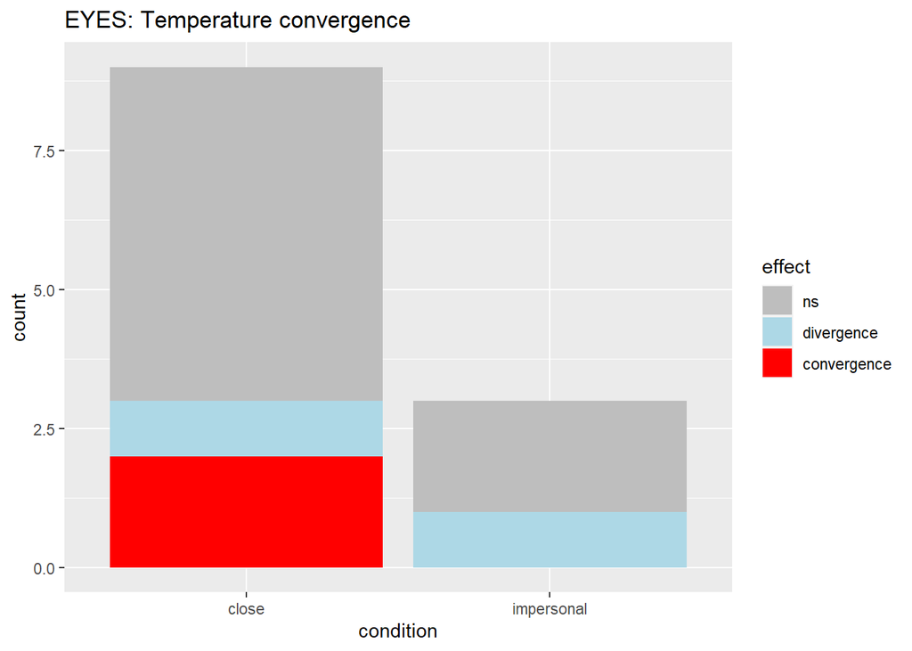

```r
ggplot(all |> filter(ROI=="Eyes", section=="Diapix"), aes(condition, fill=effect))+
  geom_bar()+
  ggtitle("EYES: Temperature convergence")+
  scale_fill_manual(values = c("divergence" = "lightblue", "convergence" = "red", "ns" = "gray"))
```

```r
tidy(m <- nnet::multinom(effect ~ condition, data= all |> filter(section=="Diapix", ROI=="Eyes"))) |>
  as_tibble() |>
  mutate(estimate = plogis(estimate)) # plogis transforms log odds (the output of the model) into probabilities
```

```
## # A tibble: 4 × 6
##   y.level     term                estimate std.error statistic p.value
##   <chr>       <chr>                  <dbl>     <dbl>     <dbl>   <dbl>
## 1 divergence  (Intercept)         0.143        1.08     -1.66   0.0971
## 2 divergence  conditionimpersonal 0.750        1.63      0.673  0.501
## 3 convergence (Intercept)         0.250        0.817    -1.35   0.178
## 4 convergence conditionimpersonal 0.000318    68.7      -0.117  0.907
```

```r
emmeans(m, pairwise~condition, by="effect")
```

```
## $emmeans
## effect = ns:
##  condition      prob      SE df lower.CL upper.CL
##  close      6.67e-01 0.15713  4   0.2305   1.1030
##  impersonal 6.67e-01 0.27217  4  -0.0891   1.4223
##
## effect = divergence:
##  condition      prob      SE df lower.CL upper.CL
##  close      1.11e-01 0.10476  4  -0.1797   0.4020
##  impersonal 3.33e-01 0.27216  4  -0.4223   1.0889
##
## effect = convergence:
##  condition      prob      SE df lower.CL upper.CL
##  close      2.22e-01 0.13857  4  -0.1626   0.6069
##  impersonal 7.06e-05 0.00485  4  -0.0134   0.0135
##
## Confidence level used: 0.95
##
## $contrasts
## effect = ns:
##  contrast            estimate    SE df t.ratio p.value
##  close - impersonal  8.92e-05 0.314  4   0.000  0.9998
##
## effect = divergence:
##  contrast            estimate    SE df t.ratio p.value
##  close - impersonal -2.22e-01 0.292  4  -0.762  0.4886
##
## effect = convergence:
##  contrast            estimate    SE df t.ratio p.value
##  close - impersonal  2.22e-01 0.139  4   1.602  0.1844
```

#### Cheeks

No difference in cheek convergence between conditions.

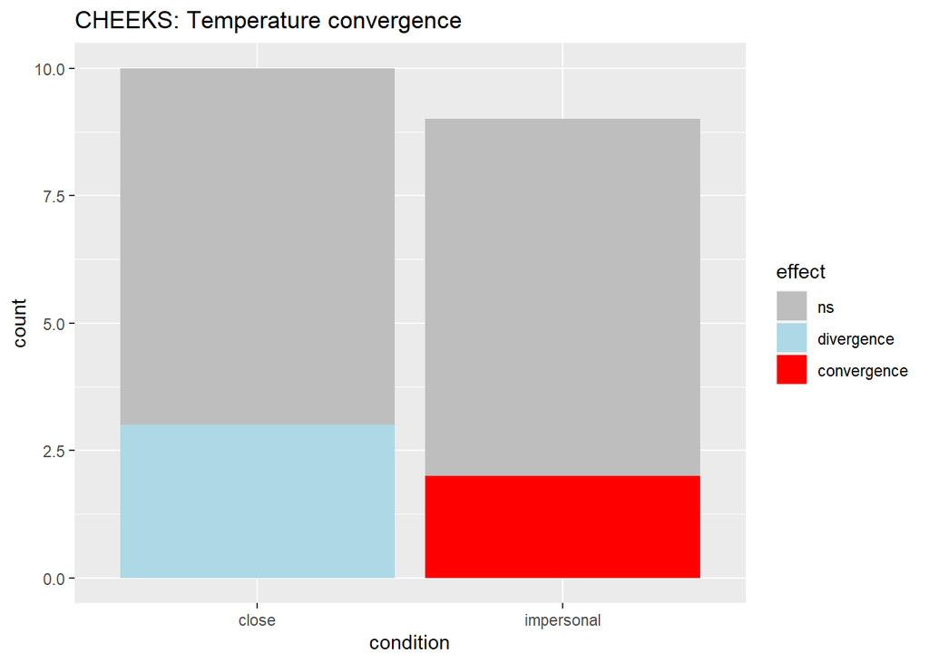

```r
ggplot(all |> filter(ROI=="Cheeks", section=="Diapix"), aes(condition, fill=effect))+
  geom_bar()+
  ggtitle("CHEEKS: Temperature convergence")+
  scale_fill_manual(values = c("divergence" = "lightblue", "convergence" = "red", "ns" = "gray"))
```

```r
tidy(m <- nnet::multinom(effect ~ condition, data= all |> filter(section=="Diapix", ROI=="Cheeks"))) |>
  as_tibble() |>
  mutate(estimate = plogis(estimate)) # plogis transforms log odds (the output of the model) into probabilities
```

```
## # A tibble: 4 × 6
##   y.level     term                  estimate std.error statistic p.value
##   <chr>       <chr>                    <dbl>     <dbl>     <dbl>   <dbl>
## 1 divergence  (Intercept)         0.300          0.690   -1.23     0.220
## 2 divergence  conditionimpersonal 0.00000827   201.      -0.0583   0.954
## 3 convergence (Intercept)         0.0000240     77.1     -0.138    0.890
## 4 convergence conditionimpersonal 1.00          77.1      0.122    0.903
```

```r
emmeans(m, pairwise~condition, by="effect")
```

```
## $emmeans
## effect = ns:
##  condition      prob       SE df lower.CL upper.CL
##  close      7.00e-01 0.144918  4  0.29761  1.10233
##  impersonal 7.78e-01 0.138577  4  0.39304  1.16254
##
## effect = divergence:
##  condition      prob       SE df lower.CL upper.CL
##  close      3.00e-01 0.144916  4 -0.10234  0.70237
##  impersonal 2.80e-06 0.000554  4 -0.00153  0.00154
##
## effect = convergence:
##  condition      prob       SE df lower.CL upper.CL
##  close      1.68e-05 0.001296  4 -0.00358  0.00362
##  impersonal 2.22e-01 0.138576  4 -0.16254  0.60696
##
## Confidence level used: 0.95
##
## $contrasts
## effect = ns:
##  contrast           estimate    SE df t.ratio p.value
##  close - impersonal  -0.0778 0.201  4  -0.388  0.7177
##
## effect = divergence:
##  contrast           estimate    SE df t.ratio p.value
##  close - impersonal   0.3000 0.145  4   2.070  0.1072
##
## effect = convergence:
##  contrast           estimate    SE df t.ratio p.value
##  close - impersonal  -0.2222 0.139  4  -1.603  0.1841
```

### Across entire experiment

#### All ROIs

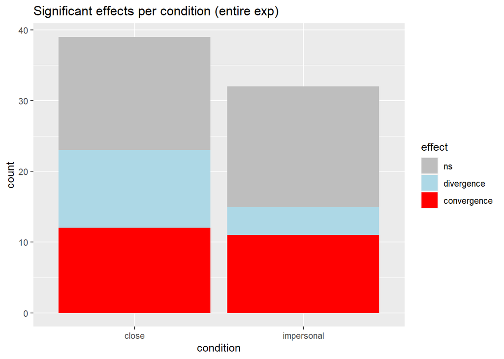

```r
ggplot(all |> filter(section=="entireExp"), aes(condition, fill=effect))+
  geom_bar()+
  ggtitle("Significant effects per condition (entire exp)")+
  scale_fill_manual(values = c("divergence" = "lightblue", "convergence" = "red", "ns" = "gray"))
```

```r
summary(glmer(sign ~ condition + (1|dyad), all |> filter(section=="entireExp"), family=binomial))
```

```
## boundary (singular) fit: see help('isSingular')
```

```
## Generalized linear mixed model fit by maximum likelihood (Laplace
##   Approximation) [glmerMod]
##  Family: binomial  ( logit )
## Formula: sign ~ condition + (1 | dyad)
##    Data: filter(all, section == "entireExp")
##
##      AIC      BIC   logLik deviance df.resid
##    103.0    109.8    -48.5     97.0       68
##
## Scaled residuals:
##     Min      1Q  Median      3Q     Max
## -1.1990 -0.9393  0.8341  0.8341  1.0646
##
## Random effects:
##  Groups Name        Variance Std.Dev.
##  dyad   (Intercept) 0        0
## Number of obs: 71, groups:  dyad, 19
##
## Fixed effects:
##                     Estimate Std. Error z value Pr(>|z|)
## (Intercept)           0.3629     0.3255   1.115    0.265
## conditionimpersonal  -0.4881     0.4811  -1.014    0.310
##
## Correlation of Fixed Effects:
##             (Intr)
## cndtnmprsnl -0.677
## optimizer (Nelder_Mead) convergence code: 0 (OK)
## boundary (singular) fit: see help('isSingular')
```

```r
tidy(m <- nnet::multinom(effect ~ condition, data= all |> filter(section=="entireExp"))) |>
  as_tibble() |>
  mutate(estimate = plogis(estimate)) # plogis transforms log odds (the output of the model) into probabilities
```

```
## # A tibble: 4 × 6
##   y.level     term                estimate std.error statistic p.value
##   <chr>       <chr>                  <dbl>     <dbl>     <dbl>   <dbl>
## 1 divergence  (Intercept)            0.407     0.392    -0.957   0.339
## 2 divergence  conditionimpersonal    0.255     0.680    -1.58    0.115
## 3 convergence (Intercept)            0.429     0.382    -0.753   0.451
## 4 convergence conditionimpersonal    0.463     0.544    -0.272   0.786
```

```r
emmeans(m, pairwise~condition, by="effect")
```

```
## $emmeans
## effect = ns:
##  condition   prob     SE df lower.CL upper.CL
##  close      0.410 0.0788  4   0.1916    0.629
##  impersonal 0.531 0.0882  4   0.2863    0.776
##
## effect = divergence:
##  condition   prob     SE df lower.CL upper.CL
##  close      0.282 0.0721  4   0.0820    0.482
##  impersonal 0.125 0.0585  4  -0.0373    0.287
##
## effect = convergence:
##  condition   prob     SE df lower.CL upper.CL
##  close      0.308 0.0739  4   0.1025    0.513
##  impersonal 0.344 0.0840  4   0.1106    0.577
##
## Confidence level used: 0.95
##
## $contrasts
## effect = ns:
##  contrast           estimate     SE df t.ratio p.value
##  close - impersonal  -0.1210 0.1183  4  -1.023  0.3641
##
## effect = divergence:
##  contrast           estimate     SE df t.ratio p.value
##  close - impersonal   0.1571 0.0928  4   1.693  0.1658
##
## effect = convergence:
##  contrast           estimate     SE df t.ratio p.value
##  close - impersonal  -0.0361 0.1119  4  -0.322  0.7633
```

#### Nose

No difference in nose convergence between conditions.

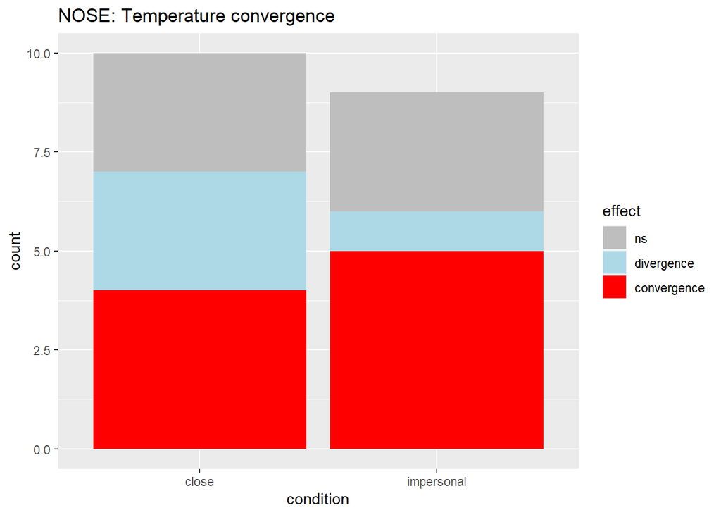

```r
ggplot(all |> filter(ROI=="Nose", section=="entireExp"), aes(condition, fill=effect))+
  geom_bar()+
  ggtitle("NOSE: Temperature convergence")+
  scale_fill_manual(values = c("divergence" = "lightblue", "convergence" = "red", "ns" = "gray"))
```

```r
tidy(m <- nnet::multinom(effect ~ condition, data= all |> filter(section=="entireExp", ROI=="Nose"))) |>
  as_tibble() |>
  mutate(estimate = plogis(estimate)) # plogis transforms log odds (the output of the model) into probabilities
```

```
## # A tibble: 4 × 6
##   y.level     term                estimate std.error   statistic p.value
##   <chr>       <chr>                  <dbl>     <dbl>       <dbl>   <dbl>
## 1 divergence  (Intercept)            0.500     0.816  0.00000223   1.00
## 2 divergence  conditionimpersonal    0.250     1.41  -0.777        0.437
## 3 convergence (Intercept)            0.571     0.764  0.377        0.706
## 4 convergence conditionimpersonal    0.556     1.06   0.211        0.833
```

```r
emmeans(m, pairwise~condition, by="effect")
```

```
## $emmeans
## effect = ns:
##  condition   prob    SE df lower.CL upper.CL
##  close      0.300 0.145  4  -0.1023    0.702
##  impersonal 0.333 0.157  4  -0.1029    0.770
##
## effect = divergence:
##  condition   prob    SE df lower.CL upper.CL
##  close      0.300 0.145  4  -0.1023    0.702
##  impersonal 0.111 0.105  4  -0.1797    0.402
##
## effect = convergence:
##  condition   prob    SE df lower.CL upper.CL
##  close      0.400 0.155  4  -0.0301    0.830
##  impersonal 0.556 0.166  4   0.0957    1.015
##
## Confidence level used: 0.95
##
## $contrasts
## effect = ns:
##  contrast           estimate    SE df t.ratio p.value
##  close - impersonal  -0.0333 0.214  4  -0.156  0.8836
##
## effect = divergence:
##  contrast           estimate    SE df t.ratio p.value
##  close - impersonal   0.1889 0.179  4   1.056  0.3504
##
## effect = convergence:
##  contrast           estimate    SE df t.ratio p.value
##  close - impersonal  -0.1556 0.227  4  -0.686  0.5305
```

#### Forehead

No difference in forehead convergence between conditions.

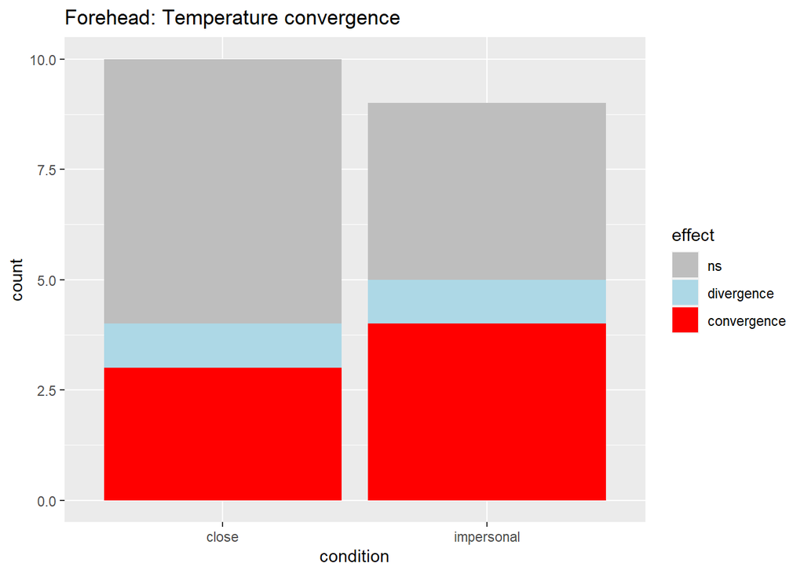

```r
ggplot(all |> filter(ROI=="Forehead", section=="entireExp"), aes(condition, fill=effect))+
  geom_bar()+
  ggtitle("Forehead: Temperature convergence")+
  scale_fill_manual(values = c("divergence" = "lightblue", "convergence" = "red", "ns" = "gray"))
```

```r
tidy(m <- nnet::multinom(effect ~ condition, data= all |> filter(section=="entireExp", ROI=="Forehead"))) |>
  as_tibble() |>
  mutate(estimate = plogis(estimate)) # plogis transforms log odds (the output of the model) into probabilities
```

```
## # A tibble: 4 × 6
##   y.level     term                estimate std.error statistic p.value
##   <chr>       <chr>                  <dbl>     <dbl>     <dbl>   <dbl>
## 1 divergence  (Intercept)            0.143     1.08     -1.66   0.0971
## 2 divergence  conditionimpersonal    0.600     1.55      0.261  0.794
## 3 convergence (Intercept)            0.333     0.707    -0.980  0.327
## 4 convergence conditionimpersonal    0.667     1.00      0.693  0.488
```

```r
emmeans(m, pairwise~condition, by="effect")
```

```
## $emmeans
## effect = ns:
##  condition   prob     SE df lower.CL upper.CL
##  close      0.600 0.1549  4   0.1699    1.030
##  impersonal 0.444 0.1656  4  -0.0154    0.904
##
## effect = divergence:
##  condition   prob     SE df lower.CL upper.CL
##  close      0.100 0.0949  4  -0.1634    0.363
##  impersonal 0.111 0.1048  4  -0.1797    0.402
##
## effect = convergence:
##  condition   prob     SE df lower.CL upper.CL
##  close      0.300 0.1449  4  -0.1023    0.702
##  impersonal 0.444 0.1656  4  -0.0154    0.904
##
## Confidence level used: 0.95
##
## $contrasts
## effect = ns:
##  contrast           estimate    SE df t.ratio p.value
##  close - impersonal   0.1556 0.227  4   0.686  0.5305
##
## effect = divergence:
##  contrast           estimate    SE df t.ratio p.value
##  close - impersonal  -0.0111 0.141  4  -0.079  0.9411
##
## effect = convergence:
##  contrast           estimate    SE df t.ratio p.value
##  close - impersonal  -0.1444 0.220  4  -0.656  0.5475
```

#### Eyes

No difference in eye convergence between conditions.

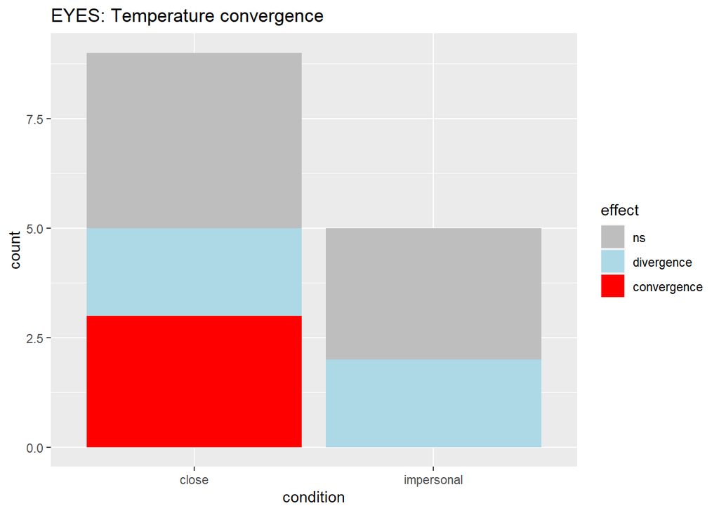

```r
ggplot(all |> filter(ROI=="Eyes", section=="entireExp"), aes(condition, fill=effect))+
  geom_bar()+
  ggtitle("EYES: Temperature convergence")+
  scale_fill_manual(values = c("divergence" = "lightblue", "convergence" = "red", "ns" = "gray"))
```

```r
tidy(m <- nnet::multinom(effect ~ condition, data= all |> filter(section=="entireExp", ROI=="Eyes"))) |>
  as_tibble() |>
  mutate(estimate = plogis(estimate)) # plogis transforms log odds (the output of the model) into probabilities
```

```
## # A tibble: 4 × 6
##   y.level     term                 estimate std.error statistic p.value
##   <chr>       <chr>                   <dbl>     <dbl>     <dbl>   <dbl>
## 1 divergence  (Intercept)         0.333         0.866    -0.801   0.423
## 2 divergence  conditionimpersonal 0.571         1.26      0.229   0.819
## 3 convergence (Intercept)         0.429         0.764    -0.377   0.706
## 4 convergence conditionimpersonal 0.0000968    67.8      -0.136   0.891
```

```r
emmeans(m, pairwise~condition, by="effect")
```

```
## $emmeans
## effect = ns:
##  condition      prob      SE df lower.CL upper.CL
##  close      4.44e-01 0.16564  4 -0.01540  0.90436
##  impersonal 6.00e-01 0.21909  4 -0.00827  1.20830
##
## effect = divergence:
##  condition      prob      SE df lower.CL upper.CL
##  close      2.22e-01 0.13858  4 -0.16254  0.60697
##  impersonal 4.00e-01 0.21908  4 -0.20833  1.00822
##
## effect = convergence:
##  condition      prob      SE df lower.CL upper.CL
##  close      3.33e-01 0.15713  4 -0.10296  0.76957
##  impersonal 4.36e-05 0.00295  4 -0.00815  0.00824
##
## Confidence level used: 0.95
##
## $contrasts
## effect = ns:
##  contrast           estimate    SE df t.ratio p.value
##  close - impersonal   -0.156 0.275  4  -0.566  0.6015
##
## effect = divergence:
##  contrast           estimate    SE df t.ratio p.value
##  close - impersonal   -0.178 0.259  4  -0.686  0.5306
##
## effect = convergence:
##  contrast           estimate    SE df t.ratio p.value
##  close - impersonal    0.333 0.157  4   2.121  0.1013
```

#### Cheeks

More cheek divergence (or rather: cheek divergence *only*) in the *close* condition.

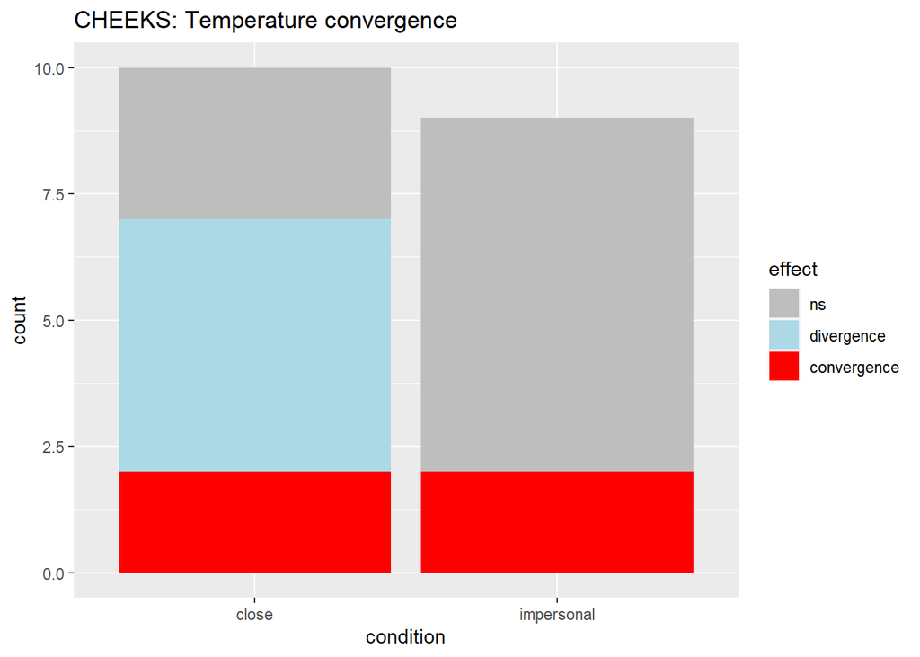

```r
ggplot(all |> filter(ROI=="Cheeks", section=="entireExp"), aes(condition, fill=effect))+
  geom_bar()+
  ggtitle("CHEEKS: Temperature convergence")+
  scale_fill_manual(values = c("divergence" = "lightblue", "convergence" = "red", "ns" = "gray"))
```

```r
tidy(m <- nnet::multinom(effect ~ condition, data= all |> filter(section=="entireExp", ROI=="Cheeks"))) |>
  as_tibble() |>
  mutate(estimate = plogis(estimate)) # plogis transforms log odds (the output of the model) into probabilities
```

```
## # A tibble: 4 × 6
##   y.level     term                 estimate std.error statistic p.value
##   <chr>       <chr>                   <dbl>     <dbl>     <dbl>   <dbl>
## 1 divergence  (Intercept)         0.625         0.730     0.699   0.484
## 2 divergence  conditionimpersonal 0.0000266    56.7      -0.186   0.853
## 3 convergence (Intercept)         0.400         0.913    -0.444   0.657
## 4 convergence conditionimpersonal 0.300         1.21     -0.697   0.486
```

```r
emmeans(m, pairwise~condition, by="effect")
```

```
## $emmeans
## effect = ns:
##  condition      prob      SE df lower.CL upper.CL
##  close      3.00e-01 0.14492  4  -0.1023  0.70240
##  impersonal 7.78e-01 0.13858  4   0.3930  1.16253
##
## effect = divergence:
##  condition      prob      SE df lower.CL upper.CL
##  close      5.00e-01 0.15811  4   0.0610  0.93896
##  impersonal 3.45e-05 0.00196  4  -0.0054  0.00547
##
## effect = convergence:
##  condition      prob      SE df lower.CL upper.CL
##  close      2.00e-01 0.12649  4  -0.1512  0.55119
##  impersonal 2.22e-01 0.13858  4  -0.1625  0.60696
##
## Confidence level used: 0.95
##
## $contrasts
## effect = ns:
##  contrast           estimate    SE df t.ratio p.value
##  close - impersonal  -0.4777 0.201  4  -2.382  0.0758
##
## effect = divergence:
##  contrast           estimate    SE df t.ratio p.value
##  close - impersonal   0.4999 0.158  4   3.162  0.0341
##
## effect = convergence:
##  contrast           estimate    SE df t.ratio p.value
##  close - impersonal  -0.0222 0.188  4  -0.118  0.9115
```

## All speakers together

**There was no robust convergence or divergence in any ROI when all speakers’ data are pulled together.** Although there seemed to be a trend in some ROIs, the effect disappears completely when we add random slopes to the models.

### Nose

No con-/divergence in nose temperature.

Preferred model: `tempDiff ~ time + (1+time|dyad)`

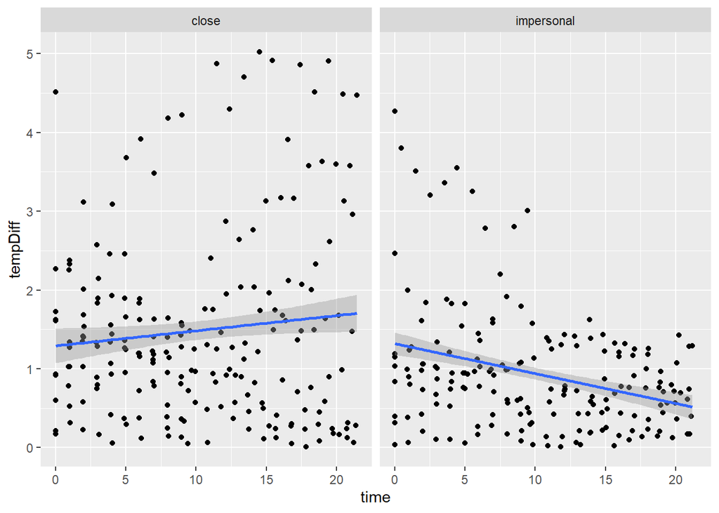

```r
ggplot(dat |> filter(ROI=="Nose"), aes(time, tempDiff))+
  geom_point()+
  geom_smooth(method="lm")+
  facet_wrap(~condition)
```

```r
summary(m0 <- lmer(tempDiff ~ time + (1+time|dyad), dat |> filter(ROI=="Nose", grepl("-A", speaker))))
```

```
## Linear mixed model fit by REML. t-tests use Satterthwaite's method [
## lmerModLmerTest]
## Formula: tempDiff ~ time + (1 + time | dyad)
##    Data: filter(dat, ROI == "Nose", grepl("-A", speaker))
##
## REML criterion at convergence: 460.9
##
## Scaled residuals:
##     Min      1Q  Median      3Q     Max
## -3.2389 -0.4691  0.0113  0.5608  4.0403
##
## Random effects:
##  Groups   Name        Variance Std.Dev. Corr
##  dyad     (Intercept) 1.0340   1.0168
##           time        0.0102   0.1010   -0.65
##  Residual             0.1245   0.3528
## Number of obs: 386, groups:  dyad, 19
##
## Fixed effects:
##             Estimate Std. Error       df t value Pr(>|t|)
## (Intercept)  1.36550    0.23586 17.74039   5.790 1.84e-05 ***
## time        -0.01884    0.02344 16.70063  -0.804    0.433
## ---
## Signif. codes:  0 '***' 0.001 '**' 0.01 '*' 0.05 '.' 0.1 ' ' 1
##
## Correlation of Fixed Effects:
##      (Intr)
## time -0.651
```

```r
summary(m1 <- lmer(tempDiff ~ time : condition + (1+time|dyad), dat |> filter(ROI=="Nose", grepl("-A", speaker))))
```

```
## Linear mixed model fit by REML. t-tests use Satterthwaite's method [
## lmerModLmerTest]
## Formula: tempDiff ~ time:condition + (1 + time | dyad)
##    Data: filter(dat, ROI == "Nose", grepl("-A", speaker))
##
## REML criterion at convergence: 465
##
## Scaled residuals:
##     Min      1Q  Median      3Q     Max
## -3.2405 -0.4758  0.0161  0.5653  4.0392
##
## Random effects:
##  Groups   Name        Variance Std.Dev. Corr
##  dyad     (Intercept) 1.03524  1.0175
##           time        0.01044  0.1022   -0.65
##  Residual             0.12451  0.3529
## Number of obs: 386, groups:  dyad, 19
##
## Fixed effects:
##                           Estimate Std. Error        df t value Pr(>|t|)
## (Intercept)               1.365733   0.236000 17.741434   5.787 1.85e-05 ***
## time:conditionclose      -0.004282   0.029145 20.101732  -0.147    0.885
## time:conditionimpersonal -0.035147   0.030310 20.468096  -1.160    0.260
## ---
## Signif. codes:  0 '***' 0.001 '**' 0.01 '*' 0.05 '.' 0.1 ' ' 1
##
## Correlation of Fixed Effects:
##             (Intr) tm:cndtnc
## tm:cndtncls -0.533
## tm:cndtnmpr -0.513  0.273
```

```r
anova(m0, m1)
```

```
## refitting model(s) with ML (instead of REML)
```

```
## Data: filter(dat, ROI == "Nose", grepl("-A", speaker))
## Models:
## m0: tempDiff ~ time + (1 + time | dyad)
## m1: tempDiff ~ time:condition + (1 + time | dyad)
##    npar    AIC    BIC  logLik deviance  Chisq Df Pr(>Chisq)
## m0    6 465.60 489.33 -226.80   453.60
## m1    7 466.78 494.47 -226.39   452.78 0.8141  1     0.3669
```

### Forehead

No con-/divergence in forehead temperature.

Preferred model: `tempDiff ~ time + (1+time|dyad)`

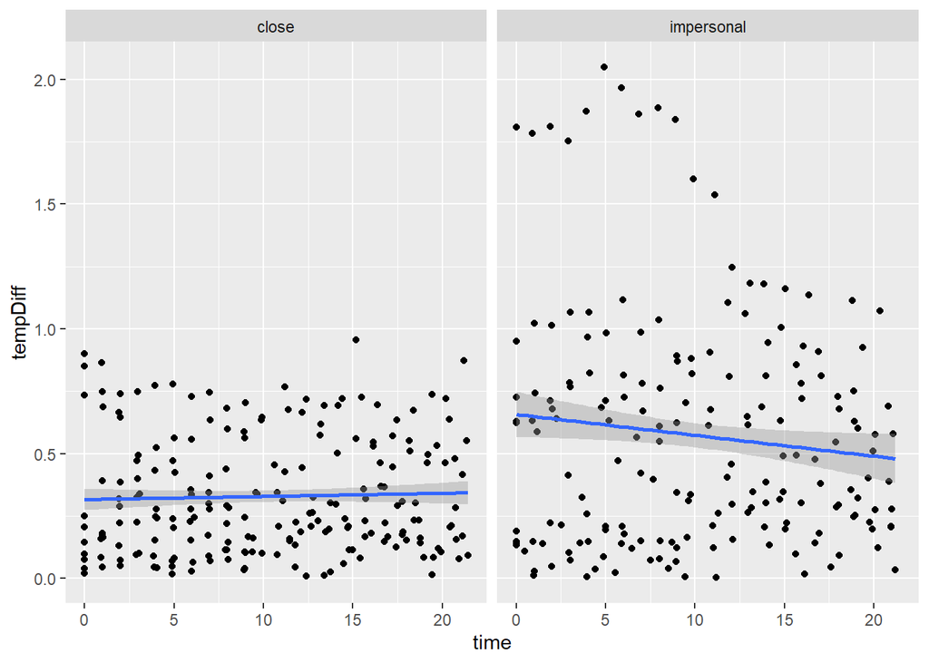

```r
ggplot(dat |> filter(ROI=="Forehead"), aes(time, tempDiff))+
  geom_point()+
  geom_smooth(method="lm")+
  facet_wrap(~condition)
```

```r
summary(m0 <- lmer(tempDiff ~ time + (1+time|dyad), dat |> filter(ROI=="Forehead", grepl("-A", speaker))))
```

```
## Linear mixed model fit by REML. t-tests use Satterthwaite's method [
## lmerModLmerTest]
## Formula: tempDiff ~ time + (1 + time | dyad)
##    Data: filter(dat, ROI == "Forehead", grepl("-A", speaker))
##
## REML criterion at convergence: -369.8
##
## Scaled residuals:
##     Min      1Q  Median      3Q     Max
## -2.7946 -0.5939 -0.0462  0.4854  3.5608
##
## Random effects:
##  Groups   Name        Variance  Std.Dev. Corr
##  dyad     (Intercept) 0.2468194 0.49681
##           time        0.0003929 0.01982  -0.83
##  Residual             0.0148757 0.12197
## Number of obs: 384, groups:  dyad, 19
##
## Fixed effects:
##              Estimate Std. Error        df t value Pr(>|t|)
## (Intercept)  0.474478   0.114600 18.040839   4.140 0.000612 ***
## time        -0.004985   0.004690 18.475602  -1.063 0.301565
## ---
## Signif. codes:  0 '***' 0.001 '**' 0.01 '*' 0.05 '.' 0.1 ' ' 1
##
## Correlation of Fixed Effects:
##      (Intr)
## time -0.820
## optimizer (nloptwrap) convergence code: 0 (OK)
## Model failed to converge with max|grad| = 0.00525201 (tol = 0.002, component 1)
```

```r
summary(m1 <- lmer(tempDiff ~ time : condition + (1+time|dyad), dat |> filter(ROI=="Forehead", grepl("-A", speaker))))
```

```
## Linear mixed model fit by REML. t-tests use Satterthwaite's method [
## lmerModLmerTest]
## Formula: tempDiff ~ time:condition + (1 + time | dyad)
##    Data: filter(dat, ROI == "Forehead", grepl("-A", speaker))
##
## REML criterion at convergence: -361.2
##
## Scaled residuals:
##     Min      1Q  Median      3Q     Max
## -2.7967 -0.5938 -0.0442  0.4856  3.5562
##
## Random effects:
##  Groups   Name        Variance  Std.Dev. Corr
##  dyad     (Intercept) 0.2467724 0.49676
##           time        0.0004006 0.02001  -0.82
##  Residual             0.0148759 0.12197
## Number of obs: 384, groups:  dyad, 19
##
## Fixed effects:
##                           Estimate Std. Error        df t value Pr(>|t|)
## (Intercept)               0.474549   0.114590 18.039774   4.141 0.000611 ***
## time:conditionclose      -0.005006   0.005406 22.786594  -0.926 0.364137
## time:conditionimpersonal -0.005002   0.005568 23.797371  -0.898 0.377989
## ---
## Signif. codes:  0 '***' 0.001 '**' 0.01 '*' 0.05 '.' 0.1 ' ' 1
##
## Correlation of Fixed Effects:
##             (Intr) tm:cndtnc
## tm:cndtncls -0.710
## tm:cndtnmpr -0.690  0.490
```

```r
anova(m0, m1)
```

```
## refitting model(s) with ML (instead of REML)
```

```
## Data: filter(dat, ROI == "Forehead", grepl("-A", speaker))
## Models:
## m0: tempDiff ~ time + (1 + time | dyad)
## m1: tempDiff ~ time:condition + (1 + time | dyad)
##    npar    AIC     BIC logLik deviance Chisq Df Pr(>Chisq)
## m0    6 -370.3 -346.60 191.15   -382.3
## m1    7 -368.3 -340.65 191.15   -382.3 2e-04  1     0.9875
```

### Eyes

No con-/divergence in eye temperature.

Preferred model: `tempDiff ~ time + (1+time|dyad)`

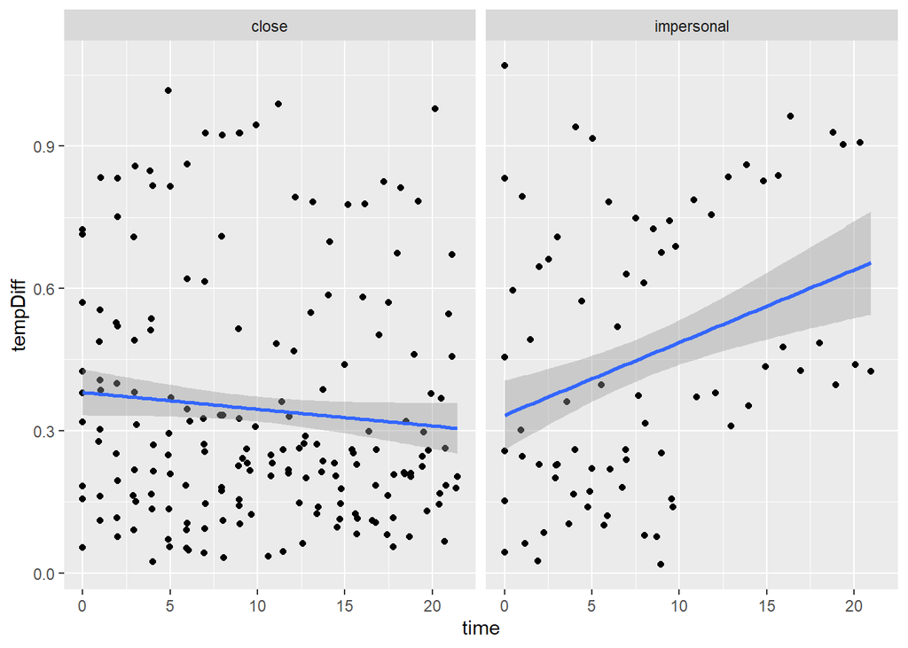

```r
ggplot(dat |> filter(ROI=="Eyes"), aes(time, tempDiff))+
  geom_point()+
  geom_smooth(method="lm")+
  facet_wrap(~condition)
```

```r
summary(m0 <- lmer(tempDiff ~ time + (1+time|dyad), dat |> filter(ROI=="Eyes", grepl("-A", speaker))))
```

```
## Linear mixed model fit by REML. t-tests use Satterthwaite's method [
## lmerModLmerTest]
## Formula: tempDiff ~ time + (1 + time | dyad)
##    Data: filter(dat, ROI == "Eyes", grepl("-A", speaker))
##
## REML criterion at convergence: -368.7
##
## Scaled residuals:
##     Min      1Q  Median      3Q     Max
## -2.9016 -0.5138 -0.0237  0.5868  3.2696
##
## Random effects:
##  Groups   Name        Variance  Std.Dev. Corr
##  dyad     (Intercept) 0.0873251 0.29551
##           time        0.0001424 0.01193  -0.08
##  Residual             0.0088654 0.09416
## Number of obs: 257, groups:  dyad, 15
##
## Fixed effects:
##              Estimate Std. Error        df t value Pr(>|t|)
## (Intercept)  0.400405   0.077268 13.482924   5.182 0.000157 ***
## time         0.003296   0.003466 11.738868   0.951 0.360921
## ---
## Signif. codes:  0 '***' 0.001 '**' 0.01 '*' 0.05 '.' 0.1 ' ' 1
##
## Correlation of Fixed Effects:
##      (Intr)
## time -0.111
```

```r
summary(m1 <- lmer(tempDiff ~ time : condition + (1+time|dyad), dat |> filter(ROI=="Eyes", grepl("-A", speaker))))
```

```
## Linear mixed model fit by REML. t-tests use Satterthwaite's method [
## lmerModLmerTest]
## Formula: tempDiff ~ time:condition + (1 + time | dyad)
##    Data: filter(dat, ROI == "Eyes", grepl("-A", speaker))
##
## REML criterion at convergence: -361.8
##
## Scaled residuals:
##     Min      1Q  Median      3Q     Max
## -2.9470 -0.5208 -0.0259  0.5973  3.2807
##
## Random effects:
##  Groups   Name        Variance  Std.Dev. Corr
##  dyad     (Intercept) 0.0880018 0.29665
##           time        0.0001364 0.01168  -0.08
##  Residual             0.0088746 0.09421
## Number of obs: 257, groups:  dyad, 15
##
## Fixed effects:
##                           Estimate Std. Error        df t value Pr(>|t|)
## (Intercept)              3.993e-01  7.757e-02 1.348e+01   5.147 0.000167 ***
## time:conditionclose      8.415e-04  4.100e-03 9.321e+00   0.205 0.841811
## time:conditionimpersonal 8.594e-03  6.042e-03 1.275e+01   1.422 0.178927
## ---
## Signif. codes:  0 '***' 0.001 '**' 0.01 '*' 0.05 '.' 0.1 ' ' 1
##
## Correlation of Fixed Effects:
##             (Intr) tm:cndtnc
## tm:cndtncls -0.083
## tm:cndtnmpr -0.075  0.006
```

```r
anova(m0, m1)
```

```
## refitting model(s) with ML (instead of REML)
```

```
## Data: filter(dat, ROI == "Eyes", grepl("-A", speaker))
## Models:
## m0: tempDiff ~ time + (1 + time | dyad)
## m1: tempDiff ~ time:condition + (1 + time | dyad)
##    npar     AIC     BIC logLik deviance  Chisq Df Pr(>Chisq)
## m0    6 -369.58 -348.28 190.79  -381.58
## m1    7 -368.87 -344.03 191.43  -382.87 1.2898  1     0.2561
```

### Cheeks

No con-/divergence in cheek temperature.

Preferred model: `tempDiff ~ time + (1+time|dyad)`

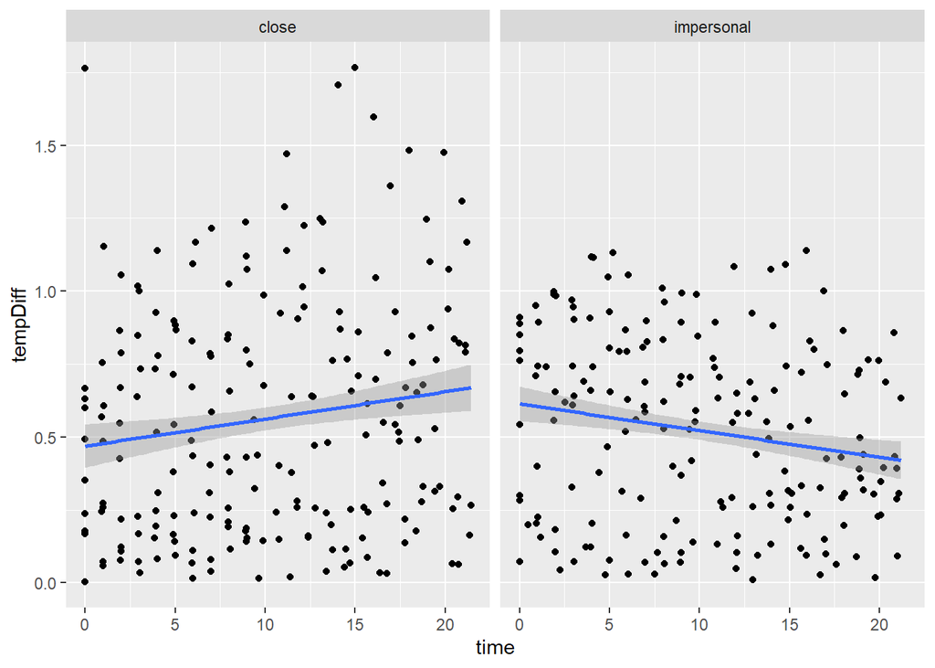

```r
ggplot(dat |> filter(ROI=="Cheeks"), aes(time, tempDiff))+
  geom_point()+
  geom_smooth(method="lm")+
  facet_wrap(~condition)
```

```r
summary(m0 <- lmer(tempDiff ~ time + (1+time|dyad), dat |> filter(ROI=="Cheeks", grepl("-A", speaker))))
```

```
## Linear mixed model fit by REML. t-tests use Satterthwaite's method [
## lmerModLmerTest]
## Formula: tempDiff ~ time + (1 + time | dyad)
##    Data: filter(dat, ROI == "Cheeks", grepl("-A", speaker))
##
## REML criterion at convergence: -143
##
## Scaled residuals:
##      Min       1Q   Median       3Q      Max
## -2.81095 -0.59407 -0.03153  0.59510  3.15345
##
## Random effects:
##  Groups   Name        Variance  Std.Dev. Corr
##  dyad     (Intercept) 0.1236840 0.35169
##           time        0.0005792 0.02407  -0.51
##  Residual             0.0280919 0.16761
## Number of obs: 388, groups:  dyad, 19
##
## Fixed effects:
##              Estimate Std. Error        df t value Pr(>|t|)
## (Intercept)  0.531954   0.082334 18.072521   6.461 4.36e-06 ***
## time         0.002284   0.005755 16.264945   0.397    0.697
## ---
## Signif. codes:  0 '***' 0.001 '**' 0.01 '*' 0.05 '.' 0.1 ' ' 1
##
## Correlation of Fixed Effects:
##      (Intr)
## time -0.529
```

```r
summary(m1 <- lmer(tempDiff ~ time : condition + (1+time|dyad), dat |> filter(ROI=="Cheeks", grepl("-A", speaker))))
```

```
## Linear mixed model fit by REML. t-tests use Satterthwaite's method [
## lmerModLmerTest]
## Formula: tempDiff ~ time:condition + (1 + time | dyad)
##    Data: filter(dat, ROI == "Cheeks", grepl("-A", speaker))
##
## REML criterion at convergence: -138.9
##
## Scaled residuals:
##     Min      1Q  Median      3Q     Max
## -2.8215 -0.5858 -0.0303  0.5957  3.1854
##
## Random effects:
##  Groups   Name        Variance  Std.Dev. Corr
##  dyad     (Intercept) 0.1237435 0.35177
##           time        0.0004782 0.02187  -0.47
##  Residual             0.0280774 0.16756
## Number of obs: 388, groups:  dyad, 19
##
## Fixed effects:
##                           Estimate Std. Error        df t value Pr(>|t|)
## (Intercept)               0.532396   0.082348 18.066713   6.465 4.33e-06 ***
## time:conditionclose       0.010528   0.006825 17.310815   1.543    0.141
## time:conditionimpersonal -0.007143   0.007160 17.464889  -0.998    0.332
## ---
## Signif. codes:  0 '***' 0.001 '**' 0.01 '*' 0.05 '.' 0.1 ' ' 1
##
## Correlation of Fixed Effects:
##             (Intr) tm:cndtnc
## tm:cndtncls -0.380
## tm:cndtnmpr -0.362  0.138
```

```r
anova(m0, m1)
```

```
## refitting model(s) with ML (instead of REML)
```

```
## Data: filter(dat, ROI == "Cheeks", grepl("-A", speaker))
## Models:
## m0: tempDiff ~ time + (1 + time | dyad)
## m1: tempDiff ~ time:condition + (1 + time | dyad)
##    npar     AIC     BIC logLik deviance  Chisq Df Pr(>Chisq)
## m0    6 -143.01 -119.25 77.507  -155.01
## m1    7 -144.64 -116.91 79.320  -158.64 3.6277  1    0.05683 .
## ---
## Signif. codes:  0 '***' 0.001 '**' 0.01 '*' 0.05 '.' 0.1 ' ' 1
```